# Alzheimers Behaviorial Phenotypes

2024-07-02

**First we need some R libraries:**

```r
#remotes::install_github("https://github.com/monarch-initiative/monarchr", ref = "engines")

suppressMessages({
    library(monarchr)
    library(ggraph)
    library(stringr) # for str_wrap
    library(tidygraph) # activate() etc.
})
```

Let’s start by looking for Alzheimer’s. We’ll use the search here in R to see what we can see:

```r
monarch_engine() |>
    search_nodes("Alzheimer")
```

#### Nodes

Showing 10 of 10 nodes:

| id | pcategory | name | description | synonym (list) | category (list) | iri | xref (list) | provided_by (list) |
| --- | --- | --- | --- | --- | --- | --- | --- | --- |
| “MONDO:0011743” | “biolink:Disease” | “Alzheimer disease 4” | “Alzheimer’s disease with an early onset (starts before the age of 65). It is caused by mutations in the PSEN2 gene.” | c(“AD4”, “Ad4”, “Alzheimer disease 4”, “Alzheimer disease familial type 4”, “Alzheimer disease type 4”, “Alzheimer disease, familial, 4”, “Alzheimer disease, familial4”, “Alzheimer disease-4”, “Alzhei… | c(“biolink:BiologicalEntity”, “biolink:Disease”, “biolink:DiseaseOrPhenotypicFeature”, “biolink:Entity”, “biolink:NamedThing”, “biolink:ThingWithTaxon”) | “http://purl.obolibrary.org/obo/MONDO_0011743” | c(“DOID:0110040”, “GARD:16511”, “MESH:C536596”, “NCIT:C123413”, “OMIM:606889”, “UMLS:C1847200”) | “phenio_nodes” |
| “MONDO:0007089” | “biolink:Disease” | “Alzheimer disease 2” | “An Alzheimer’s disease that is characterized by an association of the apolipoprotein E E4 allele.” | c(“AD2”, “Alzheimer disease 2”, “Alzheimer disease 2, late onset”, “Alzheimer disease 2, late-onset”, “Alzheimer disease associated with APOE E4”, “Alzheimer disease associated with APOE4”, “Alzheimer… | c(“biolink:BiologicalEntity”, “biolink:Disease”, “biolink:DiseaseOrPhenotypicFeature”, “biolink:Entity”, “biolink:NamedThing”, “biolink:ThingWithTaxon”) | “http://purl.obolibrary.org/obo/MONDO_0007089” | c(“DOID:0110035”, “GARD:12799”, “MESH:C536595”, “OMIM:104310”, “UMLS:C1863051”) | “phenio_nodes” |
| “MONDO:0014265” | “biolink:Disease” | “Alzheimer disease 18” | “Any Alzheimer disease in which the cause of the disease is a mutation in the ADAM10 gene.” | c(“AD18”, “ADAM10 Alzheimer disease”, “Alzheimer disease 18”, “Alzheimer disease 18, late-onset”, “Alzheimer disease 18, susceptibility to”, “Alzheimer disease caused by mutation in ADAM10”, “Alzheime… | c(“biolink:BiologicalEntity”, “biolink:Disease”, “biolink:DiseaseOrPhenotypicFeature”, “biolink:Entity”, “biolink:NamedThing”, “biolink:ThingWithTaxon”) | “http://purl.obolibrary.org/obo/MONDO_0014265” | c(“DOID:0110050”, “OMIM:615590”, “UMLS:C3810041”) | “phenio_nodes” |
| “MONDO:0011913” | “biolink:Disease” | “Alzheimer disease 3” | “Alzheimer’s disease with an early onset (starts before the age of 65). It is caused by mutations in the PSEN1 gene.” | c(“AD”, “AD3”, “Alzheimer disease 3”, “Alzheimer disease 3, early onset”, “Alzheimer disease 3, early-onset”, “Alzheimer disease early onset type 3”, “Alzheimer disease familial 3”, “Alzheimer disease… | c(“biolink:BiologicalEntity”, “biolink:Disease”, “biolink:DiseaseOrPhenotypicFeature”, “biolink:Entity”, “biolink:NamedThing”, “biolink:ThingWithTaxon”) | “http://purl.obolibrary.org/obo/MONDO_0011913” | c(“DOID:0110042”, “GARD:16513”, “MESH:C536598”, “NCIT:C123412”, “OMIM:607822”) | “phenio_nodes” |
| “MONDO:0004975” | “biolink:Disease” | “Alzheimer disease” | “A progressive, neurodegenerative disease characterized by loss of function and death of nerve cells in several areas of the brain leading to loss of cognitive function such as memory and language.” | c(“AD”, “Alzheimer dementia”, “Alzheimer disease”, “Alzheimer disease, familial”, “Alzheimer’s dementia”, “Alzheimer’s disease”, “Alzheimers dementia”, “Alzheimers disease”, “presenile and senile deme… | c(“biolink:BiologicalEntity”, “biolink:Disease”, “biolink:DiseaseOrPhenotypicFeature”, “biolink:Entity”, “biolink:NamedThing”, “biolink:ThingWithTaxon”) | “http://purl.obolibrary.org/obo/MONDO_0004975” | c(“DOID:10652”, “HP:0002511”, “ICD10CM:G30”, “ICD9:290.1”, “ICD9:331.0”, “MESH:D000544”, “NCIT:C2866”, “NIFSTD:birnlex_2092”, “Orphanet:238616”, “SCTID:142811000119104”, “UMLS:C0002395”) | “phenio_nodes” |
| “MONDO:0010422” | “biolink:Disease” | “Alzheimer disease 16” | “An Alzheimer’s disease that is characterized by an associated with a risk allele in in the PCDH11X gene on chromosome Xq21.3.” | c(“AD16”, “Alzheimer disease 16”, “Alzheimer’s disease 16”, “Alzheimer’s disease type 16”) | c(“biolink:BiologicalEntity”, “biolink:Disease”, “biolink:DiseaseOrPhenotypicFeature”, “biolink:Entity”, “biolink:NamedThing”, “biolink:ThingWithTaxon”) | “http://purl.obolibrary.org/obo/MONDO_0010422” | c(“DOID:0110036”, “MESH:C567463”, “OMIM:300756”, “UMLS:C2677888”) | “phenio_nodes” |
| “MONDO:0011194” | “biolink:Disease” | “Alzheimer disease 5” | NA | c(“AD5”, “Ad5”, “Alzheimer disease 5”, “Alzheimer disease type 5”, “Alzheimer disease, familial 5”, “Alzheimer disease, familial, 5”, “Alzheimer disease-5”, “Alzheimer’s disease 5”, “Alzheimer’s disea… | c(“biolink:BiologicalEntity”, “biolink:Disease”, “biolink:DiseaseOrPhenotypicFeature”, “biolink:Entity”, “biolink:NamedThing”, “biolink:ThingWithTaxon”) | “http://purl.obolibrary.org/obo/MONDO_0011194” | c(“DOID:0110037”, “GARD:16507”, “MESH:C566578”, “OMIM:602096”, “UMLS:C1865868”) | “phenio_nodes” |
| “MONDO:0011561” | “biolink:Disease” | “Alzheimer disease 6” | “An Alzheimer’s disease that is characterized by an associated with variation in the region 10q24.” | c(“AD6”, “Alzheimer disease 6”, “Alzheimer disease 6, late onset”, “Alzheimer disease 6, late-onset”, “Alzheimer disease type 6”, “Alzheimer’s disease 6”, “Alzheimer’s disease type 6”, “plasma Beta-am… | c(“biolink:BiologicalEntity”, “biolink:Disease”, “biolink:DiseaseOrPhenotypicFeature”, “biolink:Entity”, “biolink:NamedThing”, “biolink:ThingWithTaxon”) | “http://purl.obolibrary.org/obo/MONDO_0011561” | c(“DOID:0110038”, “GARD:16509”, “MESH:C565325”, “OMIM:605526”) | “phenio_nodes” |
| “MONDO:0011777” | “biolink:Disease” | “Alzheimer disease 8” | “An Alzheimer’s disease that is characterized by an associated with variation in the region 20p12.2-q11.21.” | c(“AD8”, “Ad8”, “Alzheimer disease 8”, “Alzheimer disease type 8”, “Alzheimer disease, familial 8”, “Alzheimer disease, familial, 8”, “Alzheimer’s disease 8”, “Alzheimer’s disease type 8”) | c(“biolink:BiologicalEntity”, “biolink:Disease”, “biolink:DiseaseOrPhenotypicFeature”, “biolink:Entity”, “biolink:NamedThing”, “biolink:ThingWithTaxon”) | “http://purl.obolibrary.org/obo/MONDO_0011777” | c(“DOID:0110041”, “GARD:16512”, “MESH:C564622”, “OMIM:607116”, “UMLS:C1846735”) | “phenio_nodes” |
| “MONDO:0012631” | “biolink:Disease” | “Alzheimer disease 14” | “An Alzheimer’s disease that is characterized by an associated with variation in the region 1q25.” | c(“AD14”, “Alzheimer disease 14”, “Alzheimer disease-14”, “Alzheimer’s disease 14”, “Alzheimer’s disease type 14”) | c(“biolink:BiologicalEntity”, “biolink:Disease”, “biolink:DiseaseOrPhenotypicFeature”, “biolink:Entity”, “biolink:NamedThing”, “biolink:ThingWithTaxon”) | “http://purl.obolibrary.org/obo/MONDO_0012631” | c(“DOID:0110047”, “GARD:16518”, “MESH:C566999”, “OMIM:611154”, “UMLS:C1970144”) | “phenio_nodes” |

#### Edges

Showing 0 of 0 edges:

There it is, `MONDO:0004975`. Let’s get it and all the descendants, and make a quick plot. We’ll investigate the phenotypes connected to these below.

```r
alz <- monarch_engine() |>
    fetch_nodes(query_ids = "MONDO:0004975") |> # Down
    expand(predicates = "biolink:subclass_of", direction = "in", transitive = TRUE)

alz
```

#### Nodes

Showing 22 of 22 nodes:

| id | pcategory | name | description | synonym (list) | category (list) | iri | xref (list) | provided_by (list) |
| --- | --- | --- | --- | --- | --- | --- | --- | --- |
| “MONDO:0004975” | “biolink:Disease” | “Alzheimer disease” | “A progressive, neurodegenerative disease characterized by loss of function and death of nerve cells in several areas of the brain leading to loss of cognitive function such as memory and language.” | c(“AD”, “Alzheimer dementia”, “Alzheimer disease”, “Alzheimer disease, familial”, “Alzheimer’s dementia”, “Alzheimer’s disease”, “Alzheimers dementia”, “Alzheimers disease”, “presenile and senile deme… | c(“biolink:BiologicalEntity”, “biolink:Disease”, “biolink:DiseaseOrPhenotypicFeature”, “biolink:Entity”, “biolink:NamedThing”, “biolink:ThingWithTaxon”) | “http://purl.obolibrary.org/obo/MONDO_0004975” | c(“DOID:10652”, “HP:0002511”, “ICD10CM:G30”, “ICD9:290.1”, “ICD9:331.0”, “MESH:D000544”, “NCIT:C2866”, “NIFSTD:birnlex_2092”, “Orphanet:238616”, “SCTID:142811000119104”, “UMLS:C0002395”) | “phenio_nodes” |
| “MONDO:0014265” | “biolink:Disease” | “Alzheimer disease 18” | “Any Alzheimer disease in which the cause of the disease is a mutation in the ADAM10 gene.” | c(“AD18”, “ADAM10 Alzheimer disease”, “Alzheimer disease 18”, “Alzheimer disease 18, late-onset”, “Alzheimer disease 18, susceptibility to”, “Alzheimer disease caused by mutation in ADAM10”, “Alzheime… | c(“biolink:BiologicalEntity”, “biolink:Disease”, “biolink:DiseaseOrPhenotypicFeature”, “biolink:Entity”, “biolink:NamedThing”, “biolink:ThingWithTaxon”) | “http://purl.obolibrary.org/obo/MONDO_0014265” | c(“DOID:0110050”, “OMIM:615590”, “UMLS:C3810041”) | “phenio_nodes” |
| “MONDO:0014036” | “biolink:Disease” | “Alzheimer disease 17” | “An Alzheimer’s disease that is characterized by an associated with mutations in the gene TREM2.” | c(“AD17”, “Alzheimer disease 17”, “Alzheimer disease 17, late onset”, “Alzheimer disease 17, late-onset”, “Alzheimer’s disease 17”, “Alzheimer’s disease type 17”) | c(“biolink:BiologicalEntity”, “biolink:Disease”, “biolink:DiseaseOrPhenotypicFeature”, “biolink:Entity”, “biolink:NamedThing”, “biolink:ThingWithTaxon”) | “http://purl.obolibrary.org/obo/MONDO_0014036” | c(“DOID:0110049”, “OMIM:615080”, “UMLS:C3554452”) | “phenio_nodes” |
| “MONDO:0010422” | “biolink:Disease” | “Alzheimer disease 16” | “An Alzheimer’s disease that is characterized by an associated with a risk allele in in the PCDH11X gene on chromosome Xq21.3.” | c(“AD16”, “Alzheimer disease 16”, “Alzheimer’s disease 16”, “Alzheimer’s disease type 16”) | c(“biolink:BiologicalEntity”, “biolink:Disease”, “biolink:DiseaseOrPhenotypicFeature”, “biolink:Entity”, “biolink:NamedThing”, “biolink:ThingWithTaxon”) | “http://purl.obolibrary.org/obo/MONDO_0010422” | c(“DOID:0110036”, “MESH:C567463”, “OMIM:300756”, “UMLS:C2677888”) | “phenio_nodes” |
| “MONDO:0100087” | “biolink:Disease” | “familial Alzheimer disease” | “A degenerative disease of the brain that causes gradual loss of memory, judgment, and the ability to function socially. About 25% of all Alzheimer disease is familial (more than 2 people in a family … | c(“Alzheimer disease, familial”, “FAD”, “GARD:0000632”) | c(“biolink:BiologicalEntity”, “biolink:Disease”, “biolink:DiseaseOrPhenotypicFeature”, “biolink:Entity”, “biolink:NamedThing”, “biolink:ThingWithTaxon”) | “http://purl.obolibrary.org/obo/MONDO_0100087” | NA | “phenio_nodes” |
| “MONDO:0007089” | “biolink:Disease” | “Alzheimer disease 2” | “An Alzheimer’s disease that is characterized by an association of the apolipoprotein E E4 allele.” | c(“AD2”, “Alzheimer disease 2”, “Alzheimer disease 2, late onset”, “Alzheimer disease 2, late-onset”, “Alzheimer disease associated with APOE E4”, “Alzheimer disease associated with APOE4”, “Alzheimer… | c(“biolink:BiologicalEntity”, “biolink:Disease”, “biolink:DiseaseOrPhenotypicFeature”, “biolink:Entity”, “biolink:NamedThing”, “biolink:ThingWithTaxon”) | “http://purl.obolibrary.org/obo/MONDO_0007089” | c(“DOID:0110035”, “GARD:12799”, “MESH:C536595”, “OMIM:104310”, “UMLS:C1863051”) | “phenio_nodes” |
| “MONDO:0015140” | “biolink:Disease” | “early-onset autosomal dominant Alzheimer disease” | “A progressive dementia with reduction of cognitive functions. It presents the same phenotype as sporadic Alzheimer disease (AD) but has an early age of onset, usually before 60 years old.” | c(“EOFAD”, “early-onset familial autosomal dominant Alzheimer disease”, “early-onset, autosomal dominant Alzheimer disease”) | c(“biolink:BiologicalEntity”, “biolink:Disease”, “biolink:DiseaseOrPhenotypicFeature”, “biolink:Entity”, “biolink:NamedThing”, “biolink:ThingWithTaxon”) | “http://purl.obolibrary.org/obo/MONDO_0015140” | c(“GARD:12798”, “Orphanet:1020”) | “phenio_nodes” |
| “MONDO:0011561” | “biolink:Disease” | “Alzheimer disease 6” | “An Alzheimer’s disease that is characterized by an associated with variation in the region 10q24.” | c(“AD6”, “Alzheimer disease 6”, “Alzheimer disease 6, late onset”, “Alzheimer disease 6, late-onset”, “Alzheimer disease type 6”, “Alzheimer’s disease 6”, “Alzheimer’s disease type 6”, “plasma Beta-am… | c(“biolink:BiologicalEntity”, “biolink:Disease”, “biolink:DiseaseOrPhenotypicFeature”, “biolink:Entity”, “biolink:NamedThing”, “biolink:ThingWithTaxon”) | “http://purl.obolibrary.org/obo/MONDO_0011561” | c(“DOID:0110038”, “GARD:16509”, “MESH:C565325”, “OMIM:605526”) | “phenio_nodes” |
| “MONDO:0012631” | “biolink:Disease” | “Alzheimer disease 14” | “An Alzheimer’s disease that is characterized by an associated with variation in the region 1q25.” | c(“AD14”, “Alzheimer disease 14”, “Alzheimer disease-14”, “Alzheimer’s disease 14”, “Alzheimer’s disease type 14”) | c(“biolink:BiologicalEntity”, “biolink:Disease”, “biolink:DiseaseOrPhenotypicFeature”, “biolink:Entity”, “biolink:NamedThing”, “biolink:ThingWithTaxon”) | “http://purl.obolibrary.org/obo/MONDO_0012631” | c(“DOID:0110047”, “GARD:16518”, “MESH:C566999”, “OMIM:611154”, “UMLS:C1970144”) | “phenio_nodes” |
| “MONDO:0011777” | “biolink:Disease” | “Alzheimer disease 8” | “An Alzheimer’s disease that is characterized by an associated with variation in the region 20p12.2-q11.21.” | c(“AD8”, “Ad8”, “Alzheimer disease 8”, “Alzheimer disease type 8”, “Alzheimer disease, familial 8”, “Alzheimer disease, familial, 8”, “Alzheimer’s disease 8”, “Alzheimer’s disease type 8”) | c(“biolink:BiologicalEntity”, “biolink:Disease”, “biolink:DiseaseOrPhenotypicFeature”, “biolink:Entity”, “biolink:NamedThing”, “biolink:ThingWithTaxon”) | “http://purl.obolibrary.org/obo/MONDO_0011777” | c(“DOID:0110041”, “GARD:16512”, “MESH:C564622”, “OMIM:607116”, “UMLS:C1846735”) | “phenio_nodes” |
| “MONDO:0011194” | “biolink:Disease” | “Alzheimer disease 5” | NA | c(“AD5”, “Ad5”, “Alzheimer disease 5”, “Alzheimer disease type 5”, “Alzheimer disease, familial 5”, “Alzheimer disease, familial, 5”, “Alzheimer disease-5”, “Alzheimer’s disease 5”, “Alzheimer’s disea… | c(“biolink:BiologicalEntity”, “biolink:Disease”, “biolink:DiseaseOrPhenotypicFeature”, “biolink:Entity”, “biolink:NamedThing”, “biolink:ThingWithTaxon”) | “http://purl.obolibrary.org/obo/MONDO_0011194” | c(“DOID:0110037”, “GARD:16507”, “MESH:C566578”, “OMIM:602096”, “UMLS:C1865868”) | “phenio_nodes” |
| “MONDO:0012630” | “biolink:Disease” | “Alzheimer disease 13” | “An Alzheimer’s disease that is characterized by an associated with variation in the region 1q21.” | c(“AD13”, “Alzheimer disease 13”, “Alzheimer disease-13”, “Alzheimer’s disease 13”, “Alzheimer’s disease type 13”) | c(“biolink:BiologicalEntity”, “biolink:Disease”, “biolink:DiseaseOrPhenotypicFeature”, “biolink:Entity”, “biolink:NamedThing”, “biolink:ThingWithTaxon”) | “http://purl.obolibrary.org/obo/MONDO_0012630” | c(“DOID:0110046”, “GARD:16517”, “MESH:C567000”, “OMIM:611152”, “UMLS:C1970147”) | “phenio_nodes” |
| “MONDO:0011401” | “biolink:Disease” | “Alzheimer disease without neurofibrillary tangles” | NA | c(“AD15”, “Alzheimer disease 15”, “Alzheimer disease without neurofibrillary tangles”, “Alzheimer disease-15”, “Alzheimer’s disease 15”, “Alzheimer’s disease type 15”, “Alzheimer’s disease without neu… | c(“biolink:BiologicalEntity”, “biolink:Disease”, “biolink:DiseaseOrPhenotypicFeature”, “biolink:Entity”, “biolink:NamedThing”, “biolink:ThingWithTaxon”) | “http://purl.obolibrary.org/obo/MONDO_0011401” | c(“DOID:0110048”, “GARD:7190”, “MESH:C536599”, “MESH:C566998”, “OMIM:604154”, “OMIM:611155”, “UMLS:C1858751”) | “phenio_nodes” |
| “MONDO:0012344” | “biolink:Disease” | “Alzheimer disease 11” | “An Alzheimer’s disease that is characterized by an associated with variation in the region 9p22.1.” | c(“AD11”, “Ad11”, “Alzheimer disease 11”, “Alzheimer disease type 11”, “Alzheimer disease, familial, 11”, “Alzheimer disease-11”, “Alzheimer’s disease 11”, “Alzheimer’s disease type 11”) | c(“biolink:BiologicalEntity”, “biolink:Disease”, “biolink:DiseaseOrPhenotypicFeature”, “biolink:Entity”, “biolink:NamedThing”, “biolink:ThingWithTaxon”) | “http://purl.obolibrary.org/obo/MONDO_0012344” | c(“DOID:0110044”, “GARD:16515”, “MESH:C565228”, “OMIM:609790”, “UMLS:C1853360”) | “phenio_nodes” |
| “MONDO:0011513” | “biolink:Disease” | “Alzheimer disease, familial early-onset, with coexisting amyloid and prion pathology” | NA | “Alzheimer disease, familial early-onset, with coexisting amyloid and prion pathology” | c(“biolink:BiologicalEntity”, “biolink:Disease”, “biolink:DiseaseOrPhenotypicFeature”, “biolink:Entity”, “biolink:NamedThing”, “biolink:ThingWithTaxon”) | “http://purl.obolibrary.org/obo/MONDO_0011513” | c(“GARD:16508”, “MESH:C565728”, “OMIM:605055”, “UMLS:C1857933”) | “phenio_nodes” |
| “MONDO:0011913” | “biolink:Disease” | “Alzheimer disease 3” | “Alzheimer’s disease with an early onset (starts before the age of 65). It is caused by mutations in the PSEN1 gene.” | c(“AD”, “AD3”, “Alzheimer disease 3”, “Alzheimer disease 3, early onset”, “Alzheimer disease 3, early-onset”, “Alzheimer disease early onset type 3”, “Alzheimer disease familial 3”, “Alzheimer disease… | c(“biolink:BiologicalEntity”, “biolink:Disease”, “biolink:DiseaseOrPhenotypicFeature”, “biolink:Entity”, “biolink:NamedThing”, “biolink:ThingWithTaxon”) | “http://purl.obolibrary.org/obo/MONDO_0011913” | c(“DOID:0110042”, “GARD:16513”, “MESH:C536598”, “NCIT:C123412”, “OMIM:607822”) | “phenio_nodes” |
| “MONDO:0011743” | “biolink:Disease” | “Alzheimer disease 4” | “Alzheimer’s disease with an early onset (starts before the age of 65). It is caused by mutations in the PSEN2 gene.” | c(“AD4”, “Ad4”, “Alzheimer disease 4”, “Alzheimer disease familial type 4”, “Alzheimer disease type 4”, “Alzheimer disease, familial, 4”, “Alzheimer disease, familial4”, “Alzheimer disease-4”, “Alzhei… | c(“biolink:BiologicalEntity”, “biolink:Disease”, “biolink:DiseaseOrPhenotypicFeature”, “biolink:Entity”, “biolink:NamedThing”, “biolink:ThingWithTaxon”) | “http://purl.obolibrary.org/obo/MONDO_0011743” | c(“DOID:0110040”, “GARD:16511”, “MESH:C536596”, “NCIT:C123413”, “OMIM:606889”, “UMLS:C1847200”) | “phenio_nodes” |
| “MONDO:0007088” | “biolink:Disease” | “Alzheimer disease type 1” | NA | c(“AD”, “AD1”, “Alzheimer disease”, “Alzheimer disease 1”, “Alzheimer disease 1, familial”, “Alzheimer disease, early-onset, with cerebral amyloid angiopathy”, “Alzheimer disease, familial, 1”, “Alzhe… | c(“biolink:BiologicalEntity”, “biolink:Disease”, “biolink:DiseaseOrPhenotypicFeature”, “biolink:Entity”, “biolink:NamedThing”, “biolink:ThingWithTaxon”) | “http://purl.obolibrary.org/obo/MONDO_0007088” | c(“DECIPHER:48”, “DOID:0080348”, “GARD:9465”, “MESH:C536594”, “OMIM:104300”, “UMLS:C1863052”) | “phenio_nodes” |
| “MONDO:0012321” | “biolink:Disease” | “Alzheimer disease 10” | “An Alzheimer’s disease that is characterized by an associated with variation in the region 7q36.” | c(“AD10”, “Ad10”, “Alzheimer disease 10”, “Alzheimer disease familial 10”, “Alzheimer disease type 10”, “Alzheimer disease, familial, 10”, “Alzheimer disease-10”, “Alzheimer’s disease 10”, “Alzheimer’… | c(“biolink:BiologicalEntity”, “biolink:Disease”, “biolink:DiseaseOrPhenotypicFeature”, “biolink:Entity”, “biolink:NamedThing”, “biolink:ThingWithTaxon”) | “http://purl.obolibrary.org/obo/MONDO_0012321” | c(“DOID:0110043”, “GARD:16514”, “MESH:C566465”, “OMIM:609636”, “UMLS:C1864828”) | “phenio_nodes” |
| “MONDO:0011647” | “biolink:Disease” | “Alzheimer disease 7” | “An Alzheimer’s disease that is characterized by an associated with variation in the region 10p13.” | c(“AD7”, “Ad7”, “Alzheimer disease 7”, “Alzheimer disease type 7”, “Alzheimer disease, familial 7”, “Alzheimer disease, familial, 7”, “Alzheimer disease-7”, “Alzheimer’s disease 7”, “Alzheimer’s disea… | c(“biolink:BiologicalEntity”, “biolink:Disease”, “biolink:DiseaseOrPhenotypicFeature”, “biolink:Entity”, “biolink:NamedThing”, “biolink:ThingWithTaxon”) | “http://purl.obolibrary.org/obo/MONDO_0011647” | c(“DOID:0110039”, “GARD:16510”, “MESH:C565251”, “OMIM:606187”, “UMLS:C1853555”) | “phenio_nodes” |
| “MONDO:0012609” | “biolink:Disease” | “Alzheimer disease 12” | “An Alzheimer’s disease that is characterized by an associated with variation in the region 8p12-q22.” | c(“AD12”, “Ad12”, “Alzheimer disease 12”, “Alzheimer disease familial 12”, “Alzheimer disease type 12”, “Alzheimer disease, familial, 12”, “Alzheimer’s disease 12”, “Alzheimer’s disease type 12”) | c(“biolink:BiologicalEntity”, “biolink:Disease”, “biolink:DiseaseOrPhenotypicFeature”, “biolink:Entity”, “biolink:NamedThing”, “biolink:ThingWithTaxon”) | “http://purl.obolibrary.org/obo/MONDO_0012609” | c(“DOID:0110045”, “GARD:16516”, “MESH:C567022”, “OMIM:611073”, “UMLS:C1970209”) | “phenio_nodes” |
| “MONDO:0014316” | “biolink:Disease” | “Alzheimer disease 19” | “Any Alzheimer disease in which the cause of the disease is a mutation in the PLD3 gene.” | c(“AD19”, “Alzheimer disease 19”, “Alzheimer disease 19 late onset”, “Alzheimer disease 19, late-onset”, “Alzheimer disease caused by mutation in PLD3”, “Alzheimer disease type 19”, “Alzheimer’s disea… | c(“biolink:BiologicalEntity”, “biolink:Disease”, “biolink:DiseaseOrPhenotypicFeature”, “biolink:Entity”, “biolink:NamedThing”, “biolink:ThingWithTaxon”) | “http://purl.obolibrary.org/obo/MONDO_0014316” | c(“DOID:0110051”, “OMIM:615711”, “UMLS:C3810349”) | “phenio_nodes” |

#### Edges

Showing 21 of 21 edges:

| from | to | subject | predicate | object | agent_type | knowledge_level | knowledge_source | aggregator_knowledge_source (list) | primary_knowledge_source | provided_by (list) | id | category (list) |
| --- | --- | --- | --- | --- | --- | --- | --- | --- | --- | --- | --- | --- |
| 2 | 1 | “MONDO:0014265” | “biolink:subclass_of” | “MONDO:0004975” | “not_provided” | “not_provided” | “monarch-kg_edges.jsonl” | c(“infores:monarchinitiative”, “infores:phenio”) | “infores:mondo” | “phenio_edges” | “urn:uuid:d2d2475a-e0d3-420d-8443-d6fa723024ef” | c(“biolink:Association”, “biolink:Entity”) |
| 3 | 1 | “MONDO:0014036” | “biolink:subclass_of” | “MONDO:0004975” | “not_provided” | “not_provided” | “monarch-kg_edges.jsonl” | c(“infores:monarchinitiative”, “infores:phenio”) | “infores:mondo” | “phenio_edges” | “urn:uuid:e80e1092-3d6c-4166-a714-61d12c5caec3” | c(“biolink:Association”, “biolink:Entity”) |
| 4 | 1 | “MONDO:0010422” | “biolink:subclass_of” | “MONDO:0004975” | “not_provided” | “not_provided” | “monarch-kg_edges.jsonl” | c(“infores:monarchinitiative”, “infores:phenio”) | “infores:mondo” | “phenio_edges” | “urn:uuid:67b0b9ad-74a8-4741-b78e-52df1eca4f9a” | c(“biolink:Association”, “biolink:Entity”) |
| 5 | 1 | “MONDO:0100087” | “biolink:subclass_of” | “MONDO:0004975” | “not_provided” | “not_provided” | “monarch-kg_edges.jsonl” | c(“infores:monarchinitiative”, “infores:phenio”) | “infores:mondo” | “phenio_edges” | “urn:uuid:82f918cc-661e-4796-bd8d-907636fe574d” | c(“biolink:Association”, “biolink:Entity”) |
| 6 | 5 | “MONDO:0007089” | “biolink:subclass_of” | “MONDO:0100087” | “not_provided” | “not_provided” | “monarch-kg_edges.jsonl” | c(“infores:monarchinitiative”, “infores:phenio”) | “infores:mondo” | “phenio_edges” | “urn:uuid:93b5b831-991b-45e0-836d-f041b2eba5bf” | c(“biolink:Association”, “biolink:Entity”) |
| 7 | 5 | “MONDO:0015140” | “biolink:subclass_of” | “MONDO:0100087” | “not_provided” | “not_provided” | “monarch-kg_edges.jsonl” | c(“infores:monarchinitiative”, “infores:phenio”) | “infores:mondo” | “phenio_edges” | “urn:uuid:cb934996-2fda-44ad-92ba-fdd281cd36ed” | c(“biolink:Association”, “biolink:Entity”) |
| 8 | 7 | “MONDO:0011561” | “biolink:subclass_of” | “MONDO:0015140” | “not_provided” | “not_provided” | “monarch-kg_edges.jsonl” | c(“infores:monarchinitiative”, “infores:phenio”) | “infores:mondo” | “phenio_edges” | “urn:uuid:39820122-6d69-4e35-99f3-e0dceeed27e8” | c(“biolink:Association”, “biolink:Entity”) |
| 9 | 7 | “MONDO:0012631” | “biolink:subclass_of” | “MONDO:0015140” | “not_provided” | “not_provided” | “monarch-kg_edges.jsonl” | c(“infores:monarchinitiative”, “infores:phenio”) | “infores:mondo” | “phenio_edges” | “urn:uuid:6e7f8e43-2b59-4b98-8edb-9359aa540567” | c(“biolink:Association”, “biolink:Entity”) |
| 10 | 7 | “MONDO:0011777” | “biolink:subclass_of” | “MONDO:0015140” | “not_provided” | “not_provided” | “monarch-kg_edges.jsonl” | c(“infores:monarchinitiative”, “infores:phenio”) | “infores:mondo” | “phenio_edges” | “urn:uuid:e8b7556e-dbfb-4ba6-8fc6-7d511dfbd073” | c(“biolink:Association”, “biolink:Entity”) |
| 11 | 7 | “MONDO:0011194” | “biolink:subclass_of” | “MONDO:0015140” | “not_provided” | “not_provided” | “monarch-kg_edges.jsonl” | c(“infores:monarchinitiative”, “infores:phenio”) | “infores:mondo” | “phenio_edges” | “urn:uuid:02314a7a-c5fe-4b09-9f38-de1e164a8854” | c(“biolink:Association”, “biolink:Entity”) |
| 12 | 7 | “MONDO:0012630” | “biolink:subclass_of” | “MONDO:0015140” | “not_provided” | “not_provided” | “monarch-kg_edges.jsonl” | c(“infores:monarchinitiative”, “infores:phenio”) | “infores:mondo” | “phenio_edges” | “urn:uuid:e67bc0ca-a0b1-4885-b4ee-1a180a06a9d3” | c(“biolink:Association”, “biolink:Entity”) |
| 13 | 7 | “MONDO:0011401” | “biolink:subclass_of” | “MONDO:0015140” | “not_provided” | “not_provided” | “monarch-kg_edges.jsonl” | c(“infores:monarchinitiative”, “infores:phenio”) | “infores:mondo” | “phenio_edges” | “urn:uuid:1961154e-7587-4925-8813-1eeb4397c3bd” | c(“biolink:Association”, “biolink:Entity”) |
| 14 | 7 | “MONDO:0012344” | “biolink:subclass_of” | “MONDO:0015140” | “not_provided” | “not_provided” | “monarch-kg_edges.jsonl” | c(“infores:monarchinitiative”, “infores:phenio”) | “infores:mondo” | “phenio_edges” | “urn:uuid:ec9e2531-6d96-4fc5-8cf5-2e94f98ada0d” | c(“biolink:Association”, “biolink:Entity”) |
| 15 | 7 | “MONDO:0011513” | “biolink:subclass_of” | “MONDO:0015140” | “not_provided” | “not_provided” | “monarch-kg_edges.jsonl” | c(“infores:monarchinitiative”, “infores:phenio”) | “infores:mondo” | “phenio_edges” | “urn:uuid:f6ac44ec-9166-47ed-898a-fc3dd5513d32” | c(“biolink:Association”, “biolink:Entity”) |
| 16 | 7 | “MONDO:0011913” | “biolink:subclass_of” | “MONDO:0015140” | “not_provided” | “not_provided” | “monarch-kg_edges.jsonl” | c(“infores:monarchinitiative”, “infores:phenio”) | “infores:mondo” | “phenio_edges” | “urn:uuid:702ab7dc-d974-42a4-82f2-92055ded402a” | c(“biolink:Association”, “biolink:Entity”) |
| 17 | 7 | “MONDO:0011743” | “biolink:subclass_of” | “MONDO:0015140” | “not_provided” | “not_provided” | “monarch-kg_edges.jsonl” | c(“infores:monarchinitiative”, “infores:phenio”) | “infores:mondo” | “phenio_edges” | “urn:uuid:08543c6c-4e06-4f75-b2ce-e4e037c2b4bf” | c(“biolink:Association”, “biolink:Entity”) |
| 18 | 7 | “MONDO:0007088” | “biolink:subclass_of” | “MONDO:0015140” | “not_provided” | “not_provided” | “monarch-kg_edges.jsonl” | c(“infores:monarchinitiative”, “infores:phenio”) | “infores:mondo” | “phenio_edges” | “urn:uuid:0fbdcc9d-e3e0-4080-9db9-6db1d50a7593” | c(“biolink:Association”, “biolink:Entity”) |
| 19 | 7 | “MONDO:0012321” | “biolink:subclass_of” | “MONDO:0015140” | “not_provided” | “not_provided” | “monarch-kg_edges.jsonl” | c(“infores:monarchinitiative”, “infores:phenio”) | “infores:mondo” | “phenio_edges” | “urn:uuid:4893dbb6-8831-429d-bd42-1c09d8ffeb30” | c(“biolink:Association”, “biolink:Entity”) |
| 20 | 7 | “MONDO:0011647” | “biolink:subclass_of” | “MONDO:0015140” | “not_provided” | “not_provided” | “monarch-kg_edges.jsonl” | c(“infores:monarchinitiative”, “infores:phenio”) | “infores:mondo” | “phenio_edges” | “urn:uuid:4beca5c8-3e5b-4ef8-9597-f5ce8e6ec54b” | c(“biolink:Association”, “biolink:Entity”) |
| 21 | 7 | “MONDO:0012609” | “biolink:subclass_of” | “MONDO:0015140” | “not_provided” | “not_provided” | “monarch-kg_edges.jsonl” | c(“infores:monarchinitiative”, “infores:phenio”) | “infores:mondo” | “phenio_edges” | “urn:uuid:df37358a-39de-44e4-ab2f-b6a8ff54889b” | c(“biolink:Association”, “biolink:Entity”) |
| 22 | 1 | “MONDO:0014316” | “biolink:subclass_of” | “MONDO:0004975” | “not_provided” | “not_provided” | “monarch-kg_edges.jsonl” | c(“infores:monarchinitiative”, “infores:phenio”) | “infores:mondo” | “phenio_edges” | “urn:uuid:8fbb9c58-fcb7-4d47-8233-ee67562ec84a” | c(“biolink:Association”, “biolink:Entity”) |

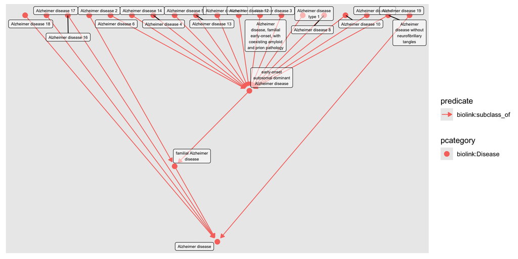

```r
quickplot <- function(g) {
    ggraph(g, layout = "sugiyama") +
        geom_edge_link(aes(color = predicate),
                                     arrow = arrow(length = unit(2, 'mm'), type = "closed"),
                                     end_cap = circle(2.5, 'mm')) +
        geom_node_point(aes(color = pcategory),
                                        size = 3) +
        geom_node_label(aes(label = str_wrap(name, 20)),
                                        size = 2,
                                        repel = TRUE,
                                        check_overlap = TRUE,
                                        fill = "#FFFFFF88")
}


quickplot(alz)
```

Cool. Let’s summarize the neighborhood in this graph to see how many phenotypes etc. are connected.

```r
alz |> summarize_neighborhood(summarize = "nodes")
```

```
## # A tibble: 4 × 2
##   pcategory                 count
##   <chr>                     <int>
## 1 biolink:PhenotypicFeature    85
## 2 biolink:Gene                 17
## 3 biolink:ChemicalEntity       16
## 4 biolink:Disease              13
```

Now, let’s look for behavior-related entities.

```r
monarch_engine() |>
    search_nodes("behavior")
```

#### Nodes

Showing 10 of 10 nodes:

| id | pcategory | name | description | synonym (list) | category (list) | iri | xref (list) | provided_by (list) |
| --- | --- | --- | --- | --- | --- | --- | --- | --- |
| “HP:0000708” | “biolink:PhenotypicFeature” | “Atypical behavior” | “Atypical behavior is an abnormality in a person’s actions, which can be controlled or modulated by the will of the individual. While abnormal behaviors can be difficult to control, they are distinct … | c(“Behavioral abnormality”, “Behavioral changes”, “Behavioral disorders”, “Behavioral disturbances”, “Behavioral problems”, “Behavioral symptoms”, “Behavioral/psychiatric abnormalities”, “Behavioural … | c(“biolink:BiologicalEntity”, “biolink:DiseaseOrPhenotypicFeature”, “biolink:Entity”, “biolink:NamedThing”, “biolink:PhenotypicFeature”, “biolink:ThingWithTaxon”) | “http://purl.obolibrary.org/obo/HP_0000708” | c(“MSH:D000066553”, “MSH:D001526”, “SNOMEDCT_US:25786006”, “SNOMEDCT_US:277843001”, “UMLS:C0004941”, “UMLS:C0233514”) | “phenio_nodes” |
| “HP:0000718” | “biolink:PhenotypicFeature” | “Aggressive behavior” | “Behavior or an act aimed at harming a person, animal, or physical property (e.g., acts of physical violence; shouting, swearing, and using harsh language; slashing someone’s tires).” | c(“Aggression”, “Aggressive behavior”, “Aggressive behaviour”, “Aggressiveness”, “physical aggression”) | c(“biolink:BiologicalEntity”, “biolink:DiseaseOrPhenotypicFeature”, “biolink:Entity”, “biolink:NamedThing”, “biolink:PhenotypicFeature”, “biolink:ThingWithTaxon”) | “http://purl.obolibrary.org/obo/HP_0000718” | c(“MSH:D000374”, “SNOMEDCT_US:248004009”, “SNOMEDCT_US:61372001”, “UMLS:C0001807”, “UMLS:C0424323”, “UMLS:C1457883”) | “phenio_nodes” |
| “HP:0008760” | “biolink:PhenotypicFeature” | “Violent behavior” | “Conduct and/or behavior, both verbal and non-verbal, including but not limited to verbal and/or physical aggression, attacks, threats, harassment, intimidation, and other disruptive behaviors in any … | c(“Violent behavior”, “Violent behaviour”) | c(“biolink:BiologicalEntity”, “biolink:DiseaseOrPhenotypicFeature”, “biolink:Entity”, “biolink:NamedThing”, “biolink:PhenotypicFeature”, “biolink:ThingWithTaxon”) | “http://purl.obolibrary.org/obo/HP_0008760” | c(“SNOMEDCT_US:248004009”, “UMLS:C0424323”) | “phenio_nodes” |
| “MP:0001408” | “biolink:PhenotypicFeature” | “stereotypic behavior” | “repetitive, invariant, perseverative motor patterns that do not appear to be purposeful” | “stereotypic behaviour” | c(“biolink:BiologicalEntity”, “biolink:DiseaseOrPhenotypicFeature”, “biolink:Entity”, “biolink:NamedThing”, “biolink:PhenotypicFeature”, “biolink:ThingWithTaxon”) | “http://purl.obolibrary.org/obo/MP_0001408” | NA | “phenio_nodes” |
| “MP:0004924” | “biolink:PhenotypicFeature” | “abnormal behavior” | “any anomaly in the actions, reactions, or performance of an organism in response to external or internal stimuli compared to controls” | c(“abnormal behaviour”, “abnormal general behavior”, “abnormal general behaviour”) | c(“biolink:BiologicalEntity”, “biolink:DiseaseOrPhenotypicFeature”, “biolink:Entity”, “biolink:NamedThing”, “biolink:PhenotypicFeature”, “biolink:ThingWithTaxon”) | “http://purl.obolibrary.org/obo/MP_0004924” | NA | “phenio_nodes” |
| “GO:0007610” | “biolink:BiologicalEntity” | “behavior” | “The internally coordinated responses (actions or inactions) of animals (individuals or groups) to internal or external stimuli, via a mechanism that involves nervous system activity.” | c(“behavioral response to stimulus”, “behaviour”, “behavioural response to stimulus”, “single-organism behavior”) | c(“biolink:BiologicalEntity”, “biolink:BiologicalProcessOrActivity”, “biolink:Entity”, “biolink:NamedThing”, “biolink:Occurrent”, “biolink:OntologyClass”, “biolink:PhysicalEssenceOrOccurrent”, “biolin… | “http://purl.obolibrary.org/obo/GO_0007610” | “Wikipedia:Behavior” | “phenio_nodes” |
| “MONDO:0800106” | “biolink:Disease” | “disruptive behavior disorder” | “A mental disorder that includes conduct disorder (CD), oppositional defiant disorder (ODD), and attention Deficit Hyperactivity Disorder (ADHD). Features may include frequent aggression, deceitfulnes… | “disruptive disorder” | c(“biolink:BiologicalEntity”, “biolink:Disease”, “biolink:DiseaseOrPhenotypicFeature”, “biolink:Entity”, “biolink:NamedThing”, “biolink:ThingWithTaxon”) | “http://purl.obolibrary.org/obo/MONDO_0800106” | “NCIT:C99753” | “phenio_nodes” |
| “WBPhenotype:0000517” | “biolink:PhenotypicFeature” | “behavior phenotype” | “Variations in the specific actions or reactions in response to external or internal stimuli compared to that observed in control animals.” | c(“behavior abnormal”, “behavior variant”) | c(“biolink:BiologicalEntity”, “biolink:DiseaseOrPhenotypicFeature”, “biolink:Entity”, “biolink:NamedThing”, “biolink:PhenotypicFeature”, “biolink:ThingWithTaxon”) | “http://purl.obolibrary.org/obo/WBPhenotype_0000517” | NA | “phenio_nodes” |
| “XPO:0128000” | “biolink:PhenotypicFeature” | “absent behavior” | “Absence of behavior.” | NA | c(“biolink:BiologicalEntity”, “biolink:DiseaseOrPhenotypicFeature”, “biolink:Entity”, “biolink:NamedThing”, “biolink:PhenotypicFeature”, “biolink:ThingWithTaxon”) | “http://purl.obolibrary.org/obo/XPO_0128000” | NA | “phenio_nodes” |
| “XPO:0116429” | “biolink:PhenotypicFeature” | “abnormal behavior” | “An anomaly in behavior.” | NA | c(“biolink:BiologicalEntity”, “biolink:DiseaseOrPhenotypicFeature”, “biolink:Entity”, “biolink:NamedThing”, “biolink:PhenotypicFeature”, “biolink:ThingWithTaxon”) | “http://purl.obolibrary.org/obo/XPO_0116429” | NA | “phenio_nodes” |

#### Edges

Showing 0 of 0 edges:

“Atypical behavior” sounds likely. We’ll get it’s descendents and ancestors.

```r
atypical_behaviors_desc <- monarch_engine() |>
    fetch_nodes(query_ids = "HP:0000708") |>
    expand(predicates = "biolink:subclass_of", direction = "in", transitive = TRUE)

atypical_behaviors_desc
```

#### Nodes

Showing 100 of 723 nodes:

| id | pcategory | name | description | synonym (list) | category (list) | iri | xref (list) | provided_by (list) |
| --- | --- | --- | --- | --- | --- | --- | --- | --- |
| “HP:0000708” | “biolink:PhenotypicFeature” | “Atypical behavior” | “Atypical behavior is an abnormality in a person’s actions, which can be controlled or modulated by the will of the individual. While abnormal behaviors can be difficult to control, they are distinct … | c(“Behavioral abnormality”, “Behavioral changes”, “Behavioral disorders”, “Behavioral disturbances”, “Behavioral problems”, “Behavioral symptoms”, “Behavioral/psychiatric abnormalities”, “Behavioural … | c(“biolink:BiologicalEntity”, “biolink:DiseaseOrPhenotypicFeature”, “biolink:Entity”, “biolink:NamedThing”, “biolink:PhenotypicFeature”, “biolink:ThingWithTaxon”) | “http://purl.obolibrary.org/obo/HP_0000708” | c(“MSH:D000066553”, “MSH:D001526”, “SNOMEDCT_US:25786006”, “SNOMEDCT_US:277843001”, “UMLS:C0004941”, “UMLS:C0233514”) | “phenio_nodes” |
| “HP:0000738” | “biolink:PhenotypicFeature” | “Hallucinations” | “Perceptions in a conscious and awake state in the absence of external stimuli which have qualities of real perception, in that they are vivid, substantial, and located in external objective space.” | c(“Hallucination”, “Hallucinations”, “Sensory hallucination”) | c(“biolink:BiologicalEntity”, “biolink:DiseaseOrPhenotypicFeature”, “biolink:Entity”, “biolink:NamedThing”, “biolink:PhenotypicFeature”, “biolink:ThingWithTaxon”) | “http://purl.obolibrary.org/obo/HP_0000738” | c(“MSH:D006212”, “SNOMEDCT_US:7011001”, “UMLS:C0018524”, “UMLS:C0235153”) | “phenio_nodes” |
| “HP:0006896” | “biolink:PhenotypicFeature” | “Hypnopompic hallucinations” | “Fleeting perceptual experiences that occur during the transition from sleep to wakefulness.” | NA | c(“biolink:BiologicalEntity”, “biolink:DiseaseOrPhenotypicFeature”, “biolink:Entity”, “biolink:NamedThing”, “biolink:PhenotypicFeature”, “biolink:ThingWithTaxon”) | “http://purl.obolibrary.org/obo/HP_0006896” | c(“MSH:D006212”, “SNOMEDCT_US:69690008”, “UMLS:C0424082”) | “phenio_nodes” |
| “HP:0002519” | “biolink:PhenotypicFeature” | “Hypnagogic hallucinations” | “Fleeting perceptual experiences that occur during the transition from wakefulness to sleep.” | NA | c(“biolink:BiologicalEntity”, “biolink:DiseaseOrPhenotypicFeature”, “biolink:Entity”, “biolink:NamedThing”, “biolink:PhenotypicFeature”, “biolink:ThingWithTaxon”) | “http://purl.obolibrary.org/obo/HP_0002519” | c(“MSH:D006212”, “SNOMEDCT_US:44780000”, “UMLS:C0233773”) | “phenio_nodes” |
| “HP:0008765” | “biolink:PhenotypicFeature” | “Auditory hallucinations” | “The false perception of sound.” | c(“Hallucinations of sound”, “Hearing sounds”) | c(“biolink:BiologicalEntity”, “biolink:DiseaseOrPhenotypicFeature”, “biolink:Entity”, “biolink:NamedThing”, “biolink:PhenotypicFeature”, “biolink:ThingWithTaxon”) | “http://purl.obolibrary.org/obo/HP_0008765” | c(“MSH:D006212”, “SNOMEDCT_US:45150006”, “UMLS:C0233762”) | “phenio_nodes” |
| “HP:0006803” | “biolink:PhenotypicFeature” | “Vivid hallucinations” | NA | NA | c(“biolink:BiologicalEntity”, “biolink:DiseaseOrPhenotypicFeature”, “biolink:Entity”, “biolink:NamedThing”, “biolink:PhenotypicFeature”, “biolink:ThingWithTaxon”) | “http://purl.obolibrary.org/obo/HP_0006803” | “UMLS:C4024978” | “phenio_nodes” |
| “HP:0033694” | “biolink:PhenotypicFeature” | “Tactile hallucination” | “The false perception of tactile sensory input that creates a hallucinatory sensation of physical contact with an imaginary object.” | “Tactile hallucinations” | c(“biolink:BiologicalEntity”, “biolink:DiseaseOrPhenotypicFeature”, “biolink:Entity”, “biolink:NamedThing”, “biolink:PhenotypicFeature”, “biolink:ThingWithTaxon”) | “http://purl.obolibrary.org/obo/HP_0033694” | NA | “phenio_nodes” |
| “HP:0002367” | “biolink:PhenotypicFeature” | “Visual hallucinations” | “Visual perceptions that are not elicited by a corresponding stimulus from the outside world.” | “Visual hallucinations” | c(“biolink:BiologicalEntity”, “biolink:DiseaseOrPhenotypicFeature”, “biolink:Entity”, “biolink:NamedThing”, “biolink:PhenotypicFeature”, “biolink:ThingWithTaxon”) | “http://purl.obolibrary.org/obo/HP_0002367” | c(“MSH:D006212”, “SNOMEDCT_US:64269007”, “UMLS:C0233763”) | “phenio_nodes” |
| “HP:0000709” | “biolink:PhenotypicFeature” | “Psychosis” | “A condition characterized by changes of personality and thought patterns often accompanied by hallucinations and delusional beliefs.” | “Psychosis” | c(“biolink:BiologicalEntity”, “biolink:DiseaseOrPhenotypicFeature”, “biolink:Entity”, “biolink:NamedThing”, “biolink:PhenotypicFeature”, “biolink:ThingWithTaxon”) | “http://purl.obolibrary.org/obo/HP_0000709” | c(“MSH:D011618”, “SNOMEDCT_US:69322001”, “UMLS:C0033975”) | “phenio_nodes” |
| “HP:0001345” | “biolink:PhenotypicFeature” | “Psychotic mentation” | NA | NA | c(“biolink:BiologicalEntity”, “biolink:DiseaseOrPhenotypicFeature”, “biolink:Entity”, “biolink:NamedThing”, “biolink:PhenotypicFeature”, “biolink:ThingWithTaxon”) | “http://purl.obolibrary.org/obo/HP_0001345” | “UMLS:C4025789” | “phenio_nodes” |
| “HP:0000725” | “biolink:PhenotypicFeature” | “Psychotic episodes” | NA | “Psychotic episodes” | c(“biolink:BiologicalEntity”, “biolink:DiseaseOrPhenotypicFeature”, “biolink:Entity”, “biolink:NamedThing”, “biolink:PhenotypicFeature”, “biolink:ThingWithTaxon”) | “http://purl.obolibrary.org/obo/HP_0000725” | “UMLS:C0338614” | “phenio_nodes” |
| “HP:0006932” | “biolink:PhenotypicFeature” | “Transient psychotic episodes” | NA | NA | c(“biolink:BiologicalEntity”, “biolink:DiseaseOrPhenotypicFeature”, “biolink:Entity”, “biolink:NamedThing”, “biolink:PhenotypicFeature”, “biolink:ThingWithTaxon”) | “http://purl.obolibrary.org/obo/HP_0006932” | “UMLS:C4024958” | “phenio_nodes” |
| “HP:0100753” | “biolink:PhenotypicFeature” | “Schizophrenia” | “A mental disorder characterized by a disintegration of thought processes and of emotional responsiveness. It most commonly manifests as auditory hallucinations, paranoid or bizarre delusions, or diso… | NA | c(“biolink:BiologicalEntity”, “biolink:DiseaseOrPhenotypicFeature”, “biolink:Entity”, “biolink:NamedThing”, “biolink:PhenotypicFeature”, “biolink:ThingWithTaxon”) | “http://purl.obolibrary.org/obo/HP_0100753” | c(“MSH:D012559”, “SNOMEDCT_US:191526005”, “SNOMEDCT_US:58214004”, “UMLS:C0036341”) | “phenio_nodes” |
| “HP:0000496” | “biolink:PhenotypicFeature” | “Abnormality of eye movement” | “An abnormality in voluntary or involuntary eye movements or their control.” | c(“Abnormal extraocular movement”, “Abnormal extraocular movements”, “Abnormal eye motility”, “Abnormal eye movement”, “Abnormal eye movements”, “Abnormal motility of the globe of the eye”, “Abnormal … | c(“biolink:BiologicalEntity”, “biolink:DiseaseOrPhenotypicFeature”, “biolink:Entity”, “biolink:NamedThing”, “biolink:PhenotypicFeature”, “biolink:ThingWithTaxon”) | “http://purl.obolibrary.org/obo/HP_0000496” | c(“SNOMEDCT_US:103252009”, “UMLS:C0497202”) | “phenio_nodes” |
| “HP:0007941” | “biolink:PhenotypicFeature” | “Limited extraocular movements” | “Limited mobility of the eye within its socket.” | “Limited extraocular movement” | c(“biolink:BiologicalEntity”, “biolink:DiseaseOrPhenotypicFeature”, “biolink:Entity”, “biolink:NamedThing”, “biolink:PhenotypicFeature”, “biolink:ThingWithTaxon”) | “http://purl.obolibrary.org/obo/HP_0007941” | “UMLS:C1858427” | “phenio_nodes” |
| “HP:0025721” | “biolink:PhenotypicFeature” | “Limited vertical extraocular movement” | “Limited mobility of the eye to move up and down (vertically) within its socket.” | NA | c(“biolink:BiologicalEntity”, “biolink:DiseaseOrPhenotypicFeature”, “biolink:Entity”, “biolink:NamedThing”, “biolink:PhenotypicFeature”, “biolink:ThingWithTaxon”) | “http://purl.obolibrary.org/obo/HP_0025721” | NA | “phenio_nodes” |
| “HP:0025720” | “biolink:PhenotypicFeature” | “Limited horizontal extraocular movement” | “Limited mobility of the eye to move from side to side (horizontally) within its socket.” | NA | c(“biolink:BiologicalEntity”, “biolink:DiseaseOrPhenotypicFeature”, “biolink:Entity”, “biolink:NamedThing”, “biolink:PhenotypicFeature”, “biolink:ThingWithTaxon”) | “http://purl.obolibrary.org/obo/HP_0025720” | NA | “phenio_nodes” |
| “HP:0000617” | “biolink:PhenotypicFeature” | “Abnormality of ocular smooth pursuit” | “An abnormality of eye movement characterized by impaired smooth-pursuit eye movements.” | c(“Abnormal smooth pursuits”, “Disrupted ocular pursuit movements”, “Impaired smooth pursuit ocular movements”, “Irregular visual pursuit movements”) | c(“biolink:BiologicalEntity”, “biolink:DiseaseOrPhenotypicFeature”, “biolink:Entity”, “biolink:NamedThing”, “biolink:PhenotypicFeature”, “biolink:ThingWithTaxon”) | “http://purl.obolibrary.org/obo/HP_0000617” | “UMLS:C1836393” | “phenio_nodes” |
| “HP:0001152” | “biolink:PhenotypicFeature” | “Saccadic smooth pursuit” | “An abnormality of tracking eye movements in which smooth pursuit is interrupted by an abnormally high number of saccadic movements.” | c(“Saccadic pursuit movements”, “Saccadic slow pursuit”) | c(“biolink:BiologicalEntity”, “biolink:DiseaseOrPhenotypicFeature”, “biolink:Entity”, “biolink:NamedThing”, “biolink:PhenotypicFeature”, “biolink:ThingWithTaxon”) | “http://purl.obolibrary.org/obo/HP_0001152” | “UMLS:C1836479” | “phenio_nodes” |
| “HP:0007792” | “biolink:PhenotypicFeature” | “Microsaccadic pursuit” | NA | NA | c(“biolink:BiologicalEntity”, “biolink:DiseaseOrPhenotypicFeature”, “biolink:Entity”, “biolink:NamedThing”, “biolink:PhenotypicFeature”, “biolink:ThingWithTaxon”) | “http://purl.obolibrary.org/obo/HP_0007792” | “UMLS:C1843892” | “phenio_nodes” |
| “HP:0007944” | “biolink:PhenotypicFeature” | “Intermittent microsaccadic pursuits” | NA | NA | c(“biolink:BiologicalEntity”, “biolink:DiseaseOrPhenotypicFeature”, “biolink:Entity”, “biolink:NamedThing”, “biolink:PhenotypicFeature”, “biolink:ThingWithTaxon”) | “http://purl.obolibrary.org/obo/HP_0007944” | “UMLS:C4024768” | “phenio_nodes” |
| “HP:0007772” | “biolink:PhenotypicFeature” | “Impaired smooth pursuit” | “An impairment of the ability to track objects with the ocular smooth pursuit system, a class of rather slow eye movements that minimizes retinal target motion.” | c(“Abnormal visual pursuit”, “Abnormality of visual tracking”, “Impairment of visual pursuit”) | c(“biolink:BiologicalEntity”, “biolink:DiseaseOrPhenotypicFeature”, “biolink:Entity”, “biolink:NamedThing”, “biolink:PhenotypicFeature”, “biolink:ThingWithTaxon”) | “http://purl.obolibrary.org/obo/HP_0007772” | c(“UMLS:C1837458”, “UMLS:C1848530”) | “phenio_nodes” |
| “HP:0007179” | “biolink:PhenotypicFeature” | “Absent smooth pursuit” | “A complete lack of the ability to track objects with the ocular smooth pursuit system, a class of rather slow eye movements that minimizes retinal target motion.” | NA | c(“biolink:BiologicalEntity”, “biolink:DiseaseOrPhenotypicFeature”, “biolink:Entity”, “biolink:NamedThing”, “biolink:PhenotypicFeature”, “biolink:ThingWithTaxon”) | “http://purl.obolibrary.org/obo/HP_0007179” | “UMLS:C4024928” | “phenio_nodes” |
| “HP:0001151” | “biolink:PhenotypicFeature” | “Impaired horizontal smooth pursuit” | “An abnormality of ocular smooth pursuit characterized by an impairment of the ability to track horizontally moving objects.” | c(“Abnormal horizontal ocular pursuit”, “Impaired horizontal visual pursuit”) | c(“biolink:BiologicalEntity”, “biolink:DiseaseOrPhenotypicFeature”, “biolink:Entity”, “biolink:NamedThing”, “biolink:PhenotypicFeature”, “biolink:ThingWithTaxon”) | “http://purl.obolibrary.org/obo/HP_0001151” | “UMLS:C1866753” | “phenio_nodes” |
| “HP:0008003” | “biolink:PhenotypicFeature” | “Jerky ocular pursuit movements” | NA | “Jerky smooth pursuit” | c(“biolink:BiologicalEntity”, “biolink:DiseaseOrPhenotypicFeature”, “biolink:Entity”, “biolink:NamedThing”, “biolink:PhenotypicFeature”, “biolink:ThingWithTaxon”) | “http://purl.obolibrary.org/obo/HP_0008003” | “UMLS:C1853558” | “phenio_nodes” |
| “HP:0007668” | “biolink:PhenotypicFeature” | “Impaired pursuit initiation and maintenance” | NA | NA | c(“biolink:BiologicalEntity”, “biolink:DiseaseOrPhenotypicFeature”, “biolink:Entity”, “biolink:NamedThing”, “biolink:PhenotypicFeature”, “biolink:ThingWithTaxon”) | “http://purl.obolibrary.org/obo/HP_0007668” | “UMLS:C1969722” | “phenio_nodes” |
| “HP:0025404” | “biolink:PhenotypicFeature” | “Abnormal visual fixation” | “Any anomaly in the process of ocular fixation, which is the maintaining of the visual gaze on a single location.” | NA | c(“biolink:BiologicalEntity”, “biolink:DiseaseOrPhenotypicFeature”, “biolink:Entity”, “biolink:NamedThing”, “biolink:PhenotypicFeature”, “biolink:ThingWithTaxon”) | “http://purl.obolibrary.org/obo/HP_0025404” | NA | “phenio_nodes” |
| “HP:0025405” | “biolink:PhenotypicFeature” | “Visual fixation instability” | “A deficit in the ability to fixate eye movements in order to stabilize images on the retina” | “Instability of ocular fixation” | c(“biolink:BiologicalEntity”, “biolink:DiseaseOrPhenotypicFeature”, “biolink:Entity”, “biolink:NamedThing”, “biolink:PhenotypicFeature”, “biolink:ThingWithTaxon”) | “http://purl.obolibrary.org/obo/HP_0025405” | NA | “phenio_nodes” |
| “HP:0025549” | “biolink:PhenotypicFeature” | “Eccentric visual fixation” | “A uniocular condition in which there is fixation of an object by a point other than the fovea. This point adopts the principal visual direction. The degree of the eccentric fixation is defined by its… | “Eccentric fixation” | c(“biolink:BiologicalEntity”, “biolink:DiseaseOrPhenotypicFeature”, “biolink:Entity”, “biolink:NamedThing”, “biolink:PhenotypicFeature”, “biolink:ThingWithTaxon”) | “http://purl.obolibrary.org/obo/HP_0025549” | NA | “phenio_nodes” |
| “HP:0031769” | “biolink:PhenotypicFeature” | “Peripheral fixation” | “Fixation of an object in a peripheral area of the retina.” | NA | c(“biolink:BiologicalEntity”, “biolink:DiseaseOrPhenotypicFeature”, “biolink:Entity”, “biolink:NamedThing”, “biolink:PhenotypicFeature”, “biolink:ThingWithTaxon”) | “http://purl.obolibrary.org/obo/HP_0031769” | NA | “phenio_nodes” |

[output cut: 70 more lines]

#### Edges

Showing 100 of 800 edges:

| from | to | subject | predicate | object | agent_type | knowledge_level | knowledge_source | aggregator_knowledge_source (list) | primary_knowledge_source | provided_by (list) | id | category (list) |
| --- | --- | --- | --- | --- | --- | --- | --- | --- | --- | --- | --- | --- |
| 2 | 1 | “HP:0000738” | “biolink:subclass_of” | “HP:0000708” | “not_provided” | “not_provided” | “monarch-kg_edges.jsonl” | c(“infores:monarchinitiative”, “infores:phenio”) | “infores:hp” | “phenio_edges” | “urn:uuid:ec28353d-fee3-498f-b3db-3614e7d58cd7” | c(“biolink:Association”, “biolink:Entity”) |
| 3 | 2 | “HP:0006896” | “biolink:subclass_of” | “HP:0000738” | “not_provided” | “not_provided” | “monarch-kg_edges.jsonl” | c(“infores:monarchinitiative”, “infores:phenio”) | “infores:hp” | “phenio_edges” | “urn:uuid:821bb47c-90a4-4bbd-9878-aee67f7bbce4” | c(“biolink:Association”, “biolink:Entity”) |
| 4 | 2 | “HP:0002519” | “biolink:subclass_of” | “HP:0000738” | “not_provided” | “not_provided” | “monarch-kg_edges.jsonl” | c(“infores:monarchinitiative”, “infores:phenio”) | “infores:hp” | “phenio_edges” | “urn:uuid:5dc954a4-6886-48a2-8227-6f1c828a8261” | c(“biolink:Association”, “biolink:Entity”) |
| 5 | 2 | “HP:0008765” | “biolink:subclass_of” | “HP:0000738” | “not_provided” | “not_provided” | “monarch-kg_edges.jsonl” | c(“infores:monarchinitiative”, “infores:phenio”) | “infores:hp” | “phenio_edges” | “urn:uuid:3da0826d-83e8-41ce-9d4a-31eb5ca56632” | c(“biolink:Association”, “biolink:Entity”) |
| 6 | 2 | “HP:0006803” | “biolink:subclass_of” | “HP:0000738” | “not_provided” | “not_provided” | “monarch-kg_edges.jsonl” | c(“infores:monarchinitiative”, “infores:phenio”) | “infores:hp” | “phenio_edges” | “urn:uuid:588d17f2-cd18-41a1-87c2-f79d055df410” | c(“biolink:Association”, “biolink:Entity”) |
| 7 | 2 | “HP:0033694” | “biolink:subclass_of” | “HP:0000738” | “not_provided” | “not_provided” | “monarch-kg_edges.jsonl” | c(“infores:monarchinitiative”, “infores:phenio”) | “infores:hp” | “phenio_edges” | “urn:uuid:f2cd451e-ec74-4d09-8fab-47c33034ac8f” | c(“biolink:Association”, “biolink:Entity”) |
| 8 | 2 | “HP:0002367” | “biolink:subclass_of” | “HP:0000738” | “not_provided” | “not_provided” | “monarch-kg_edges.jsonl” | c(“infores:monarchinitiative”, “infores:phenio”) | “infores:hp” | “phenio_edges” | “urn:uuid:9927fb91-15f8-4051-a739-9d3f442c918b” | c(“biolink:Association”, “biolink:Entity”) |
| 9 | 1 | “HP:0000709” | “biolink:subclass_of” | “HP:0000708” | “not_provided” | “not_provided” | “monarch-kg_edges.jsonl” | c(“infores:monarchinitiative”, “infores:phenio”) | “infores:hp” | “phenio_edges” | “urn:uuid:c2e030e7-3e24-480a-a8bc-3b0c766e9d79” | c(“biolink:Association”, “biolink:Entity”) |
| 10 | 9 | “HP:0001345” | “biolink:subclass_of” | “HP:0000709” | “not_provided” | “not_provided” | “monarch-kg_edges.jsonl” | c(“infores:monarchinitiative”, “infores:phenio”) | “infores:hp” | “phenio_edges” | “urn:uuid:fc9433ff-4833-47bc-a813-2eb7464a31f5” | c(“biolink:Association”, “biolink:Entity”) |
| 11 | 9 | “HP:0000725” | “biolink:subclass_of” | “HP:0000709” | “not_provided” | “not_provided” | “monarch-kg_edges.jsonl” | c(“infores:monarchinitiative”, “infores:phenio”) | “infores:hp” | “phenio_edges” | “urn:uuid:05d8f41f-e303-4a85-a9e4-22f0b359ec7e” | c(“biolink:Association”, “biolink:Entity”) |
| 12 | 11 | “HP:0006932” | “biolink:subclass_of” | “HP:0000725” | “not_provided” | “not_provided” | “monarch-kg_edges.jsonl” | c(“infores:monarchinitiative”, “infores:phenio”) | “infores:hp” | “phenio_edges” | “urn:uuid:e4409dc1-a71e-4af9-aa54-1b993d4ea78c” | c(“biolink:Association”, “biolink:Entity”) |
| 13 | 1 | “HP:0100753” | “biolink:subclass_of” | “HP:0000708” | “not_provided” | “not_provided” | “monarch-kg_edges.jsonl” | c(“infores:monarchinitiative”, “infores:phenio”) | “infores:hp” | “phenio_edges” | “urn:uuid:8d6edf5a-14d2-4c59-90e5-5310397b3143” | c(“biolink:Association”, “biolink:Entity”) |
| 14 | 1 | “HP:0000496” | “biolink:subclass_of” | “HP:0000708” | “not_provided” | “not_provided” | “monarch-kg_edges.jsonl” | c(“infores:monarchinitiative”, “infores:phenio”) | “infores:hp” | “phenio_edges” | “urn:uuid:f95deeb4-467a-4ce2-9325-7955ecac464a” | c(“biolink:Association”, “biolink:Entity”) |
| 15 | 14 | “HP:0007941” | “biolink:subclass_of” | “HP:0000496” | “not_provided” | “not_provided” | “monarch-kg_edges.jsonl” | c(“infores:monarchinitiative”, “infores:phenio”) | “infores:hp” | “phenio_edges” | “urn:uuid:2cd098e2-f699-4703-8b30-1fe287294537” | c(“biolink:Association”, “biolink:Entity”) |
| 16 | 15 | “HP:0025721” | “biolink:subclass_of” | “HP:0007941” | “not_provided” | “not_provided” | “monarch-kg_edges.jsonl” | c(“infores:monarchinitiative”, “infores:phenio”) | “infores:hp” | “phenio_edges” | “urn:uuid:ffa1d62f-d95f-47e4-b9eb-450ba647c478” | c(“biolink:Association”, “biolink:Entity”) |
| 17 | 15 | “HP:0025720” | “biolink:subclass_of” | “HP:0007941” | “not_provided” | “not_provided” | “monarch-kg_edges.jsonl” | c(“infores:monarchinitiative”, “infores:phenio”) | “infores:hp” | “phenio_edges” | “urn:uuid:bd90bad2-ac98-4c7e-9417-72e87c9ca8ba” | c(“biolink:Association”, “biolink:Entity”) |
| 18 | 14 | “HP:0000617” | “biolink:subclass_of” | “HP:0000496” | “not_provided” | “not_provided” | “monarch-kg_edges.jsonl” | c(“infores:monarchinitiative”, “infores:phenio”) | “infores:hp” | “phenio_edges” | “urn:uuid:851ac639-e465-462c-9acb-ca68322c8a68” | c(“biolink:Association”, “biolink:Entity”) |
| 19 | 18 | “HP:0001152” | “biolink:subclass_of” | “HP:0000617” | “not_provided” | “not_provided” | “monarch-kg_edges.jsonl” | c(“infores:monarchinitiative”, “infores:phenio”) | “infores:hp” | “phenio_edges” | “urn:uuid:1cc3a68d-5ab4-44e5-a4e4-c8055f467ebc” | c(“biolink:Association”, “biolink:Entity”) |
| 20 | 19 | “HP:0007792” | “biolink:subclass_of” | “HP:0001152” | “not_provided” | “not_provided” | “monarch-kg_edges.jsonl” | c(“infores:monarchinitiative”, “infores:phenio”) | “infores:hp” | “phenio_edges” | “urn:uuid:e30203b9-b819-4d60-be20-04acc6038168” | c(“biolink:Association”, “biolink:Entity”) |
| 21 | 19 | “HP:0007944” | “biolink:subclass_of” | “HP:0001152” | “not_provided” | “not_provided” | “monarch-kg_edges.jsonl” | c(“infores:monarchinitiative”, “infores:phenio”) | “infores:hp” | “phenio_edges” | “urn:uuid:752b4bea-5b0c-45ee-b08c-92e6ba6a3403” | c(“biolink:Association”, “biolink:Entity”) |
| 22 | 18 | “HP:0007772” | “biolink:subclass_of” | “HP:0000617” | “not_provided” | “not_provided” | “monarch-kg_edges.jsonl” | c(“infores:monarchinitiative”, “infores:phenio”) | “infores:hp” | “phenio_edges” | “urn:uuid:ed4f655b-976a-489e-b75c-cb87f929fdc1” | c(“biolink:Association”, “biolink:Entity”) |
| 23 | 22 | “HP:0007179” | “biolink:subclass_of” | “HP:0007772” | “not_provided” | “not_provided” | “monarch-kg_edges.jsonl” | c(“infores:monarchinitiative”, “infores:phenio”) | “infores:hp” | “phenio_edges” | “urn:uuid:0ad79ae9-b3db-472e-b73b-be8445838be2” | c(“biolink:Association”, “biolink:Entity”) |
| 24 | 22 | “HP:0001151” | “biolink:subclass_of” | “HP:0007772” | “not_provided” | “not_provided” | “monarch-kg_edges.jsonl” | c(“infores:monarchinitiative”, “infores:phenio”) | “infores:hp” | “phenio_edges” | “urn:uuid:9f22fa8b-1510-4a97-b6c3-f1d06a14d457” | c(“biolink:Association”, “biolink:Entity”) |
| 25 | 18 | “HP:0008003” | “biolink:subclass_of” | “HP:0000617” | “not_provided” | “not_provided” | “monarch-kg_edges.jsonl” | c(“infores:monarchinitiative”, “infores:phenio”) | “infores:hp” | “phenio_edges” | “urn:uuid:953d9f9e-2ee7-49c6-972b-fc9df206a0fe” | c(“biolink:Association”, “biolink:Entity”) |
| 26 | 18 | “HP:0007668” | “biolink:subclass_of” | “HP:0000617” | “not_provided” | “not_provided” | “monarch-kg_edges.jsonl” | c(“infores:monarchinitiative”, “infores:phenio”) | “infores:hp” | “phenio_edges” | “urn:uuid:4551df30-a9b7-42a4-b81d-f3bad0ec16b3” | c(“biolink:Association”, “biolink:Entity”) |
| 27 | 14 | “HP:0025404” | “biolink:subclass_of” | “HP:0000496” | “not_provided” | “not_provided” | “monarch-kg_edges.jsonl” | c(“infores:monarchinitiative”, “infores:phenio”) | “infores:hp” | “phenio_edges” | “urn:uuid:14452f2d-f881-4b3a-98c1-1fd8907b0949” | c(“biolink:Association”, “biolink:Entity”) |
| 28 | 27 | “HP:0025405” | “biolink:subclass_of” | “HP:0025404” | “not_provided” | “not_provided” | “monarch-kg_edges.jsonl” | c(“infores:monarchinitiative”, “infores:phenio”) | “infores:hp” | “phenio_edges” | “urn:uuid:8c988f49-5bf4-47e2-b920-03ab7807a675” | c(“biolink:Association”, “biolink:Entity”) |
| 29 | 27 | “HP:0025549” | “biolink:subclass_of” | “HP:0025404” | “not_provided” | “not_provided” | “monarch-kg_edges.jsonl” | c(“infores:monarchinitiative”, “infores:phenio”) | “infores:hp” | “phenio_edges” | “urn:uuid:36faac0b-ede4-4271-906c-1c8561e1bddb” | c(“biolink:Association”, “biolink:Entity”) |
| 30 | 29 | “HP:0031769” | “biolink:subclass_of” | “HP:0025549” | “not_provided” | “not_provided” | “monarch-kg_edges.jsonl” | c(“infores:monarchinitiative”, “infores:phenio”) | “infores:hp” | “phenio_edges” | “urn:uuid:39b695e1-ca3c-4a36-a8d2-6bed3f2b1459” | c(“biolink:Association”, “biolink:Entity”) |
| 31 | 29 | “HP:0031768” | “biolink:subclass_of” | “HP:0025549” | “not_provided” | “not_provided” | “monarch-kg_edges.jsonl” | c(“infores:monarchinitiative”, “infores:phenio”) | “infores:hp” | “phenio_edges” | “urn:uuid:f879f962-a6f2-40b1-ad84-381e4070c545” | c(“biolink:Association”, “biolink:Entity”) |

[output cut: 70 more lines]

```r
atypical_behaviors_anc <- monarch_engine() |>
    fetch_nodes(query_ids = "HP:0000708") |>
    expand(predicates = "biolink:subclass_of", direction = "out", transitive = TRUE)

atypical_behaviors_anc
```

#### Nodes

Showing 26 of 26 nodes:

| id | pcategory | name | description | synonym (list) | category (list) | iri | xref (list) | provided_by (list) |
| --- | --- | --- | --- | --- | --- | --- | --- | --- |
| “HP:0000708” | “biolink:PhenotypicFeature” | “Atypical behavior” | “Atypical behavior is an abnormality in a person’s actions, which can be controlled or modulated by the will of the individual. While abnormal behaviors can be difficult to control, they are distinct … | c(“Behavioral abnormality”, “Behavioral changes”, “Behavioral disorders”, “Behavioral disturbances”, “Behavioral problems”, “Behavioral symptoms”, “Behavioral/psychiatric abnormalities”, “Behavioural … | c(“biolink:BiologicalEntity”, “biolink:DiseaseOrPhenotypicFeature”, “biolink:Entity”, “biolink:NamedThing”, “biolink:PhenotypicFeature”, “biolink:ThingWithTaxon”) | “http://purl.obolibrary.org/obo/HP_0000708” | c(“MSH:D000066553”, “MSH:D001526”, “SNOMEDCT_US:25786006”, “SNOMEDCT_US:277843001”, “UMLS:C0004941”, “UMLS:C0233514”) | “phenio_nodes” |
| “UPHENO:0079826” | “biolink:PhenotypicFeature” | “abnormal behavior process” | “An anomaly in behavior process.” | NA | c(“biolink:BiologicalEntity”, “biolink:DiseaseOrPhenotypicFeature”, “biolink:Entity”, “biolink:NamedThing”, “biolink:PhenotypicFeature”, “biolink:ThingWithTaxon”) | “http://purl.obolibrary.org/obo/UPHENO_0079826” | NA | “phenio_nodes” |
| “UPHENO:0049622” | “biolink:PhenotypicFeature” | “abnormal behavior” | “Abnormal behavior.” | NA | c(“biolink:BiologicalEntity”, “biolink:DiseaseOrPhenotypicFeature”, “biolink:Entity”, “biolink:NamedThing”, “biolink:PhenotypicFeature”, “biolink:ThingWithTaxon”) | “http://purl.obolibrary.org/obo/UPHENO_0049622” | NA | “phenio_nodes” |
| “UPHENO:0049586” | “biolink:PhenotypicFeature” | “abnormal response to stimulus” | “Abnormal response to stimulus.” | NA | c(“biolink:BiologicalEntity”, “biolink:DiseaseOrPhenotypicFeature”, “biolink:Entity”, “biolink:NamedThing”, “biolink:PhenotypicFeature”, “biolink:ThingWithTaxon”) | “http://purl.obolibrary.org/obo/UPHENO_0049586” | NA | “phenio_nodes” |
| “UPHENO:0049587” | “biolink:PhenotypicFeature” | “abnormal biological_process” | “Abnormal biological_process.” | NA | c(“biolink:BiologicalEntity”, “biolink:DiseaseOrPhenotypicFeature”, “biolink:Entity”, “biolink:NamedThing”, “biolink:PhenotypicFeature”, “biolink:ThingWithTaxon”) | “http://purl.obolibrary.org/obo/UPHENO_0049587” | NA | “phenio_nodes” |
| “UPHENO:0001002” | “biolink:PhenotypicFeature” | “Phenotypic abnormality” | NA | NA | c(“biolink:BiologicalEntity”, “biolink:DiseaseOrPhenotypicFeature”, “biolink:Entity”, “biolink:NamedThing”, “biolink:PhenotypicFeature”, “biolink:ThingWithTaxon”) | “http://purl.obolibrary.org/obo/UPHENO_0001002” | NA | “phenio_nodes” |
| “UPHENO:0001001” | “biolink:PhenotypicFeature” | “phenotype” | NA | NA | c(“biolink:BiologicalEntity”, “biolink:DiseaseOrPhenotypicFeature”, “biolink:Entity”, “biolink:NamedThing”, “biolink:PhenotypicFeature”, “biolink:ThingWithTaxon”) | “http://purl.obolibrary.org/obo/UPHENO_0001001” | NA | “phenio_nodes” |
| “PATO:0000001” | “biolink:Entity” | “quality” | “A dependent entity that inheres in a bearer by virtue of how the bearer is related to other entities” | NA | c(“biolink:Entity”, “biolink:NamedThing”) | “http://purl.obolibrary.org/obo/PATO_0000001” | NA | “phenio_nodes” |
| “BFO:0000020” | “biolink:Entity” | “specifically dependent continuant” | “b is a specifically dependent continuant = Def. b is a continuant & there is some independent continuant c which is not a spatial region and which is such that b s-depends_on c at every time t during… | NA | c(“biolink:Entity”, “biolink:NamedThing”) | “http://purl.obolibrary.org/obo/BFO_0000020” | NA | “phenio_nodes” |
| “BFO:0000002” | “biolink:Entity” | “continuant” | “An entity that exists in full at any time in which it exists at all, persists through time while maintaining its identity and has no temporal parts.” | NA | c(“biolink:Entity”, “biolink:NamedThing”) | “http://purl.obolibrary.org/obo/BFO_0000002” | NA | “phenio_nodes” |
| “BFO:0000001” | “biolink:Entity” | “entity” | NA | NA | c(“biolink:Entity”, “biolink:NamedThing”) | “http://purl.obolibrary.org/obo/BFO_0000001” | NA | “phenio_nodes” |
| “owl:Thing” | “biolink:Entity” | NA | NA | NA | c(“biolink:Entity”, “biolink:NamedThing”) | NA | NA | “phenio_nodes” |
| “HP:0011446” | “biolink:PhenotypicFeature” | “Abnormality of mental function” | “Cognitive, psychiatric, or memory anomaly.” | NA | c(“biolink:BiologicalEntity”, “biolink:DiseaseOrPhenotypicFeature”, “biolink:Entity”, “biolink:NamedThing”, “biolink:PhenotypicFeature”, “biolink:ThingWithTaxon”) | “http://purl.obolibrary.org/obo/HP_0011446” | “UMLS:C4023352” | “phenio_nodes” |
| “HP:0012638” | “biolink:PhenotypicFeature” | “Abnormal nervous system physiology” | “A functional anomaly of the nervous system.” | “Abnormality of nervous system physiology” | c(“biolink:BiologicalEntity”, “biolink:DiseaseOrPhenotypicFeature”, “biolink:Entity”, “biolink:NamedThing”, “biolink:PhenotypicFeature”, “biolink:ThingWithTaxon”) | “http://purl.obolibrary.org/obo/HP_0012638” | “UMLS:C4022811” | “phenio_nodes” |
| “UPHENO:0002433” | “biolink:PhenotypicFeature” | “abnormality of nervous system physiology” | “Any functional anomaly of the nervous system.” | NA | c(“biolink:BiologicalEntity”, “biolink:DiseaseOrPhenotypicFeature”, “biolink:Entity”, “biolink:NamedThing”, “biolink:PhenotypicFeature”, “biolink:ThingWithTaxon”) | “http://purl.obolibrary.org/obo/UPHENO_0002433” | NA | “phenio_nodes” |
| “UPHENO:0002332” | “biolink:PhenotypicFeature” | “abnormality of anatomical entity physiology” | “Any functional anomaly of the anatomical entity.” | NA | c(“biolink:BiologicalEntity”, “biolink:DiseaseOrPhenotypicFeature”, “biolink:Entity”, “biolink:NamedThing”, “biolink:PhenotypicFeature”, “biolink:ThingWithTaxon”) | “http://purl.obolibrary.org/obo/UPHENO_0002332” | NA | “phenio_nodes” |
| “UPHENO:0075696” | “biolink:PhenotypicFeature” | “abnormal anatomical entity” | “Abnormality of anatomical entity.” | “abnormality of anatomical entity” | c(“biolink:BiologicalEntity”, “biolink:DiseaseOrPhenotypicFeature”, “biolink:Entity”, “biolink:NamedThing”, “biolink:PhenotypicFeature”, “biolink:ThingWithTaxon”) | “http://purl.obolibrary.org/obo/UPHENO_0075696” | NA | “phenio_nodes” |
| “UPHENO:0002536” | “biolink:PhenotypicFeature” | “abnormal anatomical entity” | “Abnormality of anatomical entity.” | “abnormality of anatomical entity” | c(“biolink:BiologicalEntity”, “biolink:DiseaseOrPhenotypicFeature”, “biolink:Entity”, “biolink:NamedThing”, “biolink:PhenotypicFeature”, “biolink:ThingWithTaxon”) | “http://purl.obolibrary.org/obo/UPHENO_0002536” | NA | “phenio_nodes” |
| “UPHENO:0082875” | “biolink:PhenotypicFeature” | “abnormality of anatomical entity physiology” | “Any functional anomaly of the anatomical entity.” | NA | c(“biolink:BiologicalEntity”, “biolink:DiseaseOrPhenotypicFeature”, “biolink:Entity”, “biolink:NamedThing”, “biolink:PhenotypicFeature”, “biolink:ThingWithTaxon”) | “http://purl.obolibrary.org/obo/UPHENO_0082875” | NA | “phenio_nodes” |
| “UPHENO:0004523” | “biolink:PhenotypicFeature” | “abnormal nervous system” | “Abnormality of nervous system.” | “abnormality of nervous system” | c(“biolink:BiologicalEntity”, “biolink:DiseaseOrPhenotypicFeature”, “biolink:Entity”, “biolink:NamedThing”, “biolink:PhenotypicFeature”, “biolink:ThingWithTaxon”) | “http://purl.obolibrary.org/obo/UPHENO_0004523” | NA | “phenio_nodes” |
| “HP:0000707” | “biolink:PhenotypicFeature” | “Abnormality of the nervous system” | “An abnormality of the nervous system.” | c(“Abnormality of the nervous system”, “Brain and/or spinal cord issue”, “Neurologic abnormalities”, “Neurological abnormality”) | c(“biolink:BiologicalEntity”, “biolink:DiseaseOrPhenotypicFeature”, “biolink:Entity”, “biolink:NamedThing”, “biolink:PhenotypicFeature”, “biolink:ThingWithTaxon”) | “http://purl.obolibrary.org/obo/HP_0000707” | c(“MSH:D009421”, “SNOMEDCT_US:88425004”, “UMLS:C0497552”) | “phenio_nodes” |
| “HP:0000118” | “biolink:PhenotypicFeature” | “Phenotypic abnormality” | “A phenotypic abnormality.” | “Organ abnormality” | c(“biolink:BiologicalEntity”, “biolink:DiseaseOrPhenotypicFeature”, “biolink:Entity”, “biolink:NamedThing”, “biolink:PhenotypicFeature”, “biolink:ThingWithTaxon”) | “http://purl.obolibrary.org/obo/HP_0000118” | “UMLS:C4021819” | “phenio_nodes” |
| “UPHENO:0001005” | “biolink:PhenotypicFeature” | “abnormal phenotype by ontology source” | NA | NA | c(“biolink:BiologicalEntity”, “biolink:DiseaseOrPhenotypicFeature”, “biolink:Entity”, “biolink:NamedThing”, “biolink:PhenotypicFeature”, “biolink:ThingWithTaxon”) | “http://purl.obolibrary.org/obo/UPHENO_0001005” | NA | “phenio_nodes” |
| “UPHENO:0001003” | “biolink:PhenotypicFeature” | “phenotype by ontology source” | NA | NA | c(“biolink:BiologicalEntity”, “biolink:DiseaseOrPhenotypicFeature”, “biolink:Entity”, “biolink:NamedThing”, “biolink:PhenotypicFeature”, “biolink:ThingWithTaxon”) | “http://purl.obolibrary.org/obo/UPHENO_0001003” | NA | “phenio_nodes” |
| “HP:0000001” | “biolink:PhenotypicFeature” | “All” | NA | NA | c(“biolink:BiologicalEntity”, “biolink:DiseaseOrPhenotypicFeature”, “biolink:Entity”, “biolink:NamedThing”, “biolink:PhenotypicFeature”, “biolink:ThingWithTaxon”) | “http://purl.obolibrary.org/obo/HP_0000001” | “UMLS:C0444868” | “phenio_nodes” |
| “UPHENO:0080585” | “biolink:PhenotypicFeature” | “abnormal behavior process” | “Abnormal behavior process.” | NA | c(“biolink:BiologicalEntity”, “biolink:DiseaseOrPhenotypicFeature”, “biolink:Entity”, “biolink:NamedThing”, “biolink:PhenotypicFeature”, “biolink:ThingWithTaxon”) | “http://purl.obolibrary.org/obo/UPHENO_0080585” | NA | “phenio_nodes” |

#### Edges

Showing 33 of 33 edges:

| from | to | subject | predicate | object | agent_type | knowledge_level | knowledge_source | aggregator_knowledge_source (list) | primary_knowledge_source | provided_by (list) | id | category (list) |
| --- | --- | --- | --- | --- | --- | --- | --- | --- | --- | --- | --- | --- |
| 1 | 2 | “HP:0000708” | “biolink:subclass_of” | “UPHENO:0079826” | “not_provided” | “not_provided” | “monarch-kg_edges.jsonl” | c(“infores:monarchinitiative”, “infores:phenio”) | “infores:upheno” | “phenio_edges” | “urn:uuid:ea0fe099-2093-431e-bb2e-f3efcb88c699” | c(“biolink:Association”, “biolink:Entity”) |
| 2 | 3 | “UPHENO:0079826” | “biolink:subclass_of” | “UPHENO:0049622” | “not_provided” | “not_provided” | “monarch-kg_edges.jsonl” | c(“infores:monarchinitiative”, “infores:phenio”) | “infores:upheno” | “phenio_edges” | “urn:uuid:686554b0-e9bb-4bdf-8db9-829f11f07800” | c(“biolink:Association”, “biolink:Entity”) |
| 3 | 4 | “UPHENO:0049622” | “biolink:subclass_of” | “UPHENO:0049586” | “not_provided” | “not_provided” | “monarch-kg_edges.jsonl” | c(“infores:monarchinitiative”, “infores:phenio”) | “infores:upheno” | “phenio_edges” | “urn:uuid:669604b6-cc6f-45ed-a48f-9fdf037e287d” | c(“biolink:Association”, “biolink:Entity”) |
| 4 | 5 | “UPHENO:0049586” | “biolink:subclass_of” | “UPHENO:0049587” | “not_provided” | “not_provided” | “monarch-kg_edges.jsonl” | c(“infores:monarchinitiative”, “infores:phenio”) | “infores:upheno” | “phenio_edges” | “urn:uuid:2694926f-3445-4f9c-badd-49ee74035e0f” | c(“biolink:Association”, “biolink:Entity”) |
| 5 | 6 | “UPHENO:0049587” | “biolink:subclass_of” | “UPHENO:0001002” | “not_provided” | “not_provided” | “monarch-kg_edges.jsonl” | c(“infores:monarchinitiative”, “infores:phenio”) | “infores:upheno” | “phenio_edges” | “urn:uuid:b4f63efc-5a0f-42dd-bbb6-8fbe6939b54a” | c(“biolink:Association”, “biolink:Entity”) |
| 6 | 7 | “UPHENO:0001002” | “biolink:subclass_of” | “UPHENO:0001001” | “not_provided” | “not_provided” | “monarch-kg_edges.jsonl” | c(“infores:monarchinitiative”, “infores:phenio”) | “infores:upheno” | “phenio_edges” | “urn:uuid:63d66254-41e4-4e73-ac1b-5bb4fcc48758” | c(“biolink:Association”, “biolink:Entity”) |
| 7 | 8 | “UPHENO:0001001” | “biolink:subclass_of” | “PATO:0000001” | “not_provided” | “not_provided” | “monarch-kg_edges.jsonl” | c(“infores:monarchinitiative”, “infores:phenio”) | “infores:upheno” | “phenio_edges” | “urn:uuid:7c8d5bc5-fbf3-4429-8f3a-aa748f4f0f51” | c(“biolink:Association”, “biolink:Entity”) |
| 8 | 9 | “PATO:0000001” | “biolink:subclass_of” | “BFO:0000020” | “not_provided” | “not_provided” | “monarch-kg_edges.jsonl” | c(“infores:monarchinitiative”, “infores:phenio”) | “infores:pato” | “phenio_edges” | “urn:uuid:f40e9885-475a-4b26-8606-d591f756452b” | c(“biolink:Association”, “biolink:Entity”) |
| 9 | 10 | “BFO:0000020” | “biolink:subclass_of” | “BFO:0000002” | “not_provided” | “not_provided” | “monarch-kg_edges.jsonl” | c(“infores:monarchinitiative”, “infores:phenio”) | “infores:bfo” | “phenio_edges” | “urn:uuid:120e3bab-5648-4a22-a13b-7d19cd53971e” | c(“biolink:Association”, “biolink:Entity”) |
| 10 | 11 | “BFO:0000002” | “biolink:subclass_of” | “BFO:0000001” | “not_provided” | “not_provided” | “monarch-kg_edges.jsonl” | c(“infores:monarchinitiative”, “infores:phenio”) | “infores:bfo” | “phenio_edges” | “urn:uuid:f5d75c5f-6a65-4a40-acf2-1ba715e245c6” | c(“biolink:Association”, “biolink:Entity”) |
| 11 | 12 | “BFO:0000001” | “biolink:subclass_of” | “owl:Thing” | “not_provided” | “not_provided” | “monarch-kg_edges.jsonl” | c(“infores:monarchinitiative”, “infores:phenio”) | “infores:bfo” | “phenio_edges” | “urn:uuid:7f628f6d-3f60-4898-934c-a18db64cdf48” | c(“biolink:Association”, “biolink:Entity”) |
| 1 | 13 | “HP:0000708” | “biolink:subclass_of” | “HP:0011446” | “not_provided” | “not_provided” | “monarch-kg_edges.jsonl” | c(“infores:monarchinitiative”, “infores:phenio”) | “infores:hp” | “phenio_edges” | “urn:uuid:4c7f296f-0872-48ff-adb4-0b7dd7ddde93” | c(“biolink:Association”, “biolink:Entity”) |
| 13 | 14 | “HP:0011446” | “biolink:subclass_of” | “HP:0012638” | “not_provided” | “not_provided” | “monarch-kg_edges.jsonl” | c(“infores:monarchinitiative”, “infores:phenio”) | “infores:hp” | “phenio_edges” | “urn:uuid:52d9ad85-db50-4285-90c1-da3057a352dd” | c(“biolink:Association”, “biolink:Entity”) |
| 14 | 15 | “HP:0012638” | “biolink:subclass_of” | “UPHENO:0002433” | “not_provided” | “not_provided” | “monarch-kg_edges.jsonl” | c(“infores:monarchinitiative”, “infores:phenio”) | “infores:upheno” | “phenio_edges” | “urn:uuid:2b03b16f-1261-4e20-85d0-af0d61bcc462” | c(“biolink:Association”, “biolink:Entity”) |
| 15 | 16 | “UPHENO:0002433” | “biolink:subclass_of” | “UPHENO:0002332” | “not_provided” | “not_provided” | “monarch-kg_edges.jsonl” | c(“infores:monarchinitiative”, “infores:phenio”) | “infores:upheno” | “phenio_edges” | “urn:uuid:46beab44-686a-4b58-a10a-3f13e5e7b13c” | c(“biolink:Association”, “biolink:Entity”) |
| 16 | 17 | “UPHENO:0002332” | “biolink:subclass_of” | “UPHENO:0075696” | “not_provided” | “not_provided” | “monarch-kg_edges.jsonl” | c(“infores:monarchinitiative”, “infores:phenio”) | “infores:upheno” | “phenio_edges” | “urn:uuid:e2f92bda-1d34-41bb-aa33-a4d63e4b63ad” | c(“biolink:Association”, “biolink:Entity”) |
| 17 | 18 | “UPHENO:0075696” | “biolink:subclass_of” | “UPHENO:0002536” | “not_provided” | “not_provided” | “monarch-kg_edges.jsonl” | c(“infores:monarchinitiative”, “infores:phenio”) | “infores:upheno” | “phenio_edges” | “urn:uuid:0169cbea-7d0c-47b9-aaa0-ce0bb3973abf” | c(“biolink:Association”, “biolink:Entity”) |
| 18 | 6 | “UPHENO:0002536” | “biolink:subclass_of” | “UPHENO:0001002” | “not_provided” | “not_provided” | “monarch-kg_edges.jsonl” | c(“infores:monarchinitiative”, “infores:phenio”) | “infores:upheno” | “phenio_edges” | “urn:uuid:fe482f81-d7dc-47b6-888a-236c0fe12c62” | c(“biolink:Association”, “biolink:Entity”) |
| 16 | 19 | “UPHENO:0002332” | “biolink:subclass_of” | “UPHENO:0082875” | “not_provided” | “not_provided” | “monarch-kg_edges.jsonl” | c(“infores:monarchinitiative”, “infores:phenio”) | “infores:upheno” | “phenio_edges” | “urn:uuid:d6d19f9e-e173-4c7c-8f9e-bab3567617ee” | c(“biolink:Association”, “biolink:Entity”) |
| 19 | 18 | “UPHENO:0082875” | “biolink:subclass_of” | “UPHENO:0002536” | “not_provided” | “not_provided” | “monarch-kg_edges.jsonl” | c(“infores:monarchinitiative”, “infores:phenio”) | “infores:upheno” | “phenio_edges” | “urn:uuid:66e89a75-d632-486e-a854-9f18ea06bb8d” | c(“biolink:Association”, “biolink:Entity”) |
| 15 | 20 | “UPHENO:0002433” | “biolink:subclass_of” | “UPHENO:0004523” | “not_provided” | “not_provided” | “monarch-kg_edges.jsonl” | c(“infores:monarchinitiative”, “infores:phenio”) | “infores:upheno” | “phenio_edges” | “urn:uuid:bdc42acc-7a3b-4dbc-91d8-3500d93adad6” | c(“biolink:Association”, “biolink:Entity”) |
| 20 | 18 | “UPHENO:0004523” | “biolink:subclass_of” | “UPHENO:0002536” | “not_provided” | “not_provided” | “monarch-kg_edges.jsonl” | c(“infores:monarchinitiative”, “infores:phenio”) | “infores:upheno” | “phenio_edges” | “urn:uuid:18ae929d-d066-47f2-8d8f-c2ecc6cdc2df” | c(“biolink:Association”, “biolink:Entity”) |
| 14 | 21 | “HP:0012638” | “biolink:subclass_of” | “HP:0000707” | “not_provided” | “not_provided” | “monarch-kg_edges.jsonl” | c(“infores:monarchinitiative”, “infores:phenio”) | “infores:hp” | “phenio_edges” | “urn:uuid:fa9d30dd-0c18-4a6c-bdd9-93de51aab1ce” | c(“biolink:Association”, “biolink:Entity”) |
| 21 | 22 | “HP:0000707” | “biolink:subclass_of” | “HP:0000118” | “not_provided” | “not_provided” | “monarch-kg_edges.jsonl” | c(“infores:monarchinitiative”, “infores:phenio”) | “infores:hp” | “phenio_edges” | “urn:uuid:d080714e-d81c-4008-a3f1-dbb05946b861” | c(“biolink:Association”, “biolink:Entity”) |
| 22 | 23 | “HP:0000118” | “biolink:subclass_of” | “UPHENO:0001005” | “not_provided” | “not_provided” | “monarch-kg_edges.jsonl” | c(“infores:monarchinitiative”, “infores:phenio”) | “infores:upheno” | “phenio_edges” | “urn:uuid:a3116e7f-169d-4523-89df-0baf541e1a3b” | c(“biolink:Association”, “biolink:Entity”) |
| 23 | 6 | “UPHENO:0001005” | “biolink:subclass_of” | “UPHENO:0001002” | “not_provided” | “not_provided” | “monarch-kg_edges.jsonl” | c(“infores:monarchinitiative”, “infores:phenio”) | “infores:upheno” | “phenio_edges” | “urn:uuid:2cb36138-94c4-45c9-bee0-d33fdc7fe282” | c(“biolink:Association”, “biolink:Entity”) |
| 23 | 24 | “UPHENO:0001005” | “biolink:subclass_of” | “UPHENO:0001003” | “not_provided” | “not_provided” | “monarch-kg_edges.jsonl” | c(“infores:monarchinitiative”, “infores:phenio”) | “infores:upheno” | “phenio_edges” | “urn:uuid:f9f99f57-6044-4390-9858-14fe917802c0” | c(“biolink:Association”, “biolink:Entity”) |
| 24 | 7 | “UPHENO:0001003” | “biolink:subclass_of” | “UPHENO:0001001” | “not_provided” | “not_provided” | “monarch-kg_edges.jsonl” | c(“infores:monarchinitiative”, “infores:phenio”) | “infores:upheno” | “phenio_edges” | “urn:uuid:dfceed2a-3d90-48a6-8c87-7c794c944952” | c(“biolink:Association”, “biolink:Entity”) |
| 22 | 25 | “HP:0000118” | “biolink:subclass_of” | “HP:0000001” | “not_provided” | “not_provided” | “monarch-kg_edges.jsonl” | c(“infores:monarchinitiative”, “infores:phenio”) | “infores:hp” | “phenio_edges” | “urn:uuid:52d5587c-a23f-418d-a0d2-52fc97520729” | c(“biolink:Association”, “biolink:Entity”) |
| 25 | 12 | “HP:0000001” | “biolink:subclass_of” | “owl:Thing” | “not_provided” | “not_provided” | “monarch-kg_edges.jsonl” | c(“infores:monarchinitiative”, “infores:phenio”) | “infores:hp” | “phenio_edges” | “urn:uuid:3a730158-6b50-47f2-91ae-78db2ef46f11” | c(“biolink:Association”, “biolink:Entity”) |
| 21 | 20 | “HP:0000707” | “biolink:subclass_of” | “UPHENO:0004523” | “not_provided” | “not_provided” | “monarch-kg_edges.jsonl” | c(“infores:monarchinitiative”, “infores:phenio”) | “infores:upheno” | “phenio_edges” | “urn:uuid:41b12cc8-fc3a-4eab-82c3-f60a5b8117f3” | c(“biolink:Association”, “biolink:Entity”) |
| 1 | 26 | “HP:0000708” | “biolink:subclass_of” | “UPHENO:0080585” | “not_provided” | “not_provided” | “monarch-kg_edges.jsonl” | c(“infores:monarchinitiative”, “infores:phenio”) | “infores:upheno” | “phenio_edges” | “urn:uuid:8472b346-261a-4426-b751-b9413456f1ca” | c(“biolink:Association”, “biolink:Entity”) |
| 26 | 3 | “UPHENO:0080585” | “biolink:subclass_of” | “UPHENO:0049622” | “not_provided” | “not_provided” | “monarch-kg_edges.jsonl” | c(“infores:monarchinitiative”, “infores:phenio”) | “infores:upheno” | “phenio_edges” | “urn:uuid:85abd002-0b9e-4f3b-84e9-1636351f34cd” | c(“biolink:Association”, “biolink:Entity”) |

Over 700 subtypes of atypical behavior, and 26 ancestors; let’s plot the latter to see if there are more general terms we should consider.

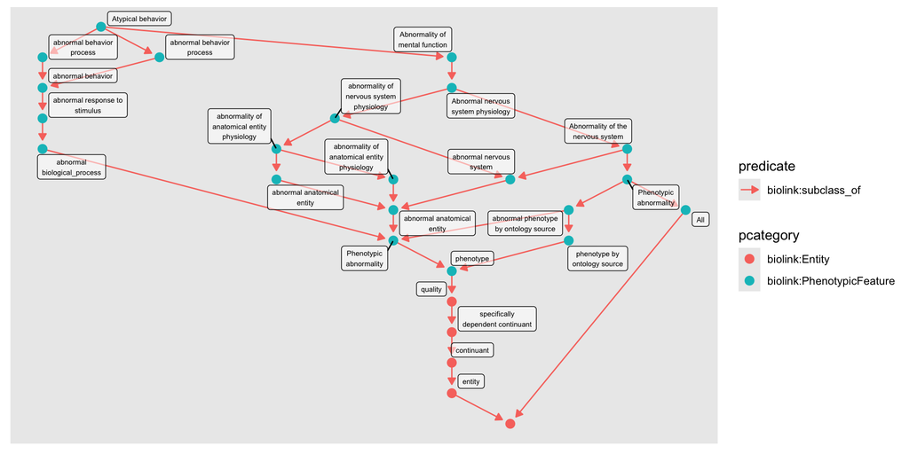

```r
quickplot(atypical_behaviors_anc)
```

So there are a two higher-level entities that we might use instead of Atypical behavior - “abnormal behavior” and “Abnormality of mental function.” Let’s get the subtypes of both of those.

```r
atypical_behaviors <- atypical_behaviors_anc |>
    activate(nodes) |>
    filter(name == "abnormal behavior") |>
    expand(predicates = "biolink:subclass_of", direction = "in", transitive = TRUE)
```

Next, the complete subtypes for “Abnormality of mental function”.

```r
atypical_mental_functions <- atypical_behaviors_anc |>
    activate(nodes) |>
    filter(name == "Abnormality of mental function") |>
    expand(predicates = "biolink:subclass_of", direction = "in", transitive = TRUE)

atypical_mental_functions
```

#### Nodes

Showing 100 of 821 nodes:

| id | pcategory | name | description | synonym (list) | category (list) | iri | xref (list) | provided_by (list) |
| --- | --- | --- | --- | --- | --- | --- | --- | --- |
| “HP:0011446” | “biolink:PhenotypicFeature” | “Abnormality of mental function” | “Cognitive, psychiatric, or memory anomaly.” | NA | c(“biolink:BiologicalEntity”, “biolink:DiseaseOrPhenotypicFeature”, “biolink:Entity”, “biolink:NamedThing”, “biolink:PhenotypicFeature”, “biolink:ThingWithTaxon”) | “http://purl.obolibrary.org/obo/HP_0011446” | “UMLS:C4023352” | “phenio_nodes” |
| “HP:0000708” | “biolink:PhenotypicFeature” | “Atypical behavior” | “Atypical behavior is an abnormality in a person’s actions, which can be controlled or modulated by the will of the individual. While abnormal behaviors can be difficult to control, they are distinct … | c(“Behavioral abnormality”, “Behavioral changes”, “Behavioral disorders”, “Behavioral disturbances”, “Behavioral problems”, “Behavioral symptoms”, “Behavioral/psychiatric abnormalities”, “Behavioural … | c(“biolink:BiologicalEntity”, “biolink:DiseaseOrPhenotypicFeature”, “biolink:Entity”, “biolink:NamedThing”, “biolink:PhenotypicFeature”, “biolink:ThingWithTaxon”) | “http://purl.obolibrary.org/obo/HP_0000708” | c(“MSH:D000066553”, “MSH:D001526”, “SNOMEDCT_US:25786006”, “SNOMEDCT_US:277843001”, “UMLS:C0004941”, “UMLS:C0233514”) | “phenio_nodes” |
| “HP:0000738” | “biolink:PhenotypicFeature” | “Hallucinations” | “Perceptions in a conscious and awake state in the absence of external stimuli which have qualities of real perception, in that they are vivid, substantial, and located in external objective space.” | c(“Hallucination”, “Hallucinations”, “Sensory hallucination”) | c(“biolink:BiologicalEntity”, “biolink:DiseaseOrPhenotypicFeature”, “biolink:Entity”, “biolink:NamedThing”, “biolink:PhenotypicFeature”, “biolink:ThingWithTaxon”) | “http://purl.obolibrary.org/obo/HP_0000738” | c(“MSH:D006212”, “SNOMEDCT_US:7011001”, “UMLS:C0018524”, “UMLS:C0235153”) | “phenio_nodes” |
| “HP:0006896” | “biolink:PhenotypicFeature” | “Hypnopompic hallucinations” | “Fleeting perceptual experiences that occur during the transition from sleep to wakefulness.” | NA | c(“biolink:BiologicalEntity”, “biolink:DiseaseOrPhenotypicFeature”, “biolink:Entity”, “biolink:NamedThing”, “biolink:PhenotypicFeature”, “biolink:ThingWithTaxon”) | “http://purl.obolibrary.org/obo/HP_0006896” | c(“MSH:D006212”, “SNOMEDCT_US:69690008”, “UMLS:C0424082”) | “phenio_nodes” |
| “HP:0002519” | “biolink:PhenotypicFeature” | “Hypnagogic hallucinations” | “Fleeting perceptual experiences that occur during the transition from wakefulness to sleep.” | NA | c(“biolink:BiologicalEntity”, “biolink:DiseaseOrPhenotypicFeature”, “biolink:Entity”, “biolink:NamedThing”, “biolink:PhenotypicFeature”, “biolink:ThingWithTaxon”) | “http://purl.obolibrary.org/obo/HP_0002519” | c(“MSH:D006212”, “SNOMEDCT_US:44780000”, “UMLS:C0233773”) | “phenio_nodes” |
| “HP:0008765” | “biolink:PhenotypicFeature” | “Auditory hallucinations” | “The false perception of sound.” | c(“Hallucinations of sound”, “Hearing sounds”) | c(“biolink:BiologicalEntity”, “biolink:DiseaseOrPhenotypicFeature”, “biolink:Entity”, “biolink:NamedThing”, “biolink:PhenotypicFeature”, “biolink:ThingWithTaxon”) | “http://purl.obolibrary.org/obo/HP_0008765” | c(“MSH:D006212”, “SNOMEDCT_US:45150006”, “UMLS:C0233762”) | “phenio_nodes” |
| “HP:0006803” | “biolink:PhenotypicFeature” | “Vivid hallucinations” | NA | NA | c(“biolink:BiologicalEntity”, “biolink:DiseaseOrPhenotypicFeature”, “biolink:Entity”, “biolink:NamedThing”, “biolink:PhenotypicFeature”, “biolink:ThingWithTaxon”) | “http://purl.obolibrary.org/obo/HP_0006803” | “UMLS:C4024978” | “phenio_nodes” |
| “HP:0033694” | “biolink:PhenotypicFeature” | “Tactile hallucination” | “The false perception of tactile sensory input that creates a hallucinatory sensation of physical contact with an imaginary object.” | “Tactile hallucinations” | c(“biolink:BiologicalEntity”, “biolink:DiseaseOrPhenotypicFeature”, “biolink:Entity”, “biolink:NamedThing”, “biolink:PhenotypicFeature”, “biolink:ThingWithTaxon”) | “http://purl.obolibrary.org/obo/HP_0033694” | NA | “phenio_nodes” |
| “HP:0002367” | “biolink:PhenotypicFeature” | “Visual hallucinations” | “Visual perceptions that are not elicited by a corresponding stimulus from the outside world.” | “Visual hallucinations” | c(“biolink:BiologicalEntity”, “biolink:DiseaseOrPhenotypicFeature”, “biolink:Entity”, “biolink:NamedThing”, “biolink:PhenotypicFeature”, “biolink:ThingWithTaxon”) | “http://purl.obolibrary.org/obo/HP_0002367” | c(“MSH:D006212”, “SNOMEDCT_US:64269007”, “UMLS:C0233763”) | “phenio_nodes” |
| “HP:0000709” | “biolink:PhenotypicFeature” | “Psychosis” | “A condition characterized by changes of personality and thought patterns often accompanied by hallucinations and delusional beliefs.” | “Psychosis” | c(“biolink:BiologicalEntity”, “biolink:DiseaseOrPhenotypicFeature”, “biolink:Entity”, “biolink:NamedThing”, “biolink:PhenotypicFeature”, “biolink:ThingWithTaxon”) | “http://purl.obolibrary.org/obo/HP_0000709” | c(“MSH:D011618”, “SNOMEDCT_US:69322001”, “UMLS:C0033975”) | “phenio_nodes” |
| “HP:0001345” | “biolink:PhenotypicFeature” | “Psychotic mentation” | NA | NA | c(“biolink:BiologicalEntity”, “biolink:DiseaseOrPhenotypicFeature”, “biolink:Entity”, “biolink:NamedThing”, “biolink:PhenotypicFeature”, “biolink:ThingWithTaxon”) | “http://purl.obolibrary.org/obo/HP_0001345” | “UMLS:C4025789” | “phenio_nodes” |
| “HP:0000725” | “biolink:PhenotypicFeature” | “Psychotic episodes” | NA | “Psychotic episodes” | c(“biolink:BiologicalEntity”, “biolink:DiseaseOrPhenotypicFeature”, “biolink:Entity”, “biolink:NamedThing”, “biolink:PhenotypicFeature”, “biolink:ThingWithTaxon”) | “http://purl.obolibrary.org/obo/HP_0000725” | “UMLS:C0338614” | “phenio_nodes” |
| “HP:0006932” | “biolink:PhenotypicFeature” | “Transient psychotic episodes” | NA | NA | c(“biolink:BiologicalEntity”, “biolink:DiseaseOrPhenotypicFeature”, “biolink:Entity”, “biolink:NamedThing”, “biolink:PhenotypicFeature”, “biolink:ThingWithTaxon”) | “http://purl.obolibrary.org/obo/HP_0006932” | “UMLS:C4024958” | “phenio_nodes” |
| “HP:0100753” | “biolink:PhenotypicFeature” | “Schizophrenia” | “A mental disorder characterized by a disintegration of thought processes and of emotional responsiveness. It most commonly manifests as auditory hallucinations, paranoid or bizarre delusions, or diso… | NA | c(“biolink:BiologicalEntity”, “biolink:DiseaseOrPhenotypicFeature”, “biolink:Entity”, “biolink:NamedThing”, “biolink:PhenotypicFeature”, “biolink:ThingWithTaxon”) | “http://purl.obolibrary.org/obo/HP_0100753” | c(“MSH:D012559”, “SNOMEDCT_US:191526005”, “SNOMEDCT_US:58214004”, “UMLS:C0036341”) | “phenio_nodes” |
| “HP:0000496” | “biolink:PhenotypicFeature” | “Abnormality of eye movement” | “An abnormality in voluntary or involuntary eye movements or their control.” | c(“Abnormal extraocular movement”, “Abnormal extraocular movements”, “Abnormal eye motility”, “Abnormal eye movement”, “Abnormal eye movements”, “Abnormal motility of the globe of the eye”, “Abnormal … | c(“biolink:BiologicalEntity”, “biolink:DiseaseOrPhenotypicFeature”, “biolink:Entity”, “biolink:NamedThing”, “biolink:PhenotypicFeature”, “biolink:ThingWithTaxon”) | “http://purl.obolibrary.org/obo/HP_0000496” | c(“SNOMEDCT_US:103252009”, “UMLS:C0497202”) | “phenio_nodes” |
| “HP:0007941” | “biolink:PhenotypicFeature” | “Limited extraocular movements” | “Limited mobility of the eye within its socket.” | “Limited extraocular movement” | c(“biolink:BiologicalEntity”, “biolink:DiseaseOrPhenotypicFeature”, “biolink:Entity”, “biolink:NamedThing”, “biolink:PhenotypicFeature”, “biolink:ThingWithTaxon”) | “http://purl.obolibrary.org/obo/HP_0007941” | “UMLS:C1858427” | “phenio_nodes” |
| “HP:0025721” | “biolink:PhenotypicFeature” | “Limited vertical extraocular movement” | “Limited mobility of the eye to move up and down (vertically) within its socket.” | NA | c(“biolink:BiologicalEntity”, “biolink:DiseaseOrPhenotypicFeature”, “biolink:Entity”, “biolink:NamedThing”, “biolink:PhenotypicFeature”, “biolink:ThingWithTaxon”) | “http://purl.obolibrary.org/obo/HP_0025721” | NA | “phenio_nodes” |
| “HP:0025720” | “biolink:PhenotypicFeature” | “Limited horizontal extraocular movement” | “Limited mobility of the eye to move from side to side (horizontally) within its socket.” | NA | c(“biolink:BiologicalEntity”, “biolink:DiseaseOrPhenotypicFeature”, “biolink:Entity”, “biolink:NamedThing”, “biolink:PhenotypicFeature”, “biolink:ThingWithTaxon”) | “http://purl.obolibrary.org/obo/HP_0025720” | NA | “phenio_nodes” |
| “HP:0000617” | “biolink:PhenotypicFeature” | “Abnormality of ocular smooth pursuit” | “An abnormality of eye movement characterized by impaired smooth-pursuit eye movements.” | c(“Abnormal smooth pursuits”, “Disrupted ocular pursuit movements”, “Impaired smooth pursuit ocular movements”, “Irregular visual pursuit movements”) | c(“biolink:BiologicalEntity”, “biolink:DiseaseOrPhenotypicFeature”, “biolink:Entity”, “biolink:NamedThing”, “biolink:PhenotypicFeature”, “biolink:ThingWithTaxon”) | “http://purl.obolibrary.org/obo/HP_0000617” | “UMLS:C1836393” | “phenio_nodes” |
| “HP:0001152” | “biolink:PhenotypicFeature” | “Saccadic smooth pursuit” | “An abnormality of tracking eye movements in which smooth pursuit is interrupted by an abnormally high number of saccadic movements.” | c(“Saccadic pursuit movements”, “Saccadic slow pursuit”) | c(“biolink:BiologicalEntity”, “biolink:DiseaseOrPhenotypicFeature”, “biolink:Entity”, “biolink:NamedThing”, “biolink:PhenotypicFeature”, “biolink:ThingWithTaxon”) | “http://purl.obolibrary.org/obo/HP_0001152” | “UMLS:C1836479” | “phenio_nodes” |
| “HP:0007792” | “biolink:PhenotypicFeature” | “Microsaccadic pursuit” | NA | NA | c(“biolink:BiologicalEntity”, “biolink:DiseaseOrPhenotypicFeature”, “biolink:Entity”, “biolink:NamedThing”, “biolink:PhenotypicFeature”, “biolink:ThingWithTaxon”) | “http://purl.obolibrary.org/obo/HP_0007792” | “UMLS:C1843892” | “phenio_nodes” |
| “HP:0007944” | “biolink:PhenotypicFeature” | “Intermittent microsaccadic pursuits” | NA | NA | c(“biolink:BiologicalEntity”, “biolink:DiseaseOrPhenotypicFeature”, “biolink:Entity”, “biolink:NamedThing”, “biolink:PhenotypicFeature”, “biolink:ThingWithTaxon”) | “http://purl.obolibrary.org/obo/HP_0007944” | “UMLS:C4024768” | “phenio_nodes” |
| “HP:0007772” | “biolink:PhenotypicFeature” | “Impaired smooth pursuit” | “An impairment of the ability to track objects with the ocular smooth pursuit system, a class of rather slow eye movements that minimizes retinal target motion.” | c(“Abnormal visual pursuit”, “Abnormality of visual tracking”, “Impairment of visual pursuit”) | c(“biolink:BiologicalEntity”, “biolink:DiseaseOrPhenotypicFeature”, “biolink:Entity”, “biolink:NamedThing”, “biolink:PhenotypicFeature”, “biolink:ThingWithTaxon”) | “http://purl.obolibrary.org/obo/HP_0007772” | c(“UMLS:C1837458”, “UMLS:C1848530”) | “phenio_nodes” |
| “HP:0007179” | “biolink:PhenotypicFeature” | “Absent smooth pursuit” | “A complete lack of the ability to track objects with the ocular smooth pursuit system, a class of rather slow eye movements that minimizes retinal target motion.” | NA | c(“biolink:BiologicalEntity”, “biolink:DiseaseOrPhenotypicFeature”, “biolink:Entity”, “biolink:NamedThing”, “biolink:PhenotypicFeature”, “biolink:ThingWithTaxon”) | “http://purl.obolibrary.org/obo/HP_0007179” | “UMLS:C4024928” | “phenio_nodes” |
| “HP:0001151” | “biolink:PhenotypicFeature” | “Impaired horizontal smooth pursuit” | “An abnormality of ocular smooth pursuit characterized by an impairment of the ability to track horizontally moving objects.” | c(“Abnormal horizontal ocular pursuit”, “Impaired horizontal visual pursuit”) | c(“biolink:BiologicalEntity”, “biolink:DiseaseOrPhenotypicFeature”, “biolink:Entity”, “biolink:NamedThing”, “biolink:PhenotypicFeature”, “biolink:ThingWithTaxon”) | “http://purl.obolibrary.org/obo/HP_0001151” | “UMLS:C1866753” | “phenio_nodes” |
| “HP:0008003” | “biolink:PhenotypicFeature” | “Jerky ocular pursuit movements” | NA | “Jerky smooth pursuit” | c(“biolink:BiologicalEntity”, “biolink:DiseaseOrPhenotypicFeature”, “biolink:Entity”, “biolink:NamedThing”, “biolink:PhenotypicFeature”, “biolink:ThingWithTaxon”) | “http://purl.obolibrary.org/obo/HP_0008003” | “UMLS:C1853558” | “phenio_nodes” |
| “HP:0007668” | “biolink:PhenotypicFeature” | “Impaired pursuit initiation and maintenance” | NA | NA | c(“biolink:BiologicalEntity”, “biolink:DiseaseOrPhenotypicFeature”, “biolink:Entity”, “biolink:NamedThing”, “biolink:PhenotypicFeature”, “biolink:ThingWithTaxon”) | “http://purl.obolibrary.org/obo/HP_0007668” | “UMLS:C1969722” | “phenio_nodes” |
| “HP:0025404” | “biolink:PhenotypicFeature” | “Abnormal visual fixation” | “Any anomaly in the process of ocular fixation, which is the maintaining of the visual gaze on a single location.” | NA | c(“biolink:BiologicalEntity”, “biolink:DiseaseOrPhenotypicFeature”, “biolink:Entity”, “biolink:NamedThing”, “biolink:PhenotypicFeature”, “biolink:ThingWithTaxon”) | “http://purl.obolibrary.org/obo/HP_0025404” | NA | “phenio_nodes” |
| “HP:0025405” | “biolink:PhenotypicFeature” | “Visual fixation instability” | “A deficit in the ability to fixate eye movements in order to stabilize images on the retina” | “Instability of ocular fixation” | c(“biolink:BiologicalEntity”, “biolink:DiseaseOrPhenotypicFeature”, “biolink:Entity”, “biolink:NamedThing”, “biolink:PhenotypicFeature”, “biolink:ThingWithTaxon”) | “http://purl.obolibrary.org/obo/HP_0025405” | NA | “phenio_nodes” |
| “HP:0025549” | “biolink:PhenotypicFeature” | “Eccentric visual fixation” | “A uniocular condition in which there is fixation of an object by a point other than the fovea. This point adopts the principal visual direction. The degree of the eccentric fixation is defined by its… | “Eccentric fixation” | c(“biolink:BiologicalEntity”, “biolink:DiseaseOrPhenotypicFeature”, “biolink:Entity”, “biolink:NamedThing”, “biolink:PhenotypicFeature”, “biolink:ThingWithTaxon”) | “http://purl.obolibrary.org/obo/HP_0025549” | NA | “phenio_nodes” |

[output cut: 70 more lines]

#### Edges

Showing 100 of 906 edges:

| from | to | subject | predicate | object | agent_type | knowledge_level | knowledge_source | aggregator_knowledge_source (list) | primary_knowledge_source | provided_by (list) | id | category (list) |
| --- | --- | --- | --- | --- | --- | --- | --- | --- | --- | --- | --- | --- |
| 2 | 1 | “HP:0000708” | “biolink:subclass_of” | “HP:0011446” | “not_provided” | “not_provided” | “monarch-kg_edges.jsonl” | c(“infores:monarchinitiative”, “infores:phenio”) | “infores:hp” | “phenio_edges” | “urn:uuid:4c7f296f-0872-48ff-adb4-0b7dd7ddde93” | c(“biolink:Association”, “biolink:Entity”) |
| 3 | 2 | “HP:0000738” | “biolink:subclass_of” | “HP:0000708” | “not_provided” | “not_provided” | “monarch-kg_edges.jsonl” | c(“infores:monarchinitiative”, “infores:phenio”) | “infores:hp” | “phenio_edges” | “urn:uuid:ec28353d-fee3-498f-b3db-3614e7d58cd7” | c(“biolink:Association”, “biolink:Entity”) |
| 4 | 3 | “HP:0006896” | “biolink:subclass_of” | “HP:0000738” | “not_provided” | “not_provided” | “monarch-kg_edges.jsonl” | c(“infores:monarchinitiative”, “infores:phenio”) | “infores:hp” | “phenio_edges” | “urn:uuid:821bb47c-90a4-4bbd-9878-aee67f7bbce4” | c(“biolink:Association”, “biolink:Entity”) |
| 5 | 3 | “HP:0002519” | “biolink:subclass_of” | “HP:0000738” | “not_provided” | “not_provided” | “monarch-kg_edges.jsonl” | c(“infores:monarchinitiative”, “infores:phenio”) | “infores:hp” | “phenio_edges” | “urn:uuid:5dc954a4-6886-48a2-8227-6f1c828a8261” | c(“biolink:Association”, “biolink:Entity”) |
| 6 | 3 | “HP:0008765” | “biolink:subclass_of” | “HP:0000738” | “not_provided” | “not_provided” | “monarch-kg_edges.jsonl” | c(“infores:monarchinitiative”, “infores:phenio”) | “infores:hp” | “phenio_edges” | “urn:uuid:3da0826d-83e8-41ce-9d4a-31eb5ca56632” | c(“biolink:Association”, “biolink:Entity”) |
| 7 | 3 | “HP:0006803” | “biolink:subclass_of” | “HP:0000738” | “not_provided” | “not_provided” | “monarch-kg_edges.jsonl” | c(“infores:monarchinitiative”, “infores:phenio”) | “infores:hp” | “phenio_edges” | “urn:uuid:588d17f2-cd18-41a1-87c2-f79d055df410” | c(“biolink:Association”, “biolink:Entity”) |
| 8 | 3 | “HP:0033694” | “biolink:subclass_of” | “HP:0000738” | “not_provided” | “not_provided” | “monarch-kg_edges.jsonl” | c(“infores:monarchinitiative”, “infores:phenio”) | “infores:hp” | “phenio_edges” | “urn:uuid:f2cd451e-ec74-4d09-8fab-47c33034ac8f” | c(“biolink:Association”, “biolink:Entity”) |
| 9 | 3 | “HP:0002367” | “biolink:subclass_of” | “HP:0000738” | “not_provided” | “not_provided” | “monarch-kg_edges.jsonl” | c(“infores:monarchinitiative”, “infores:phenio”) | “infores:hp” | “phenio_edges” | “urn:uuid:9927fb91-15f8-4051-a739-9d3f442c918b” | c(“biolink:Association”, “biolink:Entity”) |
| 10 | 2 | “HP:0000709” | “biolink:subclass_of” | “HP:0000708” | “not_provided” | “not_provided” | “monarch-kg_edges.jsonl” | c(“infores:monarchinitiative”, “infores:phenio”) | “infores:hp” | “phenio_edges” | “urn:uuid:c2e030e7-3e24-480a-a8bc-3b0c766e9d79” | c(“biolink:Association”, “biolink:Entity”) |
| 11 | 10 | “HP:0001345” | “biolink:subclass_of” | “HP:0000709” | “not_provided” | “not_provided” | “monarch-kg_edges.jsonl” | c(“infores:monarchinitiative”, “infores:phenio”) | “infores:hp” | “phenio_edges” | “urn:uuid:fc9433ff-4833-47bc-a813-2eb7464a31f5” | c(“biolink:Association”, “biolink:Entity”) |
| 12 | 10 | “HP:0000725” | “biolink:subclass_of” | “HP:0000709” | “not_provided” | “not_provided” | “monarch-kg_edges.jsonl” | c(“infores:monarchinitiative”, “infores:phenio”) | “infores:hp” | “phenio_edges” | “urn:uuid:05d8f41f-e303-4a85-a9e4-22f0b359ec7e” | c(“biolink:Association”, “biolink:Entity”) |
| 13 | 12 | “HP:0006932” | “biolink:subclass_of” | “HP:0000725” | “not_provided” | “not_provided” | “monarch-kg_edges.jsonl” | c(“infores:monarchinitiative”, “infores:phenio”) | “infores:hp” | “phenio_edges” | “urn:uuid:e4409dc1-a71e-4af9-aa54-1b993d4ea78c” | c(“biolink:Association”, “biolink:Entity”) |
| 14 | 2 | “HP:0100753” | “biolink:subclass_of” | “HP:0000708” | “not_provided” | “not_provided” | “monarch-kg_edges.jsonl” | c(“infores:monarchinitiative”, “infores:phenio”) | “infores:hp” | “phenio_edges” | “urn:uuid:8d6edf5a-14d2-4c59-90e5-5310397b3143” | c(“biolink:Association”, “biolink:Entity”) |
| 15 | 2 | “HP:0000496” | “biolink:subclass_of” | “HP:0000708” | “not_provided” | “not_provided” | “monarch-kg_edges.jsonl” | c(“infores:monarchinitiative”, “infores:phenio”) | “infores:hp” | “phenio_edges” | “urn:uuid:f95deeb4-467a-4ce2-9325-7955ecac464a” | c(“biolink:Association”, “biolink:Entity”) |
| 16 | 15 | “HP:0007941” | “biolink:subclass_of” | “HP:0000496” | “not_provided” | “not_provided” | “monarch-kg_edges.jsonl” | c(“infores:monarchinitiative”, “infores:phenio”) | “infores:hp” | “phenio_edges” | “urn:uuid:2cd098e2-f699-4703-8b30-1fe287294537” | c(“biolink:Association”, “biolink:Entity”) |
| 17 | 16 | “HP:0025721” | “biolink:subclass_of” | “HP:0007941” | “not_provided” | “not_provided” | “monarch-kg_edges.jsonl” | c(“infores:monarchinitiative”, “infores:phenio”) | “infores:hp” | “phenio_edges” | “urn:uuid:ffa1d62f-d95f-47e4-b9eb-450ba647c478” | c(“biolink:Association”, “biolink:Entity”) |
| 18 | 16 | “HP:0025720” | “biolink:subclass_of” | “HP:0007941” | “not_provided” | “not_provided” | “monarch-kg_edges.jsonl” | c(“infores:monarchinitiative”, “infores:phenio”) | “infores:hp” | “phenio_edges” | “urn:uuid:bd90bad2-ac98-4c7e-9417-72e87c9ca8ba” | c(“biolink:Association”, “biolink:Entity”) |
| 19 | 15 | “HP:0000617” | “biolink:subclass_of” | “HP:0000496” | “not_provided” | “not_provided” | “monarch-kg_edges.jsonl” | c(“infores:monarchinitiative”, “infores:phenio”) | “infores:hp” | “phenio_edges” | “urn:uuid:851ac639-e465-462c-9acb-ca68322c8a68” | c(“biolink:Association”, “biolink:Entity”) |
| 20 | 19 | “HP:0001152” | “biolink:subclass_of” | “HP:0000617” | “not_provided” | “not_provided” | “monarch-kg_edges.jsonl” | c(“infores:monarchinitiative”, “infores:phenio”) | “infores:hp” | “phenio_edges” | “urn:uuid:1cc3a68d-5ab4-44e5-a4e4-c8055f467ebc” | c(“biolink:Association”, “biolink:Entity”) |
| 21 | 20 | “HP:0007792” | “biolink:subclass_of” | “HP:0001152” | “not_provided” | “not_provided” | “monarch-kg_edges.jsonl” | c(“infores:monarchinitiative”, “infores:phenio”) | “infores:hp” | “phenio_edges” | “urn:uuid:e30203b9-b819-4d60-be20-04acc6038168” | c(“biolink:Association”, “biolink:Entity”) |
| 22 | 20 | “HP:0007944” | “biolink:subclass_of” | “HP:0001152” | “not_provided” | “not_provided” | “monarch-kg_edges.jsonl” | c(“infores:monarchinitiative”, “infores:phenio”) | “infores:hp” | “phenio_edges” | “urn:uuid:752b4bea-5b0c-45ee-b08c-92e6ba6a3403” | c(“biolink:Association”, “biolink:Entity”) |
| 23 | 19 | “HP:0007772” | “biolink:subclass_of” | “HP:0000617” | “not_provided” | “not_provided” | “monarch-kg_edges.jsonl” | c(“infores:monarchinitiative”, “infores:phenio”) | “infores:hp” | “phenio_edges” | “urn:uuid:ed4f655b-976a-489e-b75c-cb87f929fdc1” | c(“biolink:Association”, “biolink:Entity”) |
| 24 | 23 | “HP:0007179” | “biolink:subclass_of” | “HP:0007772” | “not_provided” | “not_provided” | “monarch-kg_edges.jsonl” | c(“infores:monarchinitiative”, “infores:phenio”) | “infores:hp” | “phenio_edges” | “urn:uuid:0ad79ae9-b3db-472e-b73b-be8445838be2” | c(“biolink:Association”, “biolink:Entity”) |
| 25 | 23 | “HP:0001151” | “biolink:subclass_of” | “HP:0007772” | “not_provided” | “not_provided” | “monarch-kg_edges.jsonl” | c(“infores:monarchinitiative”, “infores:phenio”) | “infores:hp” | “phenio_edges” | “urn:uuid:9f22fa8b-1510-4a97-b6c3-f1d06a14d457” | c(“biolink:Association”, “biolink:Entity”) |
| 26 | 19 | “HP:0008003” | “biolink:subclass_of” | “HP:0000617” | “not_provided” | “not_provided” | “monarch-kg_edges.jsonl” | c(“infores:monarchinitiative”, “infores:phenio”) | “infores:hp” | “phenio_edges” | “urn:uuid:953d9f9e-2ee7-49c6-972b-fc9df206a0fe” | c(“biolink:Association”, “biolink:Entity”) |
| 27 | 19 | “HP:0007668” | “biolink:subclass_of” | “HP:0000617” | “not_provided” | “not_provided” | “monarch-kg_edges.jsonl” | c(“infores:monarchinitiative”, “infores:phenio”) | “infores:hp” | “phenio_edges” | “urn:uuid:4551df30-a9b7-42a4-b81d-f3bad0ec16b3” | c(“biolink:Association”, “biolink:Entity”) |
| 28 | 15 | “HP:0025404” | “biolink:subclass_of” | “HP:0000496” | “not_provided” | “not_provided” | “monarch-kg_edges.jsonl” | c(“infores:monarchinitiative”, “infores:phenio”) | “infores:hp” | “phenio_edges” | “urn:uuid:14452f2d-f881-4b3a-98c1-1fd8907b0949” | c(“biolink:Association”, “biolink:Entity”) |
| 29 | 28 | “HP:0025405” | “biolink:subclass_of” | “HP:0025404” | “not_provided” | “not_provided” | “monarch-kg_edges.jsonl” | c(“infores:monarchinitiative”, “infores:phenio”) | “infores:hp” | “phenio_edges” | “urn:uuid:8c988f49-5bf4-47e2-b920-03ab7807a675” | c(“biolink:Association”, “biolink:Entity”) |
| 30 | 28 | “HP:0025549” | “biolink:subclass_of” | “HP:0025404” | “not_provided” | “not_provided” | “monarch-kg_edges.jsonl” | c(“infores:monarchinitiative”, “infores:phenio”) | “infores:hp” | “phenio_edges” | “urn:uuid:36faac0b-ede4-4271-906c-1c8561e1bddb” | c(“biolink:Association”, “biolink:Entity”) |
| 31 | 30 | “HP:0031769” | “biolink:subclass_of” | “HP:0025549” | “not_provided” | “not_provided” | “monarch-kg_edges.jsonl” | c(“infores:monarchinitiative”, “infores:phenio”) | “infores:hp” | “phenio_edges” | “urn:uuid:39b695e1-ca3c-4a36-a8d2-6bed3f2b1459” | c(“biolink:Association”, “biolink:Entity”) |

[output cut: 70 more lines]

Let’s filter the nodes in these graphs to see what they have in common and uniquely. We’ll also add `type` labels to the result for later use, with `both` meaning a phenotype that is a descendant of both Behavioral and Mental abnormalities.

```r
# first: what's in atypical behaviors not in atypical mental functions
behavioral_only <- atypical_behaviors |>
    activate(nodes) |>
    filter(!id %in% nodes(atypical_mental_functions)$id) |>
    mutate(type = "behavioral")

behavioral_only
```

#### Nodes

Showing 100 of 1394 nodes:

| id | pcategory | name | description | synonym (list) | category (list) | iri | xref (list) | provided_by (list) | type |
| --- | --- | --- | --- | --- | --- | --- | --- | --- | --- |
| “UPHENO:0049622” | “biolink:PhenotypicFeature” | “abnormal behavior” | “Abnormal behavior.” | NA | c(“biolink:BiologicalEntity”, “biolink:DiseaseOrPhenotypicFeature”, “biolink:Entity”, “biolink:NamedThing”, “biolink:PhenotypicFeature”, “biolink:ThingWithTaxon”) | “http://purl.obolibrary.org/obo/UPHENO_0049622” | NA | “phenio_nodes” | “behavioral” |
| “UPHENO:0079826” | “biolink:PhenotypicFeature” | “abnormal behavior process” | “An anomaly in behavior process.” | NA | c(“biolink:BiologicalEntity”, “biolink:DiseaseOrPhenotypicFeature”, “biolink:Entity”, “biolink:NamedThing”, “biolink:PhenotypicFeature”, “biolink:ThingWithTaxon”) | “http://purl.obolibrary.org/obo/UPHENO_0079826” | NA | “phenio_nodes” | “behavioral” |
| “UPHENO:0080581” | “biolink:PhenotypicFeature” | “abnormal eye movement” | “Abnormal eye movement.” | NA | c(“biolink:BiologicalEntity”, “biolink:DiseaseOrPhenotypicFeature”, “biolink:Entity”, “biolink:NamedThing”, “biolink:PhenotypicFeature”, “biolink:ThingWithTaxon”) | “http://purl.obolibrary.org/obo/UPHENO_0080581” | NA | “phenio_nodes” | “behavioral” |
| “UPHENO:0080594” | “biolink:PhenotypicFeature” | “abnormal social behavior” | “Abnormal social behavior.” | NA | c(“biolink:BiologicalEntity”, “biolink:DiseaseOrPhenotypicFeature”, “biolink:Entity”, “biolink:NamedThing”, “biolink:PhenotypicFeature”, “biolink:ThingWithTaxon”) | “http://purl.obolibrary.org/obo/UPHENO_0080594” | NA | “phenio_nodes” | “behavioral” |
| “UPHENO:0080281” | “biolink:PhenotypicFeature” | “decreased social inhibition” | “decreased social inhibition.” | NA | c(“biolink:BiologicalEntity”, “biolink:DiseaseOrPhenotypicFeature”, “biolink:Entity”, “biolink:NamedThing”, “biolink:PhenotypicFeature”, “biolink:ThingWithTaxon”) | “http://purl.obolibrary.org/obo/UPHENO_0080281” | NA | “phenio_nodes” | “behavioral” |
| “UPHENO:0079834” | “biolink:PhenotypicFeature” | “abnormal irritability behavior” | “An anomaly in irritability behavior.” | NA | c(“biolink:BiologicalEntity”, “biolink:DiseaseOrPhenotypicFeature”, “biolink:Entity”, “biolink:NamedThing”, “biolink:PhenotypicFeature”, “biolink:ThingWithTaxon”) | “http://purl.obolibrary.org/obo/UPHENO_0079834” | NA | “phenio_nodes” | “behavioral” |
| “UPHENO:0074398” | “biolink:PhenotypicFeature” | “abnormally decreased rate of bonding behavior” | “Decrease in rate (amount or occurrence per unit of time) of bonding behavior.” | NA | c(“biolink:BiologicalEntity”, “biolink:DiseaseOrPhenotypicFeature”, “biolink:Entity”, “biolink:NamedThing”, “biolink:PhenotypicFeature”, “biolink:ThingWithTaxon”) | “http://purl.obolibrary.org/obo/UPHENO_0074398” | NA | “phenio_nodes” | “behavioral” |
| “UPHENO:0080591” | “biolink:PhenotypicFeature” | “abnormal irritability behavior” | “Abnormal irritability behavior.” | NA | c(“biolink:BiologicalEntity”, “biolink:DiseaseOrPhenotypicFeature”, “biolink:Entity”, “biolink:NamedThing”, “biolink:PhenotypicFeature”, “biolink:ThingWithTaxon”) | “http://purl.obolibrary.org/obo/UPHENO_0080591” | NA | “phenio_nodes” | “behavioral” |
| “UPHENO:0074396” | “biolink:PhenotypicFeature” | “abnormally decreased rate of social inhibition” | “Decrease in rate (amount or occurrence per unit of time) of social inhibition.” | NA | c(“biolink:BiologicalEntity”, “biolink:DiseaseOrPhenotypicFeature”, “biolink:Entity”, “biolink:NamedThing”, “biolink:PhenotypicFeature”, “biolink:ThingWithTaxon”) | “http://purl.obolibrary.org/obo/UPHENO_0074396” | NA | “phenio_nodes” | “behavioral” |
| “UPHENO:0074397” | “biolink:PhenotypicFeature” | “abnormally decreased rate of eye contact” | “Decrease in rate (amount or occurrence per unit of time) of eye contact.” | NA | c(“biolink:BiologicalEntity”, “biolink:DiseaseOrPhenotypicFeature”, “biolink:Entity”, “biolink:NamedThing”, “biolink:PhenotypicFeature”, “biolink:ThingWithTaxon”) | “http://purl.obolibrary.org/obo/UPHENO_0074397” | NA | “phenio_nodes” | “behavioral” |
| “UPHENO:0080287” | “biolink:PhenotypicFeature” | “decreased bonding behavior” | “decreased bonding behavior.” | NA | c(“biolink:BiologicalEntity”, “biolink:DiseaseOrPhenotypicFeature”, “biolink:Entity”, “biolink:NamedThing”, “biolink:PhenotypicFeature”, “biolink:ThingWithTaxon”) | “http://purl.obolibrary.org/obo/UPHENO_0080287” | NA | “phenio_nodes” | “behavioral” |
| “UPHENO:0080286” | “biolink:PhenotypicFeature” | “decreased eye contact” | “decreased eye contact.” | NA | c(“biolink:BiologicalEntity”, “biolink:DiseaseOrPhenotypicFeature”, “biolink:Entity”, “biolink:NamedThing”, “biolink:PhenotypicFeature”, “biolink:ThingWithTaxon”) | “http://purl.obolibrary.org/obo/UPHENO_0080286” | NA | “phenio_nodes” | “behavioral” |
| “UPHENO:0079840” | “biolink:PhenotypicFeature” | “abnormal sexual inhibition” | “An anomaly in sexual inhibition.” | NA | c(“biolink:BiologicalEntity”, “biolink:DiseaseOrPhenotypicFeature”, “biolink:Entity”, “biolink:NamedThing”, “biolink:PhenotypicFeature”, “biolink:ThingWithTaxon”) | “http://purl.obolibrary.org/obo/UPHENO_0079840” | NA | “phenio_nodes” | “behavioral” |
| “UPHENO:0080582” | “biolink:PhenotypicFeature” | “abnormal sexual inhibition” | “Abnormal sexual inhibition.” | NA | c(“biolink:BiologicalEntity”, “biolink:DiseaseOrPhenotypicFeature”, “biolink:Entity”, “biolink:NamedThing”, “biolink:PhenotypicFeature”, “biolink:ThingWithTaxon”) | “http://purl.obolibrary.org/obo/UPHENO_0080582” | NA | “phenio_nodes” | “behavioral” |
| “UPHENO:0081794” | “biolink:PhenotypicFeature” | “abnormal conditioned taste aversion” | “An anomaly in conditioned taste aversion.” | NA | c(“biolink:BiologicalEntity”, “biolink:DiseaseOrPhenotypicFeature”, “biolink:Entity”, “biolink:NamedThing”, “biolink:PhenotypicFeature”, “biolink:ThingWithTaxon”) | “http://purl.obolibrary.org/obo/UPHENO_0081794” | NA | “phenio_nodes” | “behavioral” |
| “MP:0002805” | “biolink:PhenotypicFeature” | “abnormal conditioned taste aversion behavior” | “anomaly in the ability of an animal to learn to avoid food sources that were previously associated with aversive internal stimuli or sickness such as a drug that induces sickness” | c(“abnormal conditioned taste aversion behaviour”, “conditioned taste aversion anomalies”) | c(“biolink:BiologicalEntity”, “biolink:DiseaseOrPhenotypicFeature”, “biolink:Entity”, “biolink:NamedThing”, “biolink:PhenotypicFeature”, “biolink:ThingWithTaxon”) | “http://purl.obolibrary.org/obo/MP_0002805” | NA | “phenio_nodes” | “behavioral” |
| “MP:0020968” | “biolink:PhenotypicFeature” | “enhanced conditioned taste aversion behavior” | “increase in the ability of an animal to learn to avoid food sources that were previously associated with aversive internal stimuli or sickness such as a drug that induces sickness” | c(“enhanced conditioned taste aversion behaviour”, “increased conditioned taste aversion behavior”) | c(“biolink:BiologicalEntity”, “biolink:DiseaseOrPhenotypicFeature”, “biolink:Entity”, “biolink:NamedThing”, “biolink:PhenotypicFeature”, “biolink:ThingWithTaxon”) | “http://purl.obolibrary.org/obo/MP_0020968” | NA | “phenio_nodes” | “behavioral” |
| “MP:0020969” | “biolink:PhenotypicFeature” | “impaired conditioned taste aversion behavior” | “decrease in the ability of an animal to learn to avoid food sources that were previously associated with aversive internal stimuli or sickness such as a drug that induces sickness” | c(“decreased conditioned taste aversion behavior”, “impaired conditioned taste aversion behaviour”, “reduced conditioned taste aversion behavior”) | c(“biolink:BiologicalEntity”, “biolink:DiseaseOrPhenotypicFeature”, “biolink:Entity”, “biolink:NamedThing”, “biolink:PhenotypicFeature”, “biolink:ThingWithTaxon”) | “http://purl.obolibrary.org/obo/MP_0020969” | NA | “phenio_nodes” | “behavioral” |
| “UPHENO:0082947” | “biolink:PhenotypicFeature” | “abnormally increased rate of conditioned taste aversion” | “Increase in rate (amount or occurrence per unit of time) of conditioned taste aversion.” | NA | c(“biolink:BiologicalEntity”, “biolink:DiseaseOrPhenotypicFeature”, “biolink:Entity”, “biolink:NamedThing”, “biolink:PhenotypicFeature”, “biolink:ThingWithTaxon”) | “http://purl.obolibrary.org/obo/UPHENO_0082947” | NA | “phenio_nodes” | “behavioral” |
| “UPHENO:0082800” | “biolink:PhenotypicFeature” | “increased conditioned taste aversion” | “Increased conditioned taste aversion.” | NA | c(“biolink:BiologicalEntity”, “biolink:DiseaseOrPhenotypicFeature”, “biolink:Entity”, “biolink:NamedThing”, “biolink:PhenotypicFeature”, “biolink:ThingWithTaxon”) | “http://purl.obolibrary.org/obo/UPHENO_0082800” | NA | “phenio_nodes” | “behavioral” |
| “UPHENO:0080550” | “biolink:PhenotypicFeature” | “abnormally decreased rate of conditioned taste aversion” | “Decrease in rate (amount or occurrence per unit of time) of conditioned taste aversion.” | NA | c(“biolink:BiologicalEntity”, “biolink:DiseaseOrPhenotypicFeature”, “biolink:Entity”, “biolink:NamedThing”, “biolink:PhenotypicFeature”, “biolink:ThingWithTaxon”) | “http://purl.obolibrary.org/obo/UPHENO_0080550” | NA | “phenio_nodes” | “behavioral” |
| “UPHENO:0080256” | “biolink:PhenotypicFeature” | “decreased conditioned taste aversion” | “decreased conditioned taste aversion.” | NA | c(“biolink:BiologicalEntity”, “biolink:DiseaseOrPhenotypicFeature”, “biolink:Entity”, “biolink:NamedThing”, “biolink:PhenotypicFeature”, “biolink:ThingWithTaxon”) | “http://purl.obolibrary.org/obo/UPHENO_0080256” | NA | “phenio_nodes” | “behavioral” |
| “UPHENO:0080276” | “biolink:PhenotypicFeature” | “decreased passive avoidance learning behavior” | “decreased passive avoidance learning behavior.” | NA | c(“biolink:BiologicalEntity”, “biolink:DiseaseOrPhenotypicFeature”, “biolink:Entity”, “biolink:NamedThing”, “biolink:PhenotypicFeature”, “biolink:ThingWithTaxon”) | “http://purl.obolibrary.org/obo/UPHENO_0080276” | NA | “phenio_nodes” | “behavioral” |
| “MP:0004000” | “biolink:PhenotypicFeature” | “impaired passive avoidance behavior” | “decrease in or absence of the latency of an animal to enter an hostile environment where it receives a unpleasant or punishing stimuli applied previously” | NA | c(“biolink:BiologicalEntity”, “biolink:DiseaseOrPhenotypicFeature”, “biolink:Entity”, “biolink:NamedThing”, “biolink:PhenotypicFeature”, “biolink:ThingWithTaxon”) | “http://purl.obolibrary.org/obo/MP_0004000” | NA | “phenio_nodes” | “behavioral” |
| “UPHENO:0080579” | “biolink:PhenotypicFeature” | “abnormal conditioned taste aversion” | “Abnormal conditioned taste aversion.” | NA | c(“biolink:BiologicalEntity”, “biolink:DiseaseOrPhenotypicFeature”, “biolink:Entity”, “biolink:NamedThing”, “biolink:PhenotypicFeature”, “biolink:ThingWithTaxon”) | “http://purl.obolibrary.org/obo/UPHENO_0080579” | NA | “phenio_nodes” | “behavioral” |
| “UPHENO:0074368” | “biolink:PhenotypicFeature” | “abnormally decreased rate of passive avoidance learning behavior” | “Decrease in rate (amount or occurrence per unit of time) of passive avoidance learning behavior.” | NA | c(“biolink:BiologicalEntity”, “biolink:DiseaseOrPhenotypicFeature”, “biolink:Entity”, “biolink:NamedThing”, “biolink:PhenotypicFeature”, “biolink:ThingWithTaxon”) | “http://purl.obolibrary.org/obo/UPHENO_0074368” | NA | “phenio_nodes” | “behavioral” |
| “UPHENO:0012055” | “biolink:PhenotypicFeature” | “abnormally increased rate of passive avoidance learning behavior” | “Increase in rate (amount or occurrence per unit of time) of passive avoidance learning behavior.” | NA | c(“biolink:BiologicalEntity”, “biolink:DiseaseOrPhenotypicFeature”, “biolink:Entity”, “biolink:NamedThing”, “biolink:PhenotypicFeature”, “biolink:ThingWithTaxon”) | “http://purl.obolibrary.org/obo/UPHENO_0012055” | NA | “phenio_nodes” | “behavioral” |
| “MP:0003999” | “biolink:PhenotypicFeature” | “enhanced passive avoidance behavior” | “increase in the latency of an animal to enter an hostile environment where it receives a unpleasant or punishing stimuli applied previously” | c(“enhanced passive avoidance behaviour”, “improved passive avoidance behavior”, “improved passive avoidance behaviour”) | c(“biolink:BiologicalEntity”, “biolink:DiseaseOrPhenotypicFeature”, “biolink:Entity”, “biolink:NamedThing”, “biolink:PhenotypicFeature”, “biolink:ThingWithTaxon”) | “http://purl.obolibrary.org/obo/MP_0003999” | NA | “phenio_nodes” | “behavioral” |
| “UPHENO:0081793” | “biolink:PhenotypicFeature” | “abnormal conditioned emotional response” | “An anomaly in conditioned emotional response.” | NA | c(“biolink:BiologicalEntity”, “biolink:DiseaseOrPhenotypicFeature”, “biolink:Entity”, “biolink:NamedThing”, “biolink:PhenotypicFeature”, “biolink:ThingWithTaxon”) | “http://purl.obolibrary.org/obo/UPHENO_0081793” | NA | “phenio_nodes” | “behavioral” |
| “MP:0002806” | “biolink:PhenotypicFeature” | “abnormal conditioned emotional response” | “anomaly in an emotional response that has been acquired by conditioning” | “conditioned emotional response anomalies” | c(“biolink:BiologicalEntity”, “biolink:DiseaseOrPhenotypicFeature”, “biolink:Entity”, “biolink:NamedThing”, “biolink:PhenotypicFeature”, “biolink:ThingWithTaxon”) | “http://purl.obolibrary.org/obo/MP_0002806” | NA | “phenio_nodes” | “behavioral” |

[output cut: 70 more lines]

#### Edges

Showing 100 of 2353 edges:

| from | to | subject | predicate | object | agent_type | knowledge_level | knowledge_source | aggregator_knowledge_source (list) | primary_knowledge_source | provided_by (list) | id | category (list) |
| --- | --- | --- | --- | --- | --- | --- | --- | --- | --- | --- | --- | --- |
| 2 | 1 | “UPHENO:0079826” | “biolink:subclass_of” | “UPHENO:0049622” | “not_provided” | “not_provided” | “monarch-kg_edges.jsonl” | c(“infores:monarchinitiative”, “infores:phenio”) | “infores:upheno” | “phenio_edges” | “urn:uuid:686554b0-e9bb-4bdf-8db9-829f11f07800” | c(“biolink:Association”, “biolink:Entity”) |
| 3 | 2 | “UPHENO:0080581” | “biolink:subclass_of” | “UPHENO:0079826” | “not_provided” | “not_provided” | “monarch-kg_edges.jsonl” | c(“infores:monarchinitiative”, “infores:phenio”) | “infores:upheno” | “phenio_edges” | “urn:uuid:20fd2acc-f0fe-4761-a4cb-9dcbe0db41f1” | c(“biolink:Association”, “biolink:Entity”) |
| 4 | 2 | “UPHENO:0080594” | “biolink:subclass_of” | “UPHENO:0079826” | “not_provided” | “not_provided” | “monarch-kg_edges.jsonl” | c(“infores:monarchinitiative”, “infores:phenio”) | “infores:upheno” | “phenio_edges” | “urn:uuid:dae0e878-4edc-459d-8aba-da6488f1b36f” | c(“biolink:Association”, “biolink:Entity”) |
| 5 | 4 | “UPHENO:0080281” | “biolink:subclass_of” | “UPHENO:0080594” | “not_provided” | “not_provided” | “monarch-kg_edges.jsonl” | c(“infores:monarchinitiative”, “infores:phenio”) | “infores:upheno” | “phenio_edges” | “urn:uuid:47864e99-e707-46da-8724-72392a882eb3” | c(“biolink:Association”, “biolink:Entity”) |
| 6 | 4 | “UPHENO:0079834” | “biolink:subclass_of” | “UPHENO:0080594” | “not_provided” | “not_provided” | “monarch-kg_edges.jsonl” | c(“infores:monarchinitiative”, “infores:phenio”) | “infores:upheno” | “phenio_edges” | “urn:uuid:125ddcff-8a62-456a-bf31-e1bfb4a86ddc” | c(“biolink:Association”, “biolink:Entity”) |
| 7 | 4 | “UPHENO:0074398” | “biolink:subclass_of” | “UPHENO:0080594” | “not_provided” | “not_provided” | “monarch-kg_edges.jsonl” | c(“infores:monarchinitiative”, “infores:phenio”) | “infores:upheno” | “phenio_edges” | “urn:uuid:7c93c7c0-acf0-4cf0-905c-4f93dd21e05d” | c(“biolink:Association”, “biolink:Entity”) |
| 8 | 4 | “UPHENO:0080591” | “biolink:subclass_of” | “UPHENO:0080594” | “not_provided” | “not_provided” | “monarch-kg_edges.jsonl” | c(“infores:monarchinitiative”, “infores:phenio”) | “infores:upheno” | “phenio_edges” | “urn:uuid:ade9b96c-9514-4387-8d0b-da3ee72aaf75” | c(“biolink:Association”, “biolink:Entity”) |
| 9 | 4 | “UPHENO:0074396” | “biolink:subclass_of” | “UPHENO:0080594” | “not_provided” | “not_provided” | “monarch-kg_edges.jsonl” | c(“infores:monarchinitiative”, “infores:phenio”) | “infores:upheno” | “phenio_edges” | “urn:uuid:df690bbe-921a-4e12-b655-07c4ec23c1e1” | c(“biolink:Association”, “biolink:Entity”) |
| 10 | 4 | “UPHENO:0074397” | “biolink:subclass_of” | “UPHENO:0080594” | “not_provided” | “not_provided” | “monarch-kg_edges.jsonl” | c(“infores:monarchinitiative”, “infores:phenio”) | “infores:upheno” | “phenio_edges” | “urn:uuid:9256be48-4334-4c7e-8967-ed918c341ff7” | c(“biolink:Association”, “biolink:Entity”) |
| 11 | 4 | “UPHENO:0080287” | “biolink:subclass_of” | “UPHENO:0080594” | “not_provided” | “not_provided” | “monarch-kg_edges.jsonl” | c(“infores:monarchinitiative”, “infores:phenio”) | “infores:upheno” | “phenio_edges” | “urn:uuid:bd729502-c4aa-4125-b08e-b4610218c5bb” | c(“biolink:Association”, “biolink:Entity”) |
| 12 | 4 | “UPHENO:0080286” | “biolink:subclass_of” | “UPHENO:0080594” | “not_provided” | “not_provided” | “monarch-kg_edges.jsonl” | c(“infores:monarchinitiative”, “infores:phenio”) | “infores:upheno” | “phenio_edges” | “urn:uuid:2a25747c-a9dd-43f1-8977-59102cef2476” | c(“biolink:Association”, “biolink:Entity”) |
| 13 | 4 | “UPHENO:0079840” | “biolink:subclass_of” | “UPHENO:0080594” | “not_provided” | “not_provided” | “monarch-kg_edges.jsonl” | c(“infores:monarchinitiative”, “infores:phenio”) | “infores:upheno” | “phenio_edges” | “urn:uuid:8d27266a-243e-4afc-af5c-3a45d67b12b3” | c(“biolink:Association”, “biolink:Entity”) |
| 14 | 4 | “UPHENO:0080582” | “biolink:subclass_of” | “UPHENO:0080594” | “not_provided” | “not_provided” | “monarch-kg_edges.jsonl” | c(“infores:monarchinitiative”, “infores:phenio”) | “infores:upheno” | “phenio_edges” | “urn:uuid:2a363e9b-fb1d-4dc7-822d-ad9d70c2f4ea” | c(“biolink:Association”, “biolink:Entity”) |
| 15 | 4 | “UPHENO:0081794” | “biolink:subclass_of” | “UPHENO:0080594” | “not_provided” | “not_provided” | “monarch-kg_edges.jsonl” | c(“infores:monarchinitiative”, “infores:phenio”) | “infores:upheno” | “phenio_edges” | “urn:uuid:e5079a41-ee9a-4b82-9ae0-2284b8acd7c0” | c(“biolink:Association”, “biolink:Entity”) |
| 16 | 15 | “MP:0002805” | “biolink:subclass_of” | “UPHENO:0081794” | “not_provided” | “not_provided” | “monarch-kg_edges.jsonl” | c(“infores:monarchinitiative”, “infores:phenio”) | “infores:upheno” | “phenio_edges” | “urn:uuid:51ab1aa1-1f07-4779-8f78-ed13e4720988” | c(“biolink:Association”, “biolink:Entity”) |
| 17 | 16 | “MP:0020968” | “biolink:subclass_of” | “MP:0002805” | “not_provided” | “not_provided” | “monarch-kg_edges.jsonl” | c(“infores:monarchinitiative”, “infores:phenio”) | “infores:mp” | “phenio_edges” | “urn:uuid:008eb0c7-03a0-4070-a792-cb4637e76123” | c(“biolink:Association”, “biolink:Entity”) |
| 18 | 16 | “MP:0020969” | “biolink:subclass_of” | “MP:0002805” | “not_provided” | “not_provided” | “monarch-kg_edges.jsonl” | c(“infores:monarchinitiative”, “infores:phenio”) | “infores:mp” | “phenio_edges” | “urn:uuid:e44ebcb0-61d0-44ba-abe4-2fb8f99b46ce” | c(“biolink:Association”, “biolink:Entity”) |
| 19 | 15 | “UPHENO:0082947” | “biolink:subclass_of” | “UPHENO:0081794” | “not_provided” | “not_provided” | “monarch-kg_edges.jsonl” | c(“infores:monarchinitiative”, “infores:phenio”) | “infores:upheno” | “phenio_edges” | “urn:uuid:64567a66-505e-4834-88a5-95f5649e0eee” | c(“biolink:Association”, “biolink:Entity”) |
| 17 | 19 | “MP:0020968” | “biolink:subclass_of” | “UPHENO:0082947” | “not_provided” | “not_provided” | “monarch-kg_edges.jsonl” | c(“infores:monarchinitiative”, “infores:phenio”) | “infores:upheno” | “phenio_edges” | “urn:uuid:8b2b47e2-8e83-48be-9ed2-882f7ad81b65” | c(“biolink:Association”, “biolink:Entity”) |
| 20 | 15 | “UPHENO:0082800” | “biolink:subclass_of” | “UPHENO:0081794” | “not_provided” | “not_provided” | “monarch-kg_edges.jsonl” | c(“infores:monarchinitiative”, “infores:phenio”) | “infores:upheno” | “phenio_edges” | “urn:uuid:46ce7763-c00d-4bac-914a-f3a290bc5b90” | c(“biolink:Association”, “biolink:Entity”) |
| 17 | 20 | “MP:0020968” | “biolink:subclass_of” | “UPHENO:0082800” | “not_provided” | “not_provided” | “monarch-kg_edges.jsonl” | c(“infores:monarchinitiative”, “infores:phenio”) | “infores:upheno” | “phenio_edges” | “urn:uuid:9781f172-07ca-4f0f-b348-4ab3d35592eb” | c(“biolink:Association”, “biolink:Entity”) |
| 21 | 15 | “UPHENO:0080550” | “biolink:subclass_of” | “UPHENO:0081794” | “not_provided” | “not_provided” | “monarch-kg_edges.jsonl” | c(“infores:monarchinitiative”, “infores:phenio”) | “infores:upheno” | “phenio_edges” | “urn:uuid:e348b71a-f98b-4ecf-aa93-332d64044a18” | c(“biolink:Association”, “biolink:Entity”) |
| 18 | 21 | “MP:0020969” | “biolink:subclass_of” | “UPHENO:0080550” | “not_provided” | “not_provided” | “monarch-kg_edges.jsonl” | c(“infores:monarchinitiative”, “infores:phenio”) | “infores:upheno” | “phenio_edges” | “urn:uuid:f09364a2-7ceb-4814-92cd-0176885d2e18” | c(“biolink:Association”, “biolink:Entity”) |
| 22 | 15 | “UPHENO:0080256” | “biolink:subclass_of” | “UPHENO:0081794” | “not_provided” | “not_provided” | “monarch-kg_edges.jsonl” | c(“infores:monarchinitiative”, “infores:phenio”) | “infores:upheno” | “phenio_edges” | “urn:uuid:d4e8f0ed-0214-4904-a799-6d8edaa283ea” | c(“biolink:Association”, “biolink:Entity”) |
| 18 | 22 | “MP:0020969” | “biolink:subclass_of” | “UPHENO:0080256” | “not_provided” | “not_provided” | “monarch-kg_edges.jsonl” | c(“infores:monarchinitiative”, “infores:phenio”) | “infores:upheno” | “phenio_edges” | “urn:uuid:ad5d00b0-3b18-498a-a08e-54c8c35bfa05” | c(“biolink:Association”, “biolink:Entity”) |
| 23 | 4 | “UPHENO:0080276” | “biolink:subclass_of” | “UPHENO:0080594” | “not_provided” | “not_provided” | “monarch-kg_edges.jsonl” | c(“infores:monarchinitiative”, “infores:phenio”) | “infores:upheno” | “phenio_edges” | “urn:uuid:c972067f-0edd-4281-8753-fc2b1d052190” | c(“biolink:Association”, “biolink:Entity”) |
| 24 | 23 | “MP:0004000” | “biolink:subclass_of” | “UPHENO:0080276” | “not_provided” | “not_provided” | “monarch-kg_edges.jsonl” | c(“infores:monarchinitiative”, “infores:phenio”) | “infores:upheno” | “phenio_edges” | “urn:uuid:a7c52d70-ec13-419c-83c5-118629059af0” | c(“biolink:Association”, “biolink:Entity”) |
| 25 | 4 | “UPHENO:0080579” | “biolink:subclass_of” | “UPHENO:0080594” | “not_provided” | “not_provided” | “monarch-kg_edges.jsonl” | c(“infores:monarchinitiative”, “infores:phenio”) | “infores:upheno” | “phenio_edges” | “urn:uuid:f0bdb34e-a2bc-4653-b7c4-989fe94ed450” | c(“biolink:Association”, “biolink:Entity”) |
| 16 | 25 | “MP:0002805” | “biolink:subclass_of” | “UPHENO:0080579” | “not_provided” | “not_provided” | “monarch-kg_edges.jsonl” | c(“infores:monarchinitiative”, “infores:phenio”) | “infores:upheno” | “phenio_edges” | “urn:uuid:5a7687e4-9ccb-4eba-bbf0-f2328c665cf1” | c(“biolink:Association”, “biolink:Entity”) |
| 22 | 25 | “UPHENO:0080256” | “biolink:subclass_of” | “UPHENO:0080579” | “not_provided” | “not_provided” | “monarch-kg_edges.jsonl” | c(“infores:monarchinitiative”, “infores:phenio”) | “infores:upheno” | “phenio_edges” | “urn:uuid:dde39d6e-c3cb-413c-ad51-12924a0fda4d” | c(“biolink:Association”, “biolink:Entity”) |

[output cut: 70 more lines]

```r
# what's in atypical mental functions not atypical behaviors
mental_only <- atypical_mental_functions |>
    activate(nodes) |>
    filter(!id %in% nodes(atypical_behaviors)$id) |>
    mutate(type = "mental")

mental_only
```

#### Nodes

Showing 98 of 98 nodes:

| id | pcategory | name | description | synonym (list) | category (list) | iri | xref (list) | provided_by (list) | type |
| --- | --- | --- | --- | --- | --- | --- | --- | --- | --- |
| “HP:0011446” | “biolink:PhenotypicFeature” | “Abnormality of mental function” | “Cognitive, psychiatric, or memory anomaly.” | NA | c(“biolink:BiologicalEntity”, “biolink:DiseaseOrPhenotypicFeature”, “biolink:Entity”, “biolink:NamedThing”, “biolink:PhenotypicFeature”, “biolink:ThingWithTaxon”) | “http://purl.obolibrary.org/obo/HP_0011446” | “UMLS:C4023352” | “phenio_nodes” | “mental” |
| “HP:0002167” | “biolink:PhenotypicFeature” | “Abnormality of speech or vocalization” | “Abnormalities in the sound of a person’s speech or vocalization not necessarily associated with a known physical cause or due to stuttering or stammering.” | c(“Abnormal speech”, “Abnormal vocalisation”, “Abnormal vocalization”) | c(“biolink:BiologicalEntity”, “biolink:DiseaseOrPhenotypicFeature”, “biolink:Entity”, “biolink:NamedThing”, “biolink:PhenotypicFeature”, “biolink:ThingWithTaxon”) | “http://purl.obolibrary.org/obo/HP_0002167” | c(“MSH:D013064”, “UMLS:C0037822”) | “phenio_nodes” | “mental” |
| “HP:0002425” | “biolink:PhenotypicFeature” | “Anarthria” | “A defect in the motor ability that enables speech.” | “Loss of articulate speech” | c(“biolink:BiologicalEntity”, “biolink:DiseaseOrPhenotypicFeature”, “biolink:Entity”, “biolink:NamedThing”, “biolink:PhenotypicFeature”, “biolink:ThingWithTaxon”) | “http://purl.obolibrary.org/obo/HP_0002425” | c(“SNOMEDCT_US:48257004”, “UMLS:C0234517”) | “phenio_nodes” | “mental” |
| “HP:0002546” | “biolink:PhenotypicFeature” | “Incomprehensible speech” | NA | “Incomprehensible speech” | c(“biolink:BiologicalEntity”, “biolink:DiseaseOrPhenotypicFeature”, “biolink:Entity”, “biolink:NamedThing”, “biolink:PhenotypicFeature”, “biolink:ThingWithTaxon”) | “http://purl.obolibrary.org/obo/HP_0002546” | “UMLS:C1838027” | “phenio_nodes” | “mental” |
| “HP:0002371” | “biolink:PhenotypicFeature” | “Loss of speech” | NA | “Loss of speech” | c(“biolink:BiologicalEntity”, “biolink:DiseaseOrPhenotypicFeature”, “biolink:Entity”, “biolink:NamedThing”, “biolink:PhenotypicFeature”, “biolink:ThingWithTaxon”) | “http://purl.obolibrary.org/obo/HP_0002371” | “UMLS:C0542223” | “phenio_nodes” | “mental” |
| “HP:0001260” | “biolink:PhenotypicFeature” | “Dysarthria” | “Dysarthric speech is a general description referring to a neurological speech disorder characterized by poor articulation. Depending on the involved neurological structures, dysarthria may be further… | c(“Difficulty articulating speech”, “Dysarthric speech”) | c(“biolink:BiologicalEntity”, “biolink:DiseaseOrPhenotypicFeature”, “biolink:Entity”, “biolink:NamedThing”, “biolink:PhenotypicFeature”, “biolink:ThingWithTaxon”) | “http://purl.obolibrary.org/obo/HP_0001260” | c(“MSH:D004401”, “SNOMEDCT_US:8011004”, “UMLS:C0013362”) | “phenio_nodes” | “mental” |
| “HP:0008376” | “biolink:PhenotypicFeature” | “Nasal, dysarthic speech” | NA | “Breathy speech” | c(“biolink:BiologicalEntity”, “biolink:DiseaseOrPhenotypicFeature”, “biolink:Entity”, “biolink:NamedThing”, “biolink:PhenotypicFeature”, “biolink:ThingWithTaxon”) | “http://purl.obolibrary.org/obo/HP_0008376” | “UMLS:C1834664” | “phenio_nodes” | “mental” |
| “HP:0002464” | “biolink:PhenotypicFeature” | “Spastic dysarthria” | “A type of dysarthria related to bilateral damage of the upper motor neuron tracts of the pyramidal and extra- pyramidal tracts. Speech of affected individuals is slow, effortful, and has a harsh voca… | “Rigid dysarthria” | c(“biolink:BiologicalEntity”, “biolink:DiseaseOrPhenotypicFeature”, “biolink:Entity”, “biolink:NamedThing”, “biolink:PhenotypicFeature”, “biolink:ThingWithTaxon”) | “http://purl.obolibrary.org/obo/HP_0002464” | c(“MSH:D004401”, “SNOMEDCT_US:229684006”, “UMLS:C0454596”) | “phenio_nodes” | “mental” |
| “HP:0007024” | “biolink:PhenotypicFeature” | “Pseudobulbar paralysis” | “Bilateral impairment of the function of the cranial nerves 9-12, which control musculature involved in eating, swallowing, and speech. Pseudobulbar paralysis is characterized clinically by dysarthria… | c(“Pseudobulbar palsy”, “Pseudobulbar syndrome”) | c(“biolink:BiologicalEntity”, “biolink:DiseaseOrPhenotypicFeature”, “biolink:Entity”, “biolink:NamedThing”, “biolink:PhenotypicFeature”, “biolink:ThingWithTaxon”) | “http://purl.obolibrary.org/obo/HP_0007024” | c(“MSH:D020828”, “SNOMEDCT_US:7379000”, “UMLS:C0033790”) | “phenio_nodes” | “mental” |
| “HP:0002168” | “biolink:PhenotypicFeature” | “Scanning speech” | “An abnormal pattern of speech in which the words are as if measured or scanned; there is a pause after every syllable, and the syllables themselves are pronounced slowly.” | “Explosive speech” | c(“biolink:BiologicalEntity”, “biolink:DiseaseOrPhenotypicFeature”, “biolink:Entity”, “biolink:NamedThing”, “biolink:PhenotypicFeature”, “biolink:ThingWithTaxon”) | “http://purl.obolibrary.org/obo/HP_0002168” | c(“SNOMEDCT_US:102935005”, “SNOMEDCT_US:77420001”, “UMLS:C0278184”, “UMLS:C0522198”) | “phenio_nodes” | “mental” |
| “HP:0002465” | “biolink:PhenotypicFeature” | “Poor speech” | NA | c(“Difficulty speaking”, “Poor speech”, “Problems speaking”) | c(“biolink:BiologicalEntity”, “biolink:DiseaseOrPhenotypicFeature”, “biolink:Entity”, “biolink:NamedThing”, “biolink:PhenotypicFeature”, “biolink:ThingWithTaxon”) | “http://purl.obolibrary.org/obo/HP_0002465” | c(“UMLS:C1848207”, “UMLS:C4280574”) | “phenio_nodes” | “mental” |
| “HP:0025268” | “biolink:PhenotypicFeature” | “Stuttering” | “Disruptions in the production of speech sounds, with involuntary repetitions of words or parts of words, prolongations of speech sounds, or complete blockage of speech production for several seconds.… | c(“Stammering”, “Stuttering”) | c(“biolink:BiologicalEntity”, “biolink:DiseaseOrPhenotypicFeature”, “biolink:Entity”, “biolink:NamedThing”, “biolink:PhenotypicFeature”, “biolink:ThingWithTaxon”) | “http://purl.obolibrary.org/obo/HP_0025268” | NA | “phenio_nodes” | “mental” |
| “HP:0002381” | “biolink:PhenotypicFeature” | “Aphasia” | “An acquired language impairment of some or all of the abilities to produce or comprehend speech and to read or write.” | c(“Difficulty finding words”, “Losing words”, “Loss of words”) | c(“biolink:BiologicalEntity”, “biolink:DiseaseOrPhenotypicFeature”, “biolink:Entity”, “biolink:NamedThing”, “biolink:PhenotypicFeature”, “biolink:ThingWithTaxon”) | “http://purl.obolibrary.org/obo/HP_0002381” | c(“MSH:D001037”, “SNOMEDCT_US:87486003”, “UMLS:C0003537”) | “phenio_nodes” | “mental” |
| “HP:0002427” | “biolink:PhenotypicFeature” | “Expressive aphasia” | “Impairment of expressive language and relative preservation of receptive language abilities. That is, the patient understands language (speech, writing) but cannot express it.” | c(“Broca’s aphasia”, “Loss of expressive speech”, “Motor aphasia”, “Non-fluent aphasia”) | c(“biolink:BiologicalEntity”, “biolink:DiseaseOrPhenotypicFeature”, “biolink:Entity”, “biolink:NamedThing”, “biolink:PhenotypicFeature”, “biolink:ThingWithTaxon”) | “http://purl.obolibrary.org/obo/HP_0002427” | c(“MSH:D001039”, “SNOMEDCT_US:229654003”, “SNOMEDCT_US:229665008”, “SNOMEDCT_US:328681008”, “UMLS:C0003550”, “UMLS:C0917814”) | “phenio_nodes” | “mental” |
| “HP:0033848” | “biolink:PhenotypicFeature” | “Receptive aphasia” | “A type of aphasia that is characterized by impaired language comprehension.” | c(“Fluent aphasia”, “Wernicke aphasia”) | c(“biolink:BiologicalEntity”, “biolink:DiseaseOrPhenotypicFeature”, “biolink:Entity”, “biolink:NamedThing”, “biolink:PhenotypicFeature”, “biolink:ThingWithTaxon”) | “http://purl.obolibrary.org/obo/HP_0033848” | NA | “phenio_nodes” | “mental” |
| “HP:0033849” | “biolink:PhenotypicFeature” | “Bilingual aphasia” | “The term bilingual aphasia is used to refer to aphasia in persons who speak two or more languages. When a multilingual speaker has aphasia following a stroke, the languages spoken premorbidly may sho… | NA | c(“biolink:BiologicalEntity”, “biolink:DiseaseOrPhenotypicFeature”, “biolink:Entity”, “biolink:NamedThing”, “biolink:PhenotypicFeature”, “biolink:ThingWithTaxon”) | “http://purl.obolibrary.org/obo/HP_0033849” | NA | “phenio_nodes” | “mental” |
| “HP:0030784” | “biolink:PhenotypicFeature” | “Anomic aphasia” | “An inability to name people and objects that are correctly perceived. The individual is able to describe the object in question, but cannot provide the name.” | c(“Amnesic aphasia”, “Amnestic aphasia”, “Anomia”, “Nominal aphasia”, “Word-finding difficulty”) | c(“biolink:BiologicalEntity”, “biolink:DiseaseOrPhenotypicFeature”, “biolink:Entity”, “biolink:NamedThing”, “biolink:PhenotypicFeature”, “biolink:ThingWithTaxon”) | “http://purl.obolibrary.org/obo/HP_0030784” | c(“MSH:D000849”, “SNOMEDCT_US:10325006”, “UMLS:C0003113”) | “phenio_nodes” | “mental” |
| “HP:0010526” | “biolink:PhenotypicFeature” | “Dysgraphia” | “A writing disability in the absence of motor or sensory deficits of the upper extremities, resulting in an impairment in the ability to write regardless of the ability to read and not due to intellec… | NA | c(“biolink:BiologicalEntity”, “biolink:DiseaseOrPhenotypicFeature”, “biolink:Entity”, “biolink:NamedThing”, “biolink:PhenotypicFeature”, “biolink:ThingWithTaxon”) | “http://purl.obolibrary.org/obo/HP_0010526” | c(“MSH:D000381”, “SNOMEDCT_US:88278002”, “UMLS:C0234144”) | “phenio_nodes” | “mental” |
| “HP:0010523” | “biolink:PhenotypicFeature” | “Alexia” | “An acquired type of sensory aphasia where damage to the brain leads to the loss of the ability to read.” | c(“Text blindness”, “Word blindness”) | c(“biolink:BiologicalEntity”, “biolink:DiseaseOrPhenotypicFeature”, “biolink:Entity”, “biolink:NamedThing”, “biolink:PhenotypicFeature”, “biolink:ThingWithTaxon”) | “http://purl.obolibrary.org/obo/HP_0010523” | c(“MSH:D004410”, “SNOMEDCT_US:9236007”, “UMLS:C0002018”) | “phenio_nodes” | “mental” |
| “HP:0031434” | “biolink:PhenotypicFeature” | “Abnormal prosody” | “Abnormalities in the patterns of rhythm, stress, or intonation of speech or vocalization.” | NA | c(“biolink:BiologicalEntity”, “biolink:DiseaseOrPhenotypicFeature”, “biolink:Entity”, “biolink:NamedThing”, “biolink:PhenotypicFeature”, “biolink:ThingWithTaxon”) | “http://purl.obolibrary.org/obo/HP_0031434” | NA | “phenio_nodes” | “mental” |
| “HP:5200011” | “biolink:PhenotypicFeature” | “Abnormal speech rate” | “Speech that is abnormally fast or slow” | NA | c(“biolink:BiologicalEntity”, “biolink:DiseaseOrPhenotypicFeature”, “biolink:Entity”, “biolink:NamedThing”, “biolink:PhenotypicFeature”, “biolink:ThingWithTaxon”) | “http://purl.obolibrary.org/obo/HP_5200011” | NA | “phenio_nodes” | “mental” |
| “HP:0031937” | “biolink:PhenotypicFeature” | “Tachylalia” | “Fast speech.” | “Tachylogia” | c(“biolink:BiologicalEntity”, “biolink:DiseaseOrPhenotypicFeature”, “biolink:Entity”, “biolink:NamedThing”, “biolink:PhenotypicFeature”, “biolink:ThingWithTaxon”) | “http://purl.obolibrary.org/obo/HP_0031937” | NA | “phenio_nodes” | “mental” |
| “HP:5200038” | “biolink:PhenotypicFeature” | “Bradylalia” | “Slow speech.” | “Bradylogia” | c(“biolink:BiologicalEntity”, “biolink:DiseaseOrPhenotypicFeature”, “biolink:Entity”, “biolink:NamedThing”, “biolink:PhenotypicFeature”, “biolink:ThingWithTaxon”) | “http://purl.obolibrary.org/obo/HP_5200038” | NA | “phenio_nodes” | “mental” |
| “HP:5200010” | “biolink:PhenotypicFeature” | “Abnormal Intonation” | “Abnormal rise and fall of the voice in speech and vocalization.” | NA | c(“biolink:BiologicalEntity”, “biolink:DiseaseOrPhenotypicFeature”, “biolink:Entity”, “biolink:NamedThing”, “biolink:PhenotypicFeature”, “biolink:ThingWithTaxon”) | “http://purl.obolibrary.org/obo/HP_5200010” | NA | “phenio_nodes” | “mental” |
| “HP:0031435” | “biolink:PhenotypicFeature” | “Monotonic speech” | “A speech pattern characterized by an abnormal lack of tone in the voice.” | “Flat speech” | c(“biolink:BiologicalEntity”, “biolink:DiseaseOrPhenotypicFeature”, “biolink:Entity”, “biolink:NamedThing”, “biolink:PhenotypicFeature”, “biolink:ThingWithTaxon”) | “http://purl.obolibrary.org/obo/HP_0031435” | NA | “phenio_nodes” | “mental” |
| “HP:5200005” | “biolink:PhenotypicFeature” | “Abnormal pitch” | “Abnormally high or low-pitched vocalization or speech.” | NA | c(“biolink:BiologicalEntity”, “biolink:DiseaseOrPhenotypicFeature”, “biolink:Entity”, “biolink:NamedThing”, “biolink:PhenotypicFeature”, “biolink:ThingWithTaxon”) | “http://purl.obolibrary.org/obo/HP_5200005” | NA | “phenio_nodes” | “mental” |
| “HP:0001620” | “biolink:PhenotypicFeature” | “High pitched voice” | “An abnormal increase in the pitch (frequency) of the voice.” | c(“Abnormally high-pitched voice”, “High pitched voice”, “High-pitched voice”) | c(“biolink:BiologicalEntity”, “biolink:DiseaseOrPhenotypicFeature”, “biolink:Entity”, “biolink:NamedThing”, “biolink:PhenotypicFeature”, “biolink:ThingWithTaxon”) | “http://purl.obolibrary.org/obo/HP_0001620” | c(“SNOMEDCT_US:51406002”, “UMLS:C0241703”) | “phenio_nodes” | “mental” |
| “HP:0010300” | “biolink:PhenotypicFeature” | “Abnormally low-pitched voice” | “An abnormal decrease in the pitch of the voice.” | c(“Low pitched voice”, “Low-pitched voice”) | c(“biolink:BiologicalEntity”, “biolink:DiseaseOrPhenotypicFeature”, “biolink:Entity”, “biolink:NamedThing”, “biolink:PhenotypicFeature”, “biolink:ThingWithTaxon”) | “http://purl.obolibrary.org/obo/HP_0010300” | “UMLS:C4023915” | “phenio_nodes” | “mental” |
| “HP:0031436” | “biolink:PhenotypicFeature” | “Singsong Intonation” | “A speech pattern characterized by abnormal fluctuations in the pitch of the voice.” | c(“Melodic speech”, “Sing song intonation”, “Sing-song intonation”) | c(“biolink:BiologicalEntity”, “biolink:DiseaseOrPhenotypicFeature”, “biolink:Entity”, “biolink:NamedThing”, “biolink:PhenotypicFeature”, “biolink:ThingWithTaxon”) | “http://purl.obolibrary.org/obo/HP_0031436” | NA | “phenio_nodes” | “mental” |
| “HP:5200012” | “biolink:PhenotypicFeature” | “Abnormal speech rhythm” | “Speech with abnormal rhythm or pattern” | NA | c(“biolink:BiologicalEntity”, “biolink:DiseaseOrPhenotypicFeature”, “biolink:Entity”, “biolink:NamedThing”, “biolink:PhenotypicFeature”, “biolink:ThingWithTaxon”) | “http://purl.obolibrary.org/obo/HP_5200012” | NA | “phenio_nodes” | “mental” |

[output cut: 68 more lines]

#### Edges

Showing 97 of 97 edges:

| from | to | subject | predicate | object | agent_type | knowledge_level | knowledge_source | aggregator_knowledge_source (list) | primary_knowledge_source | provided_by (list) | id | category (list) |
| --- | --- | --- | --- | --- | --- | --- | --- | --- | --- | --- | --- | --- |
| 2 | 1 | “HP:0002167” | “biolink:subclass_of” | “HP:0011446” | “not_provided” | “not_provided” | “monarch-kg_edges.jsonl” | c(“infores:monarchinitiative”, “infores:phenio”) | “infores:hp” | “phenio_edges” | “urn:uuid:f06e7c52-e8f3-444f-842f-566b2c098d4f” | c(“biolink:Association”, “biolink:Entity”) |
| 3 | 2 | “HP:0002425” | “biolink:subclass_of” | “HP:0002167” | “not_provided” | “not_provided” | “monarch-kg_edges.jsonl” | c(“infores:monarchinitiative”, “infores:phenio”) | “infores:hp” | “phenio_edges” | “urn:uuid:02c4eb59-6941-414c-932a-9a3b3b3ca7a9” | c(“biolink:Association”, “biolink:Entity”) |
| 4 | 2 | “HP:0002546” | “biolink:subclass_of” | “HP:0002167” | “not_provided” | “not_provided” | “monarch-kg_edges.jsonl” | c(“infores:monarchinitiative”, “infores:phenio”) | “infores:hp” | “phenio_edges” | “urn:uuid:09a64d00-bcc3-4028-9fc8-f4f570e78c7d” | c(“biolink:Association”, “biolink:Entity”) |
| 5 | 2 | “HP:0002371” | “biolink:subclass_of” | “HP:0002167” | “not_provided” | “not_provided” | “monarch-kg_edges.jsonl” | c(“infores:monarchinitiative”, “infores:phenio”) | “infores:hp” | “phenio_edges” | “urn:uuid:c48c8a12-369c-4d28-92f9-2f9da360f6a3” | c(“biolink:Association”, “biolink:Entity”) |
| 6 | 2 | “HP:0001260” | “biolink:subclass_of” | “HP:0002167” | “not_provided” | “not_provided” | “monarch-kg_edges.jsonl” | c(“infores:monarchinitiative”, “infores:phenio”) | “infores:hp” | “phenio_edges” | “urn:uuid:451b6b5e-5a6f-42e6-b447-f0ceba8aff26” | c(“biolink:Association”, “biolink:Entity”) |
| 7 | 6 | “HP:0008376” | “biolink:subclass_of” | “HP:0001260” | “not_provided” | “not_provided” | “monarch-kg_edges.jsonl” | c(“infores:monarchinitiative”, “infores:phenio”) | “infores:hp” | “phenio_edges” | “urn:uuid:25688845-65f9-4614-898b-4daf90d6f519” | c(“biolink:Association”, “biolink:Entity”) |
| 8 | 6 | “HP:0002464” | “biolink:subclass_of” | “HP:0001260” | “not_provided” | “not_provided” | “monarch-kg_edges.jsonl” | c(“infores:monarchinitiative”, “infores:phenio”) | “infores:hp” | “phenio_edges” | “urn:uuid:44525720-644c-4870-a4d1-e6477e264895” | c(“biolink:Association”, “biolink:Entity”) |
| 9 | 6 | “HP:0007024” | “biolink:subclass_of” | “HP:0001260” | “not_provided” | “not_provided” | “monarch-kg_edges.jsonl” | c(“infores:monarchinitiative”, “infores:phenio”) | “infores:hp” | “phenio_edges” | “urn:uuid:fd811038-2b48-4fa2-9e93-cda06d199885” | c(“biolink:Association”, “biolink:Entity”) |
| 10 | 2 | “HP:0002168” | “biolink:subclass_of” | “HP:0002167” | “not_provided” | “not_provided” | “monarch-kg_edges.jsonl” | c(“infores:monarchinitiative”, “infores:phenio”) | “infores:hp” | “phenio_edges” | “urn:uuid:c55bd284-53c4-4f97-a664-fd87b00d40f6” | c(“biolink:Association”, “biolink:Entity”) |
| 11 | 2 | “HP:0002465” | “biolink:subclass_of” | “HP:0002167” | “not_provided” | “not_provided” | “monarch-kg_edges.jsonl” | c(“infores:monarchinitiative”, “infores:phenio”) | “infores:hp” | “phenio_edges” | “urn:uuid:fd5d0219-baf6-4e96-bcd3-c71af038ac86” | c(“biolink:Association”, “biolink:Entity”) |
| 12 | 2 | “HP:0025268” | “biolink:subclass_of” | “HP:0002167” | “not_provided” | “not_provided” | “monarch-kg_edges.jsonl” | c(“infores:monarchinitiative”, “infores:phenio”) | “infores:hp” | “phenio_edges” | “urn:uuid:b93a5bc4-ddb5-453b-97d1-773d5178906c” | c(“biolink:Association”, “biolink:Entity”) |
| 13 | 2 | “HP:0002381” | “biolink:subclass_of” | “HP:0002167” | “not_provided” | “not_provided” | “monarch-kg_edges.jsonl” | c(“infores:monarchinitiative”, “infores:phenio”) | “infores:hp” | “phenio_edges” | “urn:uuid:c022f7f5-6b62-4fa4-b9dd-33f33644b5eb” | c(“biolink:Association”, “biolink:Entity”) |
| 14 | 13 | “HP:0002427” | “biolink:subclass_of” | “HP:0002381” | “not_provided” | “not_provided” | “monarch-kg_edges.jsonl” | c(“infores:monarchinitiative”, “infores:phenio”) | “infores:hp” | “phenio_edges” | “urn:uuid:2ea3056a-3335-49b2-96c3-5fd056db045e” | c(“biolink:Association”, “biolink:Entity”) |
| 15 | 13 | “HP:0033848” | “biolink:subclass_of” | “HP:0002381” | “not_provided” | “not_provided” | “monarch-kg_edges.jsonl” | c(“infores:monarchinitiative”, “infores:phenio”) | “infores:hp” | “phenio_edges” | “urn:uuid:9de37015-a8cb-48d7-9d18-10e8a01dfe55” | c(“biolink:Association”, “biolink:Entity”) |
| 16 | 13 | “HP:0033849” | “biolink:subclass_of” | “HP:0002381” | “not_provided” | “not_provided” | “monarch-kg_edges.jsonl” | c(“infores:monarchinitiative”, “infores:phenio”) | “infores:hp” | “phenio_edges” | “urn:uuid:059fe730-3f52-4829-8336-68e92b0d27fd” | c(“biolink:Association”, “biolink:Entity”) |
| 17 | 13 | “HP:0030784” | “biolink:subclass_of” | “HP:0002381” | “not_provided” | “not_provided” | “monarch-kg_edges.jsonl” | c(“infores:monarchinitiative”, “infores:phenio”) | “infores:hp” | “phenio_edges” | “urn:uuid:d98e8aa2-68f9-4747-a125-641ceb12c5ee” | c(“biolink:Association”, “biolink:Entity”) |
| 18 | 2 | “HP:0010526” | “biolink:subclass_of” | “HP:0002167” | “not_provided” | “not_provided” | “monarch-kg_edges.jsonl” | c(“infores:monarchinitiative”, “infores:phenio”) | “infores:hp” | “phenio_edges” | “urn:uuid:30bb0a5e-d95a-414c-a1ef-f4c926eacca0” | c(“biolink:Association”, “biolink:Entity”) |
| 19 | 2 | “HP:0010523” | “biolink:subclass_of” | “HP:0002167” | “not_provided” | “not_provided” | “monarch-kg_edges.jsonl” | c(“infores:monarchinitiative”, “infores:phenio”) | “infores:hp” | “phenio_edges” | “urn:uuid:837d34c9-3ffb-4bda-b9da-84961b87308a” | c(“biolink:Association”, “biolink:Entity”) |
| 20 | 2 | “HP:0031434” | “biolink:subclass_of” | “HP:0002167” | “not_provided” | “not_provided” | “monarch-kg_edges.jsonl” | c(“infores:monarchinitiative”, “infores:phenio”) | “infores:hp” | “phenio_edges” | “urn:uuid:3704a8c8-74cc-4eab-82bb-f1b63f718d30” | c(“biolink:Association”, “biolink:Entity”) |
| 21 | 20 | “HP:5200011” | “biolink:subclass_of” | “HP:0031434” | “not_provided” | “not_provided” | “monarch-kg_edges.jsonl” | c(“infores:monarchinitiative”, “infores:phenio”) | “infores:hp” | “phenio_edges” | “urn:uuid:7c22cf97-8577-4b0a-815c-2cbf5f2101ed” | c(“biolink:Association”, “biolink:Entity”) |
| 22 | 21 | “HP:0031937” | “biolink:subclass_of” | “HP:5200011” | “not_provided” | “not_provided” | “monarch-kg_edges.jsonl” | c(“infores:monarchinitiative”, “infores:phenio”) | “infores:hp” | “phenio_edges” | “urn:uuid:e66a1d38-240a-4694-8826-b2ee0e2d012a” | c(“biolink:Association”, “biolink:Entity”) |
| 23 | 21 | “HP:5200038” | “biolink:subclass_of” | “HP:5200011” | “not_provided” | “not_provided” | “monarch-kg_edges.jsonl” | c(“infores:monarchinitiative”, “infores:phenio”) | “infores:hp” | “phenio_edges” | “urn:uuid:49334775-e468-4b29-af73-046530440c60” | c(“biolink:Association”, “biolink:Entity”) |
| 24 | 20 | “HP:5200010” | “biolink:subclass_of” | “HP:0031434” | “not_provided” | “not_provided” | “monarch-kg_edges.jsonl” | c(“infores:monarchinitiative”, “infores:phenio”) | “infores:hp” | “phenio_edges” | “urn:uuid:04f3f07f-bd3c-45ab-a409-398c0e7fa79f” | c(“biolink:Association”, “biolink:Entity”) |
| 25 | 24 | “HP:0031435” | “biolink:subclass_of” | “HP:5200010” | “not_provided” | “not_provided” | “monarch-kg_edges.jsonl” | c(“infores:monarchinitiative”, “infores:phenio”) | “infores:hp” | “phenio_edges” | “urn:uuid:2df65f59-776d-4bcd-b544-a9e8349ea683” | c(“biolink:Association”, “biolink:Entity”) |
| 26 | 24 | “HP:5200005” | “biolink:subclass_of” | “HP:5200010” | “not_provided” | “not_provided” | “monarch-kg_edges.jsonl” | c(“infores:monarchinitiative”, “infores:phenio”) | “infores:hp” | “phenio_edges” | “urn:uuid:3d4768d5-48c3-42c1-b6d2-c79c1237ce15” | c(“biolink:Association”, “biolink:Entity”) |
| 27 | 26 | “HP:0001620” | “biolink:subclass_of” | “HP:5200005” | “not_provided” | “not_provided” | “monarch-kg_edges.jsonl” | c(“infores:monarchinitiative”, “infores:phenio”) | “infores:hp” | “phenio_edges” | “urn:uuid:0afb06e8-0dda-4187-978a-cfd625e3d39c” | c(“biolink:Association”, “biolink:Entity”) |
| 28 | 26 | “HP:0010300” | “biolink:subclass_of” | “HP:5200005” | “not_provided” | “not_provided” | “monarch-kg_edges.jsonl” | c(“infores:monarchinitiative”, “infores:phenio”) | “infores:hp” | “phenio_edges” | “urn:uuid:743d61c2-af1e-42cf-b2d2-acd23ac23973” | c(“biolink:Association”, “biolink:Entity”) |
| 29 | 24 | “HP:0031436” | “biolink:subclass_of” | “HP:5200010” | “not_provided” | “not_provided” | “monarch-kg_edges.jsonl” | c(“infores:monarchinitiative”, “infores:phenio”) | “infores:hp” | “phenio_edges” | “urn:uuid:c738adbb-7ab5-4b84-91bf-d22cf6a880f9” | c(“biolink:Association”, “biolink:Entity”) |
| 30 | 20 | “HP:5200012” | “biolink:subclass_of” | “HP:0031434” | “not_provided” | “not_provided” | “monarch-kg_edges.jsonl” | c(“infores:monarchinitiative”, “infores:phenio”) | “infores:hp” | “phenio_edges” | “urn:uuid:af557cc5-0f17-410a-b83a-760353a0c85c” | c(“biolink:Association”, “biolink:Entity”) |
| 31 | 2 | “HP:0002526” | “biolink:subclass_of” | “HP:0002167” | “not_provided” | “not_provided” | “monarch-kg_edges.jsonl” | c(“infores:monarchinitiative”, “infores:phenio”) | “infores:hp” | “phenio_edges” | “urn:uuid:2afa1f85-bda0-4664-be94-28cb94276951” | c(“biolink:Association”, “biolink:Entity”) |

[output cut: 67 more lines]

```r
# and what they have in common
behavioral_and_mental <- atypical_behaviors |>
    activate(nodes) |>
    filter(id %in% nodes(atypical_mental_functions)$id) |>
    mutate(type = "both")

behavioral_and_mental
```

#### Nodes

Showing 100 of 723 nodes:

| id | pcategory | name | description | synonym (list) | category (list) | iri | xref (list) | provided_by (list) | type |
| --- | --- | --- | --- | --- | --- | --- | --- | --- | --- |
| “HP:0000708” | “biolink:PhenotypicFeature” | “Atypical behavior” | “Atypical behavior is an abnormality in a person’s actions, which can be controlled or modulated by the will of the individual. While abnormal behaviors can be difficult to control, they are distinct … | c(“Behavioral abnormality”, “Behavioral changes”, “Behavioral disorders”, “Behavioral disturbances”, “Behavioral problems”, “Behavioral symptoms”, “Behavioral/psychiatric abnormalities”, “Behavioural … | c(“biolink:BiologicalEntity”, “biolink:DiseaseOrPhenotypicFeature”, “biolink:Entity”, “biolink:NamedThing”, “biolink:PhenotypicFeature”, “biolink:ThingWithTaxon”) | “http://purl.obolibrary.org/obo/HP_0000708” | c(“MSH:D000066553”, “MSH:D001526”, “SNOMEDCT_US:25786006”, “SNOMEDCT_US:277843001”, “UMLS:C0004941”, “UMLS:C0233514”) | “phenio_nodes” | “both” |
| “HP:0000738” | “biolink:PhenotypicFeature” | “Hallucinations” | “Perceptions in a conscious and awake state in the absence of external stimuli which have qualities of real perception, in that they are vivid, substantial, and located in external objective space.” | c(“Hallucination”, “Hallucinations”, “Sensory hallucination”) | c(“biolink:BiologicalEntity”, “biolink:DiseaseOrPhenotypicFeature”, “biolink:Entity”, “biolink:NamedThing”, “biolink:PhenotypicFeature”, “biolink:ThingWithTaxon”) | “http://purl.obolibrary.org/obo/HP_0000738” | c(“MSH:D006212”, “SNOMEDCT_US:7011001”, “UMLS:C0018524”, “UMLS:C0235153”) | “phenio_nodes” | “both” |
| “HP:0006896” | “biolink:PhenotypicFeature” | “Hypnopompic hallucinations” | “Fleeting perceptual experiences that occur during the transition from sleep to wakefulness.” | NA | c(“biolink:BiologicalEntity”, “biolink:DiseaseOrPhenotypicFeature”, “biolink:Entity”, “biolink:NamedThing”, “biolink:PhenotypicFeature”, “biolink:ThingWithTaxon”) | “http://purl.obolibrary.org/obo/HP_0006896” | c(“MSH:D006212”, “SNOMEDCT_US:69690008”, “UMLS:C0424082”) | “phenio_nodes” | “both” |
| “HP:0002519” | “biolink:PhenotypicFeature” | “Hypnagogic hallucinations” | “Fleeting perceptual experiences that occur during the transition from wakefulness to sleep.” | NA | c(“biolink:BiologicalEntity”, “biolink:DiseaseOrPhenotypicFeature”, “biolink:Entity”, “biolink:NamedThing”, “biolink:PhenotypicFeature”, “biolink:ThingWithTaxon”) | “http://purl.obolibrary.org/obo/HP_0002519” | c(“MSH:D006212”, “SNOMEDCT_US:44780000”, “UMLS:C0233773”) | “phenio_nodes” | “both” |
| “HP:0008765” | “biolink:PhenotypicFeature” | “Auditory hallucinations” | “The false perception of sound.” | c(“Hallucinations of sound”, “Hearing sounds”) | c(“biolink:BiologicalEntity”, “biolink:DiseaseOrPhenotypicFeature”, “biolink:Entity”, “biolink:NamedThing”, “biolink:PhenotypicFeature”, “biolink:ThingWithTaxon”) | “http://purl.obolibrary.org/obo/HP_0008765” | c(“MSH:D006212”, “SNOMEDCT_US:45150006”, “UMLS:C0233762”) | “phenio_nodes” | “both” |
| “HP:0006803” | “biolink:PhenotypicFeature” | “Vivid hallucinations” | NA | NA | c(“biolink:BiologicalEntity”, “biolink:DiseaseOrPhenotypicFeature”, “biolink:Entity”, “biolink:NamedThing”, “biolink:PhenotypicFeature”, “biolink:ThingWithTaxon”) | “http://purl.obolibrary.org/obo/HP_0006803” | “UMLS:C4024978” | “phenio_nodes” | “both” |
| “HP:0033694” | “biolink:PhenotypicFeature” | “Tactile hallucination” | “The false perception of tactile sensory input that creates a hallucinatory sensation of physical contact with an imaginary object.” | “Tactile hallucinations” | c(“biolink:BiologicalEntity”, “biolink:DiseaseOrPhenotypicFeature”, “biolink:Entity”, “biolink:NamedThing”, “biolink:PhenotypicFeature”, “biolink:ThingWithTaxon”) | “http://purl.obolibrary.org/obo/HP_0033694” | NA | “phenio_nodes” | “both” |
| “HP:0002367” | “biolink:PhenotypicFeature” | “Visual hallucinations” | “Visual perceptions that are not elicited by a corresponding stimulus from the outside world.” | “Visual hallucinations” | c(“biolink:BiologicalEntity”, “biolink:DiseaseOrPhenotypicFeature”, “biolink:Entity”, “biolink:NamedThing”, “biolink:PhenotypicFeature”, “biolink:ThingWithTaxon”) | “http://purl.obolibrary.org/obo/HP_0002367” | c(“MSH:D006212”, “SNOMEDCT_US:64269007”, “UMLS:C0233763”) | “phenio_nodes” | “both” |
| “HP:0000709” | “biolink:PhenotypicFeature” | “Psychosis” | “A condition characterized by changes of personality and thought patterns often accompanied by hallucinations and delusional beliefs.” | “Psychosis” | c(“biolink:BiologicalEntity”, “biolink:DiseaseOrPhenotypicFeature”, “biolink:Entity”, “biolink:NamedThing”, “biolink:PhenotypicFeature”, “biolink:ThingWithTaxon”) | “http://purl.obolibrary.org/obo/HP_0000709” | c(“MSH:D011618”, “SNOMEDCT_US:69322001”, “UMLS:C0033975”) | “phenio_nodes” | “both” |
| “HP:0001345” | “biolink:PhenotypicFeature” | “Psychotic mentation” | NA | NA | c(“biolink:BiologicalEntity”, “biolink:DiseaseOrPhenotypicFeature”, “biolink:Entity”, “biolink:NamedThing”, “biolink:PhenotypicFeature”, “biolink:ThingWithTaxon”) | “http://purl.obolibrary.org/obo/HP_0001345” | “UMLS:C4025789” | “phenio_nodes” | “both” |
| “HP:0000725” | “biolink:PhenotypicFeature” | “Psychotic episodes” | NA | “Psychotic episodes” | c(“biolink:BiologicalEntity”, “biolink:DiseaseOrPhenotypicFeature”, “biolink:Entity”, “biolink:NamedThing”, “biolink:PhenotypicFeature”, “biolink:ThingWithTaxon”) | “http://purl.obolibrary.org/obo/HP_0000725” | “UMLS:C0338614” | “phenio_nodes” | “both” |
| “HP:0006932” | “biolink:PhenotypicFeature” | “Transient psychotic episodes” | NA | NA | c(“biolink:BiologicalEntity”, “biolink:DiseaseOrPhenotypicFeature”, “biolink:Entity”, “biolink:NamedThing”, “biolink:PhenotypicFeature”, “biolink:ThingWithTaxon”) | “http://purl.obolibrary.org/obo/HP_0006932” | “UMLS:C4024958” | “phenio_nodes” | “both” |
| “HP:0100753” | “biolink:PhenotypicFeature” | “Schizophrenia” | “A mental disorder characterized by a disintegration of thought processes and of emotional responsiveness. It most commonly manifests as auditory hallucinations, paranoid or bizarre delusions, or diso… | NA | c(“biolink:BiologicalEntity”, “biolink:DiseaseOrPhenotypicFeature”, “biolink:Entity”, “biolink:NamedThing”, “biolink:PhenotypicFeature”, “biolink:ThingWithTaxon”) | “http://purl.obolibrary.org/obo/HP_0100753” | c(“MSH:D012559”, “SNOMEDCT_US:191526005”, “SNOMEDCT_US:58214004”, “UMLS:C0036341”) | “phenio_nodes” | “both” |
| “HP:0000496” | “biolink:PhenotypicFeature” | “Abnormality of eye movement” | “An abnormality in voluntary or involuntary eye movements or their control.” | c(“Abnormal extraocular movement”, “Abnormal extraocular movements”, “Abnormal eye motility”, “Abnormal eye movement”, “Abnormal eye movements”, “Abnormal motility of the globe of the eye”, “Abnormal … | c(“biolink:BiologicalEntity”, “biolink:DiseaseOrPhenotypicFeature”, “biolink:Entity”, “biolink:NamedThing”, “biolink:PhenotypicFeature”, “biolink:ThingWithTaxon”) | “http://purl.obolibrary.org/obo/HP_0000496” | c(“SNOMEDCT_US:103252009”, “UMLS:C0497202”) | “phenio_nodes” | “both” |
| “HP:0007941” | “biolink:PhenotypicFeature” | “Limited extraocular movements” | “Limited mobility of the eye within its socket.” | “Limited extraocular movement” | c(“biolink:BiologicalEntity”, “biolink:DiseaseOrPhenotypicFeature”, “biolink:Entity”, “biolink:NamedThing”, “biolink:PhenotypicFeature”, “biolink:ThingWithTaxon”) | “http://purl.obolibrary.org/obo/HP_0007941” | “UMLS:C1858427” | “phenio_nodes” | “both” |
| “HP:0025721” | “biolink:PhenotypicFeature” | “Limited vertical extraocular movement” | “Limited mobility of the eye to move up and down (vertically) within its socket.” | NA | c(“biolink:BiologicalEntity”, “biolink:DiseaseOrPhenotypicFeature”, “biolink:Entity”, “biolink:NamedThing”, “biolink:PhenotypicFeature”, “biolink:ThingWithTaxon”) | “http://purl.obolibrary.org/obo/HP_0025721” | NA | “phenio_nodes” | “both” |
| “HP:0025720” | “biolink:PhenotypicFeature” | “Limited horizontal extraocular movement” | “Limited mobility of the eye to move from side to side (horizontally) within its socket.” | NA | c(“biolink:BiologicalEntity”, “biolink:DiseaseOrPhenotypicFeature”, “biolink:Entity”, “biolink:NamedThing”, “biolink:PhenotypicFeature”, “biolink:ThingWithTaxon”) | “http://purl.obolibrary.org/obo/HP_0025720” | NA | “phenio_nodes” | “both” |
| “HP:0000617” | “biolink:PhenotypicFeature” | “Abnormality of ocular smooth pursuit” | “An abnormality of eye movement characterized by impaired smooth-pursuit eye movements.” | c(“Abnormal smooth pursuits”, “Disrupted ocular pursuit movements”, “Impaired smooth pursuit ocular movements”, “Irregular visual pursuit movements”) | c(“biolink:BiologicalEntity”, “biolink:DiseaseOrPhenotypicFeature”, “biolink:Entity”, “biolink:NamedThing”, “biolink:PhenotypicFeature”, “biolink:ThingWithTaxon”) | “http://purl.obolibrary.org/obo/HP_0000617” | “UMLS:C1836393” | “phenio_nodes” | “both” |
| “HP:0001152” | “biolink:PhenotypicFeature” | “Saccadic smooth pursuit” | “An abnormality of tracking eye movements in which smooth pursuit is interrupted by an abnormally high number of saccadic movements.” | c(“Saccadic pursuit movements”, “Saccadic slow pursuit”) | c(“biolink:BiologicalEntity”, “biolink:DiseaseOrPhenotypicFeature”, “biolink:Entity”, “biolink:NamedThing”, “biolink:PhenotypicFeature”, “biolink:ThingWithTaxon”) | “http://purl.obolibrary.org/obo/HP_0001152” | “UMLS:C1836479” | “phenio_nodes” | “both” |
| “HP:0007792” | “biolink:PhenotypicFeature” | “Microsaccadic pursuit” | NA | NA | c(“biolink:BiologicalEntity”, “biolink:DiseaseOrPhenotypicFeature”, “biolink:Entity”, “biolink:NamedThing”, “biolink:PhenotypicFeature”, “biolink:ThingWithTaxon”) | “http://purl.obolibrary.org/obo/HP_0007792” | “UMLS:C1843892” | “phenio_nodes” | “both” |
| “HP:0007944” | “biolink:PhenotypicFeature” | “Intermittent microsaccadic pursuits” | NA | NA | c(“biolink:BiologicalEntity”, “biolink:DiseaseOrPhenotypicFeature”, “biolink:Entity”, “biolink:NamedThing”, “biolink:PhenotypicFeature”, “biolink:ThingWithTaxon”) | “http://purl.obolibrary.org/obo/HP_0007944” | “UMLS:C4024768” | “phenio_nodes” | “both” |
| “HP:0007772” | “biolink:PhenotypicFeature” | “Impaired smooth pursuit” | “An impairment of the ability to track objects with the ocular smooth pursuit system, a class of rather slow eye movements that minimizes retinal target motion.” | c(“Abnormal visual pursuit”, “Abnormality of visual tracking”, “Impairment of visual pursuit”) | c(“biolink:BiologicalEntity”, “biolink:DiseaseOrPhenotypicFeature”, “biolink:Entity”, “biolink:NamedThing”, “biolink:PhenotypicFeature”, “biolink:ThingWithTaxon”) | “http://purl.obolibrary.org/obo/HP_0007772” | c(“UMLS:C1837458”, “UMLS:C1848530”) | “phenio_nodes” | “both” |
| “HP:0007179” | “biolink:PhenotypicFeature” | “Absent smooth pursuit” | “A complete lack of the ability to track objects with the ocular smooth pursuit system, a class of rather slow eye movements that minimizes retinal target motion.” | NA | c(“biolink:BiologicalEntity”, “biolink:DiseaseOrPhenotypicFeature”, “biolink:Entity”, “biolink:NamedThing”, “biolink:PhenotypicFeature”, “biolink:ThingWithTaxon”) | “http://purl.obolibrary.org/obo/HP_0007179” | “UMLS:C4024928” | “phenio_nodes” | “both” |
| “HP:0001151” | “biolink:PhenotypicFeature” | “Impaired horizontal smooth pursuit” | “An abnormality of ocular smooth pursuit characterized by an impairment of the ability to track horizontally moving objects.” | c(“Abnormal horizontal ocular pursuit”, “Impaired horizontal visual pursuit”) | c(“biolink:BiologicalEntity”, “biolink:DiseaseOrPhenotypicFeature”, “biolink:Entity”, “biolink:NamedThing”, “biolink:PhenotypicFeature”, “biolink:ThingWithTaxon”) | “http://purl.obolibrary.org/obo/HP_0001151” | “UMLS:C1866753” | “phenio_nodes” | “both” |
| “HP:0008003” | “biolink:PhenotypicFeature” | “Jerky ocular pursuit movements” | NA | “Jerky smooth pursuit” | c(“biolink:BiologicalEntity”, “biolink:DiseaseOrPhenotypicFeature”, “biolink:Entity”, “biolink:NamedThing”, “biolink:PhenotypicFeature”, “biolink:ThingWithTaxon”) | “http://purl.obolibrary.org/obo/HP_0008003” | “UMLS:C1853558” | “phenio_nodes” | “both” |
| “HP:0007668” | “biolink:PhenotypicFeature” | “Impaired pursuit initiation and maintenance” | NA | NA | c(“biolink:BiologicalEntity”, “biolink:DiseaseOrPhenotypicFeature”, “biolink:Entity”, “biolink:NamedThing”, “biolink:PhenotypicFeature”, “biolink:ThingWithTaxon”) | “http://purl.obolibrary.org/obo/HP_0007668” | “UMLS:C1969722” | “phenio_nodes” | “both” |
| “HP:0025404” | “biolink:PhenotypicFeature” | “Abnormal visual fixation” | “Any anomaly in the process of ocular fixation, which is the maintaining of the visual gaze on a single location.” | NA | c(“biolink:BiologicalEntity”, “biolink:DiseaseOrPhenotypicFeature”, “biolink:Entity”, “biolink:NamedThing”, “biolink:PhenotypicFeature”, “biolink:ThingWithTaxon”) | “http://purl.obolibrary.org/obo/HP_0025404” | NA | “phenio_nodes” | “both” |
| “HP:0025405” | “biolink:PhenotypicFeature” | “Visual fixation instability” | “A deficit in the ability to fixate eye movements in order to stabilize images on the retina” | “Instability of ocular fixation” | c(“biolink:BiologicalEntity”, “biolink:DiseaseOrPhenotypicFeature”, “biolink:Entity”, “biolink:NamedThing”, “biolink:PhenotypicFeature”, “biolink:ThingWithTaxon”) | “http://purl.obolibrary.org/obo/HP_0025405” | NA | “phenio_nodes” | “both” |
| “HP:0025549” | “biolink:PhenotypicFeature” | “Eccentric visual fixation” | “A uniocular condition in which there is fixation of an object by a point other than the fovea. This point adopts the principal visual direction. The degree of the eccentric fixation is defined by its… | “Eccentric fixation” | c(“biolink:BiologicalEntity”, “biolink:DiseaseOrPhenotypicFeature”, “biolink:Entity”, “biolink:NamedThing”, “biolink:PhenotypicFeature”, “biolink:ThingWithTaxon”) | “http://purl.obolibrary.org/obo/HP_0025549” | NA | “phenio_nodes” | “both” |
| “HP:0031769” | “biolink:PhenotypicFeature” | “Peripheral fixation” | “Fixation of an object in a peripheral area of the retina.” | NA | c(“biolink:BiologicalEntity”, “biolink:DiseaseOrPhenotypicFeature”, “biolink:Entity”, “biolink:NamedThing”, “biolink:PhenotypicFeature”, “biolink:ThingWithTaxon”) | “http://purl.obolibrary.org/obo/HP_0031769” | NA | “phenio_nodes” | “both” |

[output cut: 70 more lines]

#### Edges

Showing 100 of 800 edges:

| from | to | subject | predicate | object | agent_type | knowledge_level | knowledge_source | aggregator_knowledge_source (list) | primary_knowledge_source | provided_by (list) | id | category (list) |
| --- | --- | --- | --- | --- | --- | --- | --- | --- | --- | --- | --- | --- |
| 2 | 1 | “HP:0000738” | “biolink:subclass_of” | “HP:0000708” | “not_provided” | “not_provided” | “monarch-kg_edges.jsonl” | c(“infores:monarchinitiative”, “infores:phenio”) | “infores:hp” | “phenio_edges” | “urn:uuid:ec28353d-fee3-498f-b3db-3614e7d58cd7” | c(“biolink:Association”, “biolink:Entity”) |
| 3 | 2 | “HP:0006896” | “biolink:subclass_of” | “HP:0000738” | “not_provided” | “not_provided” | “monarch-kg_edges.jsonl” | c(“infores:monarchinitiative”, “infores:phenio”) | “infores:hp” | “phenio_edges” | “urn:uuid:821bb47c-90a4-4bbd-9878-aee67f7bbce4” | c(“biolink:Association”, “biolink:Entity”) |
| 4 | 2 | “HP:0002519” | “biolink:subclass_of” | “HP:0000738” | “not_provided” | “not_provided” | “monarch-kg_edges.jsonl” | c(“infores:monarchinitiative”, “infores:phenio”) | “infores:hp” | “phenio_edges” | “urn:uuid:5dc954a4-6886-48a2-8227-6f1c828a8261” | c(“biolink:Association”, “biolink:Entity”) |
| 5 | 2 | “HP:0008765” | “biolink:subclass_of” | “HP:0000738” | “not_provided” | “not_provided” | “monarch-kg_edges.jsonl” | c(“infores:monarchinitiative”, “infores:phenio”) | “infores:hp” | “phenio_edges” | “urn:uuid:3da0826d-83e8-41ce-9d4a-31eb5ca56632” | c(“biolink:Association”, “biolink:Entity”) |
| 6 | 2 | “HP:0006803” | “biolink:subclass_of” | “HP:0000738” | “not_provided” | “not_provided” | “monarch-kg_edges.jsonl” | c(“infores:monarchinitiative”, “infores:phenio”) | “infores:hp” | “phenio_edges” | “urn:uuid:588d17f2-cd18-41a1-87c2-f79d055df410” | c(“biolink:Association”, “biolink:Entity”) |
| 7 | 2 | “HP:0033694” | “biolink:subclass_of” | “HP:0000738” | “not_provided” | “not_provided” | “monarch-kg_edges.jsonl” | c(“infores:monarchinitiative”, “infores:phenio”) | “infores:hp” | “phenio_edges” | “urn:uuid:f2cd451e-ec74-4d09-8fab-47c33034ac8f” | c(“biolink:Association”, “biolink:Entity”) |
| 8 | 2 | “HP:0002367” | “biolink:subclass_of” | “HP:0000738” | “not_provided” | “not_provided” | “monarch-kg_edges.jsonl” | c(“infores:monarchinitiative”, “infores:phenio”) | “infores:hp” | “phenio_edges” | “urn:uuid:9927fb91-15f8-4051-a739-9d3f442c918b” | c(“biolink:Association”, “biolink:Entity”) |
| 9 | 1 | “HP:0000709” | “biolink:subclass_of” | “HP:0000708” | “not_provided” | “not_provided” | “monarch-kg_edges.jsonl” | c(“infores:monarchinitiative”, “infores:phenio”) | “infores:hp” | “phenio_edges” | “urn:uuid:c2e030e7-3e24-480a-a8bc-3b0c766e9d79” | c(“biolink:Association”, “biolink:Entity”) |
| 10 | 9 | “HP:0001345” | “biolink:subclass_of” | “HP:0000709” | “not_provided” | “not_provided” | “monarch-kg_edges.jsonl” | c(“infores:monarchinitiative”, “infores:phenio”) | “infores:hp” | “phenio_edges” | “urn:uuid:fc9433ff-4833-47bc-a813-2eb7464a31f5” | c(“biolink:Association”, “biolink:Entity”) |
| 11 | 9 | “HP:0000725” | “biolink:subclass_of” | “HP:0000709” | “not_provided” | “not_provided” | “monarch-kg_edges.jsonl” | c(“infores:monarchinitiative”, “infores:phenio”) | “infores:hp” | “phenio_edges” | “urn:uuid:05d8f41f-e303-4a85-a9e4-22f0b359ec7e” | c(“biolink:Association”, “biolink:Entity”) |
| 12 | 11 | “HP:0006932” | “biolink:subclass_of” | “HP:0000725” | “not_provided” | “not_provided” | “monarch-kg_edges.jsonl” | c(“infores:monarchinitiative”, “infores:phenio”) | “infores:hp” | “phenio_edges” | “urn:uuid:e4409dc1-a71e-4af9-aa54-1b993d4ea78c” | c(“biolink:Association”, “biolink:Entity”) |
| 13 | 1 | “HP:0100753” | “biolink:subclass_of” | “HP:0000708” | “not_provided” | “not_provided” | “monarch-kg_edges.jsonl” | c(“infores:monarchinitiative”, “infores:phenio”) | “infores:hp” | “phenio_edges” | “urn:uuid:8d6edf5a-14d2-4c59-90e5-5310397b3143” | c(“biolink:Association”, “biolink:Entity”) |
| 14 | 1 | “HP:0000496” | “biolink:subclass_of” | “HP:0000708” | “not_provided” | “not_provided” | “monarch-kg_edges.jsonl” | c(“infores:monarchinitiative”, “infores:phenio”) | “infores:hp” | “phenio_edges” | “urn:uuid:f95deeb4-467a-4ce2-9325-7955ecac464a” | c(“biolink:Association”, “biolink:Entity”) |
| 15 | 14 | “HP:0007941” | “biolink:subclass_of” | “HP:0000496” | “not_provided” | “not_provided” | “monarch-kg_edges.jsonl” | c(“infores:monarchinitiative”, “infores:phenio”) | “infores:hp” | “phenio_edges” | “urn:uuid:2cd098e2-f699-4703-8b30-1fe287294537” | c(“biolink:Association”, “biolink:Entity”) |
| 16 | 15 | “HP:0025721” | “biolink:subclass_of” | “HP:0007941” | “not_provided” | “not_provided” | “monarch-kg_edges.jsonl” | c(“infores:monarchinitiative”, “infores:phenio”) | “infores:hp” | “phenio_edges” | “urn:uuid:ffa1d62f-d95f-47e4-b9eb-450ba647c478” | c(“biolink:Association”, “biolink:Entity”) |
| 17 | 15 | “HP:0025720” | “biolink:subclass_of” | “HP:0007941” | “not_provided” | “not_provided” | “monarch-kg_edges.jsonl” | c(“infores:monarchinitiative”, “infores:phenio”) | “infores:hp” | “phenio_edges” | “urn:uuid:bd90bad2-ac98-4c7e-9417-72e87c9ca8ba” | c(“biolink:Association”, “biolink:Entity”) |
| 18 | 14 | “HP:0000617” | “biolink:subclass_of” | “HP:0000496” | “not_provided” | “not_provided” | “monarch-kg_edges.jsonl” | c(“infores:monarchinitiative”, “infores:phenio”) | “infores:hp” | “phenio_edges” | “urn:uuid:851ac639-e465-462c-9acb-ca68322c8a68” | c(“biolink:Association”, “biolink:Entity”) |
| 19 | 18 | “HP:0001152” | “biolink:subclass_of” | “HP:0000617” | “not_provided” | “not_provided” | “monarch-kg_edges.jsonl” | c(“infores:monarchinitiative”, “infores:phenio”) | “infores:hp” | “phenio_edges” | “urn:uuid:1cc3a68d-5ab4-44e5-a4e4-c8055f467ebc” | c(“biolink:Association”, “biolink:Entity”) |
| 20 | 19 | “HP:0007792” | “biolink:subclass_of” | “HP:0001152” | “not_provided” | “not_provided” | “monarch-kg_edges.jsonl” | c(“infores:monarchinitiative”, “infores:phenio”) | “infores:hp” | “phenio_edges” | “urn:uuid:e30203b9-b819-4d60-be20-04acc6038168” | c(“biolink:Association”, “biolink:Entity”) |
| 21 | 19 | “HP:0007944” | “biolink:subclass_of” | “HP:0001152” | “not_provided” | “not_provided” | “monarch-kg_edges.jsonl” | c(“infores:monarchinitiative”, “infores:phenio”) | “infores:hp” | “phenio_edges” | “urn:uuid:752b4bea-5b0c-45ee-b08c-92e6ba6a3403” | c(“biolink:Association”, “biolink:Entity”) |
| 22 | 18 | “HP:0007772” | “biolink:subclass_of” | “HP:0000617” | “not_provided” | “not_provided” | “monarch-kg_edges.jsonl” | c(“infores:monarchinitiative”, “infores:phenio”) | “infores:hp” | “phenio_edges” | “urn:uuid:ed4f655b-976a-489e-b75c-cb87f929fdc1” | c(“biolink:Association”, “biolink:Entity”) |
| 23 | 22 | “HP:0007179” | “biolink:subclass_of” | “HP:0007772” | “not_provided” | “not_provided” | “monarch-kg_edges.jsonl” | c(“infores:monarchinitiative”, “infores:phenio”) | “infores:hp” | “phenio_edges” | “urn:uuid:0ad79ae9-b3db-472e-b73b-be8445838be2” | c(“biolink:Association”, “biolink:Entity”) |
| 24 | 22 | “HP:0001151” | “biolink:subclass_of” | “HP:0007772” | “not_provided” | “not_provided” | “monarch-kg_edges.jsonl” | c(“infores:monarchinitiative”, “infores:phenio”) | “infores:hp” | “phenio_edges” | “urn:uuid:9f22fa8b-1510-4a97-b6c3-f1d06a14d457” | c(“biolink:Association”, “biolink:Entity”) |
| 25 | 18 | “HP:0008003” | “biolink:subclass_of” | “HP:0000617” | “not_provided” | “not_provided” | “monarch-kg_edges.jsonl” | c(“infores:monarchinitiative”, “infores:phenio”) | “infores:hp” | “phenio_edges” | “urn:uuid:953d9f9e-2ee7-49c6-972b-fc9df206a0fe” | c(“biolink:Association”, “biolink:Entity”) |
| 26 | 18 | “HP:0007668” | “biolink:subclass_of” | “HP:0000617” | “not_provided” | “not_provided” | “monarch-kg_edges.jsonl” | c(“infores:monarchinitiative”, “infores:phenio”) | “infores:hp” | “phenio_edges” | “urn:uuid:4551df30-a9b7-42a4-b81d-f3bad0ec16b3” | c(“biolink:Association”, “biolink:Entity”) |
| 27 | 14 | “HP:0025404” | “biolink:subclass_of” | “HP:0000496” | “not_provided” | “not_provided” | “monarch-kg_edges.jsonl” | c(“infores:monarchinitiative”, “infores:phenio”) | “infores:hp” | “phenio_edges” | “urn:uuid:14452f2d-f881-4b3a-98c1-1fd8907b0949” | c(“biolink:Association”, “biolink:Entity”) |
| 28 | 27 | “HP:0025405” | “biolink:subclass_of” | “HP:0025404” | “not_provided” | “not_provided” | “monarch-kg_edges.jsonl” | c(“infores:monarchinitiative”, “infores:phenio”) | “infores:hp” | “phenio_edges” | “urn:uuid:8c988f49-5bf4-47e2-b920-03ab7807a675” | c(“biolink:Association”, “biolink:Entity”) |
| 29 | 27 | “HP:0025549” | “biolink:subclass_of” | “HP:0025404” | “not_provided” | “not_provided” | “monarch-kg_edges.jsonl” | c(“infores:monarchinitiative”, “infores:phenio”) | “infores:hp” | “phenio_edges” | “urn:uuid:36faac0b-ede4-4271-906c-1c8561e1bddb” | c(“biolink:Association”, “biolink:Entity”) |
| 30 | 29 | “HP:0031769” | “biolink:subclass_of” | “HP:0025549” | “not_provided” | “not_provided” | “monarch-kg_edges.jsonl” | c(“infores:monarchinitiative”, “infores:phenio”) | “infores:hp” | “phenio_edges” | “urn:uuid:39b695e1-ca3c-4a36-a8d2-6bed3f2b1459” | c(“biolink:Association”, “biolink:Entity”) |
| 31 | 29 | “HP:0031768” | “biolink:subclass_of” | “HP:0025549” | “not_provided” | “not_provided” | “monarch-kg_edges.jsonl” | c(“infores:monarchinitiative”, “infores:phenio”) | “infores:hp” | “phenio_edges” | “urn:uuid:f879f962-a6f2-40b1-ad84-381e4070c545” | c(“biolink:Association”, “biolink:Entity”) |

[output cut: 70 more lines]

Ok, 24 behavioral only, 97 mental only, 724 both.

Let’s join them back together (bringing in the labels we defined above). We’ll also grab the phenotypes associated with Alzheimers (along with the nodes for Alzheimers itself), then join the two together to bring in the label info. We’ll need to then cut this back down to just the nodes that are related to Alzheimers. Finally we’ll create a plot of Alzheimers phenotypes labeled by their type.

```r
# combine the three sets above into a single table
all_behavioral_mental_phenos <- behavioral_only |>
    graph_join(mental_only) |>
    graph_join(behavioral_and_mental)

# alzheimers diseases and phenos
alz_phenos <- alz %>%
    expand(result_categories = "biolink:PhenotypicFeature")

# all behavioral, mental, and alzheimers phenotypes, labeled
all_behavioral_mental_alz_phenos <- alz_phenos |>
    graph_join(all_behavioral_mental_phenos) |>
    mutate(type = ifelse(is.na(type), "other", type))

# finally, let's flush out the nodes that are not in the alz_phenos graph
alz_phenos_labeled <- all_behavioral_mental_alz_phenos |>
    activate(nodes) |>
    filter(id %in% nodes(alz_phenos)$id)

alz_phenos_labeled
```

#### Nodes

Showing 70 of 70 nodes:

| id | pcategory | name | description | synonym (list) | category (list) | iri | xref (list) | provided_by (list) | type |
| --- | --- | --- | --- | --- | --- | --- | --- | --- | --- |
| “MONDO:0004975” | “biolink:Disease” | “Alzheimer disease” | “A progressive, neurodegenerative disease characterized by loss of function and death of nerve cells in several areas of the brain leading to loss of cognitive function such as memory and language.” | c(“AD”, “Alzheimer dementia”, “Alzheimer disease”, “Alzheimer disease, familial”, “Alzheimer’s dementia”, “Alzheimer’s disease”, “Alzheimers dementia”, “Alzheimers disease”, “presenile and senile deme… | c(“biolink:BiologicalEntity”, “biolink:Disease”, “biolink:DiseaseOrPhenotypicFeature”, “biolink:Entity”, “biolink:NamedThing”, “biolink:ThingWithTaxon”) | “http://purl.obolibrary.org/obo/MONDO_0004975” | c(“DOID:10652”, “HP:0002511”, “ICD10CM:G30”, “ICD9:290.1”, “ICD9:331.0”, “MESH:D000544”, “NCIT:C2866”, “NIFSTD:birnlex_2092”, “Orphanet:238616”, “SCTID:142811000119104”, “UMLS:C0002395”) | “phenio_nodes” | “other” |
| “MONDO:0014265” | “biolink:Disease” | “Alzheimer disease 18” | “Any Alzheimer disease in which the cause of the disease is a mutation in the ADAM10 gene.” | c(“AD18”, “ADAM10 Alzheimer disease”, “Alzheimer disease 18”, “Alzheimer disease 18, late-onset”, “Alzheimer disease 18, susceptibility to”, “Alzheimer disease caused by mutation in ADAM10”, “Alzheime… | c(“biolink:BiologicalEntity”, “biolink:Disease”, “biolink:DiseaseOrPhenotypicFeature”, “biolink:Entity”, “biolink:NamedThing”, “biolink:ThingWithTaxon”) | “http://purl.obolibrary.org/obo/MONDO_0014265” | c(“DOID:0110050”, “OMIM:615590”, “UMLS:C3810041”) | “phenio_nodes” | “other” |
| “MONDO:0014036” | “biolink:Disease” | “Alzheimer disease 17” | “An Alzheimer’s disease that is characterized by an associated with mutations in the gene TREM2.” | c(“AD17”, “Alzheimer disease 17”, “Alzheimer disease 17, late onset”, “Alzheimer disease 17, late-onset”, “Alzheimer’s disease 17”, “Alzheimer’s disease type 17”) | c(“biolink:BiologicalEntity”, “biolink:Disease”, “biolink:DiseaseOrPhenotypicFeature”, “biolink:Entity”, “biolink:NamedThing”, “biolink:ThingWithTaxon”) | “http://purl.obolibrary.org/obo/MONDO_0014036” | c(“DOID:0110049”, “OMIM:615080”, “UMLS:C3554452”) | “phenio_nodes” | “other” |
| “MONDO:0010422” | “biolink:Disease” | “Alzheimer disease 16” | “An Alzheimer’s disease that is characterized by an associated with a risk allele in in the PCDH11X gene on chromosome Xq21.3.” | c(“AD16”, “Alzheimer disease 16”, “Alzheimer’s disease 16”, “Alzheimer’s disease type 16”) | c(“biolink:BiologicalEntity”, “biolink:Disease”, “biolink:DiseaseOrPhenotypicFeature”, “biolink:Entity”, “biolink:NamedThing”, “biolink:ThingWithTaxon”) | “http://purl.obolibrary.org/obo/MONDO_0010422” | c(“DOID:0110036”, “MESH:C567463”, “OMIM:300756”, “UMLS:C2677888”) | “phenio_nodes” | “other” |
| “MONDO:0100087” | “biolink:Disease” | “familial Alzheimer disease” | “A degenerative disease of the brain that causes gradual loss of memory, judgment, and the ability to function socially. About 25% of all Alzheimer disease is familial (more than 2 people in a family … | c(“Alzheimer disease, familial”, “FAD”, “GARD:0000632”) | c(“biolink:BiologicalEntity”, “biolink:Disease”, “biolink:DiseaseOrPhenotypicFeature”, “biolink:Entity”, “biolink:NamedThing”, “biolink:ThingWithTaxon”) | “http://purl.obolibrary.org/obo/MONDO_0100087” | NA | “phenio_nodes” | “other” |
| “MONDO:0007089” | “biolink:Disease” | “Alzheimer disease 2” | “An Alzheimer’s disease that is characterized by an association of the apolipoprotein E E4 allele.” | c(“AD2”, “Alzheimer disease 2”, “Alzheimer disease 2, late onset”, “Alzheimer disease 2, late-onset”, “Alzheimer disease associated with APOE E4”, “Alzheimer disease associated with APOE4”, “Alzheimer… | c(“biolink:BiologicalEntity”, “biolink:Disease”, “biolink:DiseaseOrPhenotypicFeature”, “biolink:Entity”, “biolink:NamedThing”, “biolink:ThingWithTaxon”) | “http://purl.obolibrary.org/obo/MONDO_0007089” | c(“DOID:0110035”, “GARD:12799”, “MESH:C536595”, “OMIM:104310”, “UMLS:C1863051”) | “phenio_nodes” | “other” |
| “MONDO:0015140” | “biolink:Disease” | “early-onset autosomal dominant Alzheimer disease” | “A progressive dementia with reduction of cognitive functions. It presents the same phenotype as sporadic Alzheimer disease (AD) but has an early age of onset, usually before 60 years old.” | c(“EOFAD”, “early-onset familial autosomal dominant Alzheimer disease”, “early-onset, autosomal dominant Alzheimer disease”) | c(“biolink:BiologicalEntity”, “biolink:Disease”, “biolink:DiseaseOrPhenotypicFeature”, “biolink:Entity”, “biolink:NamedThing”, “biolink:ThingWithTaxon”) | “http://purl.obolibrary.org/obo/MONDO_0015140” | c(“GARD:12798”, “Orphanet:1020”) | “phenio_nodes” | “other” |
| “MONDO:0011561” | “biolink:Disease” | “Alzheimer disease 6” | “An Alzheimer’s disease that is characterized by an associated with variation in the region 10q24.” | c(“AD6”, “Alzheimer disease 6”, “Alzheimer disease 6, late onset”, “Alzheimer disease 6, late-onset”, “Alzheimer disease type 6”, “Alzheimer’s disease 6”, “Alzheimer’s disease type 6”, “plasma Beta-am… | c(“biolink:BiologicalEntity”, “biolink:Disease”, “biolink:DiseaseOrPhenotypicFeature”, “biolink:Entity”, “biolink:NamedThing”, “biolink:ThingWithTaxon”) | “http://purl.obolibrary.org/obo/MONDO_0011561” | c(“DOID:0110038”, “GARD:16509”, “MESH:C565325”, “OMIM:605526”) | “phenio_nodes” | “other” |
| “MONDO:0012631” | “biolink:Disease” | “Alzheimer disease 14” | “An Alzheimer’s disease that is characterized by an associated with variation in the region 1q25.” | c(“AD14”, “Alzheimer disease 14”, “Alzheimer disease-14”, “Alzheimer’s disease 14”, “Alzheimer’s disease type 14”) | c(“biolink:BiologicalEntity”, “biolink:Disease”, “biolink:DiseaseOrPhenotypicFeature”, “biolink:Entity”, “biolink:NamedThing”, “biolink:ThingWithTaxon”) | “http://purl.obolibrary.org/obo/MONDO_0012631” | c(“DOID:0110047”, “GARD:16518”, “MESH:C566999”, “OMIM:611154”, “UMLS:C1970144”) | “phenio_nodes” | “other” |
| “MONDO:0011777” | “biolink:Disease” | “Alzheimer disease 8” | “An Alzheimer’s disease that is characterized by an associated with variation in the region 20p12.2-q11.21.” | c(“AD8”, “Ad8”, “Alzheimer disease 8”, “Alzheimer disease type 8”, “Alzheimer disease, familial 8”, “Alzheimer disease, familial, 8”, “Alzheimer’s disease 8”, “Alzheimer’s disease type 8”) | c(“biolink:BiologicalEntity”, “biolink:Disease”, “biolink:DiseaseOrPhenotypicFeature”, “biolink:Entity”, “biolink:NamedThing”, “biolink:ThingWithTaxon”) | “http://purl.obolibrary.org/obo/MONDO_0011777” | c(“DOID:0110041”, “GARD:16512”, “MESH:C564622”, “OMIM:607116”, “UMLS:C1846735”) | “phenio_nodes” | “other” |
| “MONDO:0011194” | “biolink:Disease” | “Alzheimer disease 5” | NA | c(“AD5”, “Ad5”, “Alzheimer disease 5”, “Alzheimer disease type 5”, “Alzheimer disease, familial 5”, “Alzheimer disease, familial, 5”, “Alzheimer disease-5”, “Alzheimer’s disease 5”, “Alzheimer’s disea… | c(“biolink:BiologicalEntity”, “biolink:Disease”, “biolink:DiseaseOrPhenotypicFeature”, “biolink:Entity”, “biolink:NamedThing”, “biolink:ThingWithTaxon”) | “http://purl.obolibrary.org/obo/MONDO_0011194” | c(“DOID:0110037”, “GARD:16507”, “MESH:C566578”, “OMIM:602096”, “UMLS:C1865868”) | “phenio_nodes” | “other” |
| “MONDO:0012630” | “biolink:Disease” | “Alzheimer disease 13” | “An Alzheimer’s disease that is characterized by an associated with variation in the region 1q21.” | c(“AD13”, “Alzheimer disease 13”, “Alzheimer disease-13”, “Alzheimer’s disease 13”, “Alzheimer’s disease type 13”) | c(“biolink:BiologicalEntity”, “biolink:Disease”, “biolink:DiseaseOrPhenotypicFeature”, “biolink:Entity”, “biolink:NamedThing”, “biolink:ThingWithTaxon”) | “http://purl.obolibrary.org/obo/MONDO_0012630” | c(“DOID:0110046”, “GARD:16517”, “MESH:C567000”, “OMIM:611152”, “UMLS:C1970147”) | “phenio_nodes” | “other” |
| “MONDO:0011401” | “biolink:Disease” | “Alzheimer disease without neurofibrillary tangles” | NA | c(“AD15”, “Alzheimer disease 15”, “Alzheimer disease without neurofibrillary tangles”, “Alzheimer disease-15”, “Alzheimer’s disease 15”, “Alzheimer’s disease type 15”, “Alzheimer’s disease without neu… | c(“biolink:BiologicalEntity”, “biolink:Disease”, “biolink:DiseaseOrPhenotypicFeature”, “biolink:Entity”, “biolink:NamedThing”, “biolink:ThingWithTaxon”) | “http://purl.obolibrary.org/obo/MONDO_0011401” | c(“DOID:0110048”, “GARD:7190”, “MESH:C536599”, “MESH:C566998”, “OMIM:604154”, “OMIM:611155”, “UMLS:C1858751”) | “phenio_nodes” | “other” |
| “MONDO:0012344” | “biolink:Disease” | “Alzheimer disease 11” | “An Alzheimer’s disease that is characterized by an associated with variation in the region 9p22.1.” | c(“AD11”, “Ad11”, “Alzheimer disease 11”, “Alzheimer disease type 11”, “Alzheimer disease, familial, 11”, “Alzheimer disease-11”, “Alzheimer’s disease 11”, “Alzheimer’s disease type 11”) | c(“biolink:BiologicalEntity”, “biolink:Disease”, “biolink:DiseaseOrPhenotypicFeature”, “biolink:Entity”, “biolink:NamedThing”, “biolink:ThingWithTaxon”) | “http://purl.obolibrary.org/obo/MONDO_0012344” | c(“DOID:0110044”, “GARD:16515”, “MESH:C565228”, “OMIM:609790”, “UMLS:C1853360”) | “phenio_nodes” | “other” |
| “MONDO:0011513” | “biolink:Disease” | “Alzheimer disease, familial early-onset, with coexisting amyloid and prion pathology” | NA | “Alzheimer disease, familial early-onset, with coexisting amyloid and prion pathology” | c(“biolink:BiologicalEntity”, “biolink:Disease”, “biolink:DiseaseOrPhenotypicFeature”, “biolink:Entity”, “biolink:NamedThing”, “biolink:ThingWithTaxon”) | “http://purl.obolibrary.org/obo/MONDO_0011513” | c(“GARD:16508”, “MESH:C565728”, “OMIM:605055”, “UMLS:C1857933”) | “phenio_nodes” | “other” |
| “MONDO:0011913” | “biolink:Disease” | “Alzheimer disease 3” | “Alzheimer’s disease with an early onset (starts before the age of 65). It is caused by mutations in the PSEN1 gene.” | c(“AD”, “AD3”, “Alzheimer disease 3”, “Alzheimer disease 3, early onset”, “Alzheimer disease 3, early-onset”, “Alzheimer disease early onset type 3”, “Alzheimer disease familial 3”, “Alzheimer disease… | c(“biolink:BiologicalEntity”, “biolink:Disease”, “biolink:DiseaseOrPhenotypicFeature”, “biolink:Entity”, “biolink:NamedThing”, “biolink:ThingWithTaxon”) | “http://purl.obolibrary.org/obo/MONDO_0011913” | c(“DOID:0110042”, “GARD:16513”, “MESH:C536598”, “NCIT:C123412”, “OMIM:607822”) | “phenio_nodes” | “other” |
| “MONDO:0011743” | “biolink:Disease” | “Alzheimer disease 4” | “Alzheimer’s disease with an early onset (starts before the age of 65). It is caused by mutations in the PSEN2 gene.” | c(“AD4”, “Ad4”, “Alzheimer disease 4”, “Alzheimer disease familial type 4”, “Alzheimer disease type 4”, “Alzheimer disease, familial, 4”, “Alzheimer disease, familial4”, “Alzheimer disease-4”, “Alzhei… | c(“biolink:BiologicalEntity”, “biolink:Disease”, “biolink:DiseaseOrPhenotypicFeature”, “biolink:Entity”, “biolink:NamedThing”, “biolink:ThingWithTaxon”) | “http://purl.obolibrary.org/obo/MONDO_0011743” | c(“DOID:0110040”, “GARD:16511”, “MESH:C536596”, “NCIT:C123413”, “OMIM:606889”, “UMLS:C1847200”) | “phenio_nodes” | “other” |
| “MONDO:0007088” | “biolink:Disease” | “Alzheimer disease type 1” | NA | c(“AD”, “AD1”, “Alzheimer disease”, “Alzheimer disease 1”, “Alzheimer disease 1, familial”, “Alzheimer disease, early-onset, with cerebral amyloid angiopathy”, “Alzheimer disease, familial, 1”, “Alzhe… | c(“biolink:BiologicalEntity”, “biolink:Disease”, “biolink:DiseaseOrPhenotypicFeature”, “biolink:Entity”, “biolink:NamedThing”, “biolink:ThingWithTaxon”) | “http://purl.obolibrary.org/obo/MONDO_0007088” | c(“DECIPHER:48”, “DOID:0080348”, “GARD:9465”, “MESH:C536594”, “OMIM:104300”, “UMLS:C1863052”) | “phenio_nodes” | “other” |
| “MONDO:0012321” | “biolink:Disease” | “Alzheimer disease 10” | “An Alzheimer’s disease that is characterized by an associated with variation in the region 7q36.” | c(“AD10”, “Ad10”, “Alzheimer disease 10”, “Alzheimer disease familial 10”, “Alzheimer disease type 10”, “Alzheimer disease, familial, 10”, “Alzheimer disease-10”, “Alzheimer’s disease 10”, “Alzheimer’… | c(“biolink:BiologicalEntity”, “biolink:Disease”, “biolink:DiseaseOrPhenotypicFeature”, “biolink:Entity”, “biolink:NamedThing”, “biolink:ThingWithTaxon”) | “http://purl.obolibrary.org/obo/MONDO_0012321” | c(“DOID:0110043”, “GARD:16514”, “MESH:C566465”, “OMIM:609636”, “UMLS:C1864828”) | “phenio_nodes” | “other” |
| “MONDO:0011647” | “biolink:Disease” | “Alzheimer disease 7” | “An Alzheimer’s disease that is characterized by an associated with variation in the region 10p13.” | c(“AD7”, “Ad7”, “Alzheimer disease 7”, “Alzheimer disease type 7”, “Alzheimer disease, familial 7”, “Alzheimer disease, familial, 7”, “Alzheimer disease-7”, “Alzheimer’s disease 7”, “Alzheimer’s disea… | c(“biolink:BiologicalEntity”, “biolink:Disease”, “biolink:DiseaseOrPhenotypicFeature”, “biolink:Entity”, “biolink:NamedThing”, “biolink:ThingWithTaxon”) | “http://purl.obolibrary.org/obo/MONDO_0011647” | c(“DOID:0110039”, “GARD:16510”, “MESH:C565251”, “OMIM:606187”, “UMLS:C1853555”) | “phenio_nodes” | “other” |
| “MONDO:0012609” | “biolink:Disease” | “Alzheimer disease 12” | “An Alzheimer’s disease that is characterized by an associated with variation in the region 8p12-q22.” | c(“AD12”, “Ad12”, “Alzheimer disease 12”, “Alzheimer disease familial 12”, “Alzheimer disease type 12”, “Alzheimer disease, familial, 12”, “Alzheimer’s disease 12”, “Alzheimer’s disease type 12”) | c(“biolink:BiologicalEntity”, “biolink:Disease”, “biolink:DiseaseOrPhenotypicFeature”, “biolink:Entity”, “biolink:NamedThing”, “biolink:ThingWithTaxon”) | “http://purl.obolibrary.org/obo/MONDO_0012609” | c(“DOID:0110045”, “GARD:16516”, “MESH:C567022”, “OMIM:611073”, “UMLS:C1970209”) | “phenio_nodes” | “other” |
| “MONDO:0014316” | “biolink:Disease” | “Alzheimer disease 19” | “Any Alzheimer disease in which the cause of the disease is a mutation in the PLD3 gene.” | c(“AD19”, “Alzheimer disease 19”, “Alzheimer disease 19 late onset”, “Alzheimer disease 19, late-onset”, “Alzheimer disease caused by mutation in PLD3”, “Alzheimer disease type 19”, “Alzheimer’s disea… | c(“biolink:BiologicalEntity”, “biolink:Disease”, “biolink:DiseaseOrPhenotypicFeature”, “biolink:Entity”, “biolink:NamedThing”, “biolink:ThingWithTaxon”) | “http://purl.obolibrary.org/obo/MONDO_0014316” | c(“DOID:0110051”, “OMIM:615711”, “UMLS:C3810349”) | “phenio_nodes” | “other” |
| “HP:0002185” | “biolink:PhenotypicFeature” | “Neurofibrillary tangles” | “Pathological protein aggregates formed by hyperphosphorylation of a microtubule-associated protein known as tau, causing it to aggregate in an insoluble form.” | c(“Neurofibrillary tangles composed of disordered microtubules in neurons”, “Paired helical filaments”) | c(“biolink:BiologicalEntity”, “biolink:DiseaseOrPhenotypicFeature”, “biolink:Entity”, “biolink:NamedThing”, “biolink:PhenotypicFeature”, “biolink:ThingWithTaxon”) | “http://purl.obolibrary.org/obo/HP_0002185” | c(“MSH:D016874”, “SNOMEDCT_US:85775002”, “UMLS:C0085400”) | “phenio_nodes” | “other” |
| “HP:0410054” | “biolink:PhenotypicFeature” | “Decreased circulating GABA concentration” | “A decrease in the level of GABA in the serum.” | c(“Decreased circulating gamma-aminobutyric acid concentration”, “Decreased level of gamma-aminobutyric acid in serum”) | c(“biolink:BiologicalEntity”, “biolink:DiseaseOrPhenotypicFeature”, “biolink:Entity”, “biolink:NamedThing”, “biolink:PhenotypicFeature”, “biolink:ThingWithTaxon”) | “http://purl.obolibrary.org/obo/HP_0410054” | NA | “phenio_nodes” | “other” |
| “HP:0000726” | “biolink:PhenotypicFeature” | “Dementia” | “A loss of global cognitive ability of sufficient amount to interfere with normal social or occupational function. Dementia represents a loss of previously present cognitive abilities, generally in ad… | c(“Dementia”, “Dementia, progressive”, “Progressive dementia”) | c(“biolink:BiologicalEntity”, “biolink:DiseaseOrPhenotypicFeature”, “biolink:Entity”, “biolink:NamedThing”, “biolink:PhenotypicFeature”, “biolink:ThingWithTaxon”) | “http://purl.obolibrary.org/obo/HP_0000726” | c(“MSH:D003704”, “SNOMEDCT_US:52448006”, “UMLS:C0497327”) | “phenio_nodes” | “mental” |
| “HP:0001300” | “biolink:PhenotypicFeature” | “Parkinsonism” | “Characteristic neurologic anomaly resulting from degeneration of dopamine-generating cells in the substantia nigra, a region of the midbrain, characterized clinically by shaking, rigidity, slowness o… | “Parkinsonian disease” | c(“biolink:BiologicalEntity”, “biolink:DiseaseOrPhenotypicFeature”, “biolink:Entity”, “biolink:NamedThing”, “biolink:PhenotypicFeature”, “biolink:ThingWithTaxon”) | “http://purl.obolibrary.org/obo/HP_0001300” | c(“MSH:D020734”, “SNOMEDCT_US:32798002”, “UMLS:C0242422”) | “phenio_nodes” | “other” |
| “HP:0002423” | “biolink:PhenotypicFeature” | “Long-tract signs” | “Long-tract signs refer to symptoms that are attributable to the involvement of the long fiber tracts in the spinal cord, which connect the spinal cord to the brain and mediate spinal and motor functi… | “Long tract signs” | c(“biolink:BiologicalEntity”, “biolink:DiseaseOrPhenotypicFeature”, “biolink:Entity”, “biolink:NamedThing”, “biolink:PhenotypicFeature”, “biolink:ThingWithTaxon”) | “http://purl.obolibrary.org/obo/HP_0002423” | “UMLS:C1865903” | “phenio_nodes” | “other” |
| “HP:0002511” | “biolink:PhenotypicFeature” | “Alzheimer disease” | “A degenerative disease of the brain characterized by the insidious onset of dementia. Impairment of memory, judgment, attention span, and problem solving skills are followed by severe apraxia and a g… | c(“Alzheimer disease”, “Late-onset form of familial Alzheimer disease”) | c(“biolink:BiologicalEntity”, “biolink:DiseaseOrPhenotypicFeature”, “biolink:Entity”, “biolink:NamedThing”, “biolink:PhenotypicFeature”, “biolink:ThingWithTaxon”) | “http://purl.obolibrary.org/obo/HP_0002511” | c(“DOID:10652”, “MONDO:0004975”, “MSH:C536595”, “MSH:D000544”, “SNOMEDCT_US:230267005”, “SNOMEDCT_US:26929004”, “UMLS:C0002395”, “UMLS:C1863051”) | “phenio_nodes” | “other” |
| “HP:0000006” | “biolink:PhenotypicFeature” | “Autosomal dominant inheritance” | “A mode of inheritance that is observed for traits related to a gene encoded on one of the autosomes (i.e., the human chromosomes 1-22) in which a trait manifests in heterozygotes. In the context of m… | c(“Autosomal dominant”, “Autosomal dominant form”, “Autosomal dominant type”, “monoallelic_autosomal”) | c(“biolink:BiologicalEntity”, “biolink:DiseaseOrPhenotypicFeature”, “biolink:Entity”, “biolink:NamedThing”, “biolink:PhenotypicFeature”, “biolink:ThingWithTaxon”) | “http://purl.obolibrary.org/obo/HP_0000006” | c(“SNOMEDCT_US:263681008”, “UMLS:C0443147”) | “phenio_nodes” | “other” |
| “HP:0002186” | “biolink:PhenotypicFeature” | “Apraxia” | “A defect in the understanding of complex motor commands and in the execution of certain learned movements, i.e., deficits in the cognitive components of learned movements.” | “Apraxias” | c(“biolink:BiologicalEntity”, “biolink:DiseaseOrPhenotypicFeature”, “biolink:Entity”, “biolink:NamedThing”, “biolink:PhenotypicFeature”, “biolink:ThingWithTaxon”) | “http://purl.obolibrary.org/obo/HP_0002186” | c(“MSH:D001072”, “SNOMEDCT_US:68345001”, “SNOMEDCT_US:6950007”, “UMLS:C0003635”) | “phenio_nodes” | “mental” |
| “HP:0100543” | “biolink:PhenotypicFeature” | “Cognitive impairment” | “Abnormal cognition with deficits in thinking, reasoning, or remembering.” | c(“Abnormality of cognition”, “Cognitive abnormality”, “Cognitive defects”, “Cognitive deficits”, “Cognitive impairment”, “Intellectual impairment”) | c(“biolink:BiologicalEntity”, “biolink:DiseaseOrPhenotypicFeature”, “biolink:Entity”, “biolink:NamedThing”, “biolink:PhenotypicFeature”, “biolink:ThingWithTaxon”) | “http://purl.obolibrary.org/obo/HP_0100543” | c(“MSH:D060825”, “SNOMEDCT_US:386806002”, “UMLS:C0338656”, “UMLS:C0683322”) | “phenio_nodes” | “mental” |
| “HP:0100256” | “biolink:PhenotypicFeature” | “Senile plaques” | “Senile plaques are extracellular deposits of amyloid in the gray matter of the brain.” | c(“Braindruse”, “Neuritic plaques”, “Senile druse”) | c(“biolink:BiologicalEntity”, “biolink:DiseaseOrPhenotypicFeature”, “biolink:Entity”, “biolink:NamedThing”, “biolink:PhenotypicFeature”, “biolink:ThingWithTaxon”) | “http://purl.obolibrary.org/obo/HP_0100256” | c(“MSH:D058225”, “SNOMEDCT_US:38551001”, “UMLS:C0333463”) | “phenio_nodes” | “other” |
| “HP:0006979” | “biolink:PhenotypicFeature” | “Sleep-wake cycle disturbance” | “Any abnormal alteration of an individual’s circadian rhythm that affects the timing of sleeping and being awake.” | “Sleep-wake cycle disturbance” | c(“biolink:BiologicalEntity”, “biolink:DiseaseOrPhenotypicFeature”, “biolink:Entity”, “biolink:NamedThing”, “biolink:PhenotypicFeature”, “biolink:ThingWithTaxon”) | “http://purl.obolibrary.org/obo/HP_0006979” | “UMLS:C1833362” | “phenio_nodes” | “both” |
| “HP:0002354” | “biolink:PhenotypicFeature” | “Memory impairment” | “An impairment of memory as manifested by a reduced ability to remember things such as dates and names, and increased forgetfulness.” | c(“Forgetfulness”, “Memory impairment”, “Memory loss”, “Memory problems”, “Poor memory”) | c(“biolink:BiologicalEntity”, “biolink:DiseaseOrPhenotypicFeature”, “biolink:Entity”, “biolink:NamedThing”, “biolink:PhenotypicFeature”, “biolink:ThingWithTaxon”) | “http://purl.obolibrary.org/obo/HP_0002354” | c(“MSH:D008569”, “SNOMEDCT_US:386807006”, “SNOMEDCT_US:55533009”, “UMLS:C0233794”, “UMLS:C0542476”, “UMLS:C0751295”) | “phenio_nodes” | “mental” |
| “HP:0011970” | “biolink:PhenotypicFeature” | “Cerebral amyloid angiopathy” | “Amyloid deposition in the walls of leptomeningeal and cortical arteries, arterioles, and less often capillaries and veins of the central nervous system.” | NA | c(“biolink:BiologicalEntity”, “biolink:DiseaseOrPhenotypicFeature”, “biolink:Entity”, “biolink:NamedThing”, “biolink:PhenotypicFeature”, “biolink:ThingWithTaxon”) | “http://purl.obolibrary.org/obo/HP_0011970” | c(“MSH:D016657”, “SNOMEDCT_US:230724001”, “UMLS:C0085220”) | “phenio_nodes” | “other” |
| “HP:0012662” | “biolink:PhenotypicFeature” | “Parietal hypometabolism in FDG PET” | “Reduced uptake of [18F]-fluorodeoxyglucose (FDG) in the parietal cortex as measured by positron emission tomography (PET) brain scan.” | NA | c(“biolink:BiologicalEntity”, “biolink:DiseaseOrPhenotypicFeature”, “biolink:Entity”, “biolink:NamedThing”, “biolink:PhenotypicFeature”, “biolink:ThingWithTaxon”) | “http://purl.obolibrary.org/obo/HP_0012662” | “UMLS:C4022794” | “phenio_nodes” | “other” |
| “HP:0002071” | “biolink:PhenotypicFeature” | “Abnormality of extrapyramidal motor function” | “A neurological condition related to lesions of the basal ganglia leading to typical abnormalities including akinesia (inability to initiate changes in activity and perform volitional movements rapidl… | c(“Extrapyramidal dysfunction”, “Extrapyramidal signs”, “Extrapyramidal symptoms”, “Extrapyramidal syndrome”, “Extrapyramidal tract signs”) | c(“biolink:BiologicalEntity”, “biolink:DiseaseOrPhenotypicFeature”, “biolink:Entity”, “biolink:NamedThing”, “biolink:PhenotypicFeature”, “biolink:ThingWithTaxon”) | “http://purl.obolibrary.org/obo/HP_0002071” | c(“MSH:D001480”, “SNOMEDCT_US:43378000”, “SNOMEDCT_US:76349003”, “UMLS:C0015371”, “UMLS:C0234133”) | “phenio_nodes” | “other” |
| “HP:0001336” | “biolink:PhenotypicFeature” | “Myoclonus” | “Very brief, involuntary random muscular contractions occurring at rest, in response to sensory stimuli, or accompanying voluntary movements.” | c(“Involuntary jerking movements”, “Jerking”, “Myoclonic jerks”) | c(“biolink:BiologicalEntity”, “biolink:DiseaseOrPhenotypicFeature”, “biolink:Entity”, “biolink:NamedThing”, “biolink:PhenotypicFeature”, “biolink:ThingWithTaxon”) | “http://purl.obolibrary.org/obo/HP_0001336” | c(“MSH:D009207”, “SNOMEDCT_US:127324008”, “SNOMEDCT_US:17450006”, “UMLS:C0027066”, “UMLS:C1854302”) | “phenio_nodes” | “both” |
| “HP:0001288” | “biolink:PhenotypicFeature” | “Gait disturbance” | “The term gait disturbance can refer to any disruption of the ability to walk. In general, this can refer to neurological diseases but also fractures or other sources of pain that is triggered upon wa… | c(“Abnormal gait”, “Abnormal walk”, “Gait abnormalities”, “Gait difficulties”, “Gait disturbances”, “Impaired gait”) | c(“biolink:BiologicalEntity”, “biolink:DiseaseOrPhenotypicFeature”, “biolink:Entity”, “biolink:NamedThing”, “biolink:PhenotypicFeature”, “biolink:ThingWithTaxon”) | “http://purl.obolibrary.org/obo/HP_0001288” | c(“SNOMEDCT_US:22325002”, “UMLS:C0575081”) | “phenio_nodes” | “both” |
| “HP:0002395” | “biolink:PhenotypicFeature” | “Lower limb hyperreflexia” | NA | c(“Brisk lower extremity reflexes”, “Hyperreflexia in lower limbs”, “Hyperreflexia in the lower limbs”, “Increased deep tendon reflexes in the lower limbs”, “Leg hyperreflexia”, “Overactive lower leg … | c(“biolink:BiologicalEntity”, “biolink:DiseaseOrPhenotypicFeature”, “biolink:Entity”, “biolink:NamedThing”, “biolink:PhenotypicFeature”, “biolink:ThingWithTaxon”) | “http://purl.obolibrary.org/obo/HP_0002395” | “UMLS:C1836696” | “phenio_nodes” | “both” |
| “HP:0010524” | “biolink:PhenotypicFeature” | “Agnosia” | “Inability to recognize objects not because of sensory deficit but because of the inability to combine components of sensory impressions into a complete pattern. Thus, agnosia is a neurological condit… | NA | c(“biolink:BiologicalEntity”, “biolink:DiseaseOrPhenotypicFeature”, “biolink:Entity”, “biolink:NamedThing”, “biolink:PhenotypicFeature”, “biolink:ThingWithTaxon”) | “http://purl.obolibrary.org/obo/HP_0010524” | c(“MSH:D000377”, “SNOMEDCT_US:42341009”, “UMLS:C0001816”) | “phenio_nodes” | “mental” |
| “HP:0001260” | “biolink:PhenotypicFeature” | “Dysarthria” | “Dysarthric speech is a general description referring to a neurological speech disorder characterized by poor articulation. Depending on the involved neurological structures, dysarthria may be further… | c(“Difficulty articulating speech”, “Dysarthric speech”) | c(“biolink:BiologicalEntity”, “biolink:DiseaseOrPhenotypicFeature”, “biolink:Entity”, “biolink:NamedThing”, “biolink:PhenotypicFeature”, “biolink:ThingWithTaxon”) | “http://purl.obolibrary.org/obo/HP_0001260” | c(“MSH:D004401”, “SNOMEDCT_US:8011004”, “UMLS:C0013362”) | “phenio_nodes” | “mental” |
| “HP:0002015” | “biolink:PhenotypicFeature” | “Dysphagia” | “Difficulty in swallowing.” | c(“Deglutition disorder”, “Difficulty swallowing”, “Poor swallowing”, “Swallowing difficulties”, “Swallowing difficulty”) | c(“biolink:BiologicalEntity”, “biolink:DiseaseOrPhenotypicFeature”, “biolink:Entity”, “biolink:NamedThing”, “biolink:PhenotypicFeature”, “biolink:ThingWithTaxon”) | “http://purl.obolibrary.org/obo/HP_0002015” | c(“MEDDRA:10013950”, “MSH:D003680”, “SNOMEDCT_US:288939007”, “SNOMEDCT_US:40739000”, “UMLS:C0011168”) | “phenio_nodes” | “other” |
| “HP:0002120” | “biolink:PhenotypicFeature” | “Cerebral cortical atrophy” | “Atrophy of the cortex of the cerebrum.” | c(“Cerebral cortex atrophy”, “Cortical atrophy”, “Decrease in size of the outer layer of the brain due to loss of brain cells”) | c(“biolink:BiologicalEntity”, “biolink:DiseaseOrPhenotypicFeature”, “biolink:Entity”, “biolink:NamedThing”, “biolink:PhenotypicFeature”, “biolink:ThingWithTaxon”) | “http://purl.obolibrary.org/obo/HP_0002120” | c(“SNOMEDCT_US:278849000”, “UMLS:C0235946”) | “phenio_nodes” | “other” |
| “HP:0001250” | “biolink:PhenotypicFeature” | “Seizure” | “A seizure is an intermittent abnormality of nervous system physiology characterised by a transient occurrence of signs and/or symptoms due to abnormal excessive or synchronous neuronal activity in th… | c(“Epilepsy”, “Epileptic seizure”, “Seizures”) | c(“biolink:BiologicalEntity”, “biolink:DiseaseOrPhenotypicFeature”, “biolink:Entity”, “biolink:NamedThing”, “biolink:PhenotypicFeature”, “biolink:ThingWithTaxon”) | “http://purl.obolibrary.org/obo/HP_0001250” | c(“MSH:D004827”, “MSH:D012640”, “SNOMEDCT_US:128613002”, “SNOMEDCT_US:246545002”, “SNOMEDCT_US:313307000”, “SNOMEDCT_US:84757009”, “SNOMEDCT_US:91175000”, “UMLS:C0014544”, “UMLS:C0036572”) | “phenio_nodes” | “other” |
| “HP:0000751” | “biolink:PhenotypicFeature” | “Personality changes” | “An abnormal shift in patterns of thinking, acting, or feeling.” | c(“Personality change”, “Personality changes”) | c(“biolink:BiologicalEntity”, “biolink:DiseaseOrPhenotypicFeature”, “biolink:Entity”, “biolink:NamedThing”, “biolink:PhenotypicFeature”, “biolink:ThingWithTaxon”) | “http://purl.obolibrary.org/obo/HP_0000751” | c(“SNOMEDCT_US:102943000”, “SNOMEDCT_US:192073007”, “UMLS:C0240735”) | “phenio_nodes” | “both” |
| “HP:0003487” | “biolink:PhenotypicFeature” | “Babinski sign” | “Upturning of the big toe (and sometimes fanning of the other toes) in response to stimulation of the sole of the foot. If the Babinski sign is present it can indicate damage to the corticospinal trac… | c(“Extensor plantar reflexes”, “Extensor plantar response”, “Extensor plantar responses”, “Positive Babinski sign”) | c(“biolink:BiologicalEntity”, “biolink:DiseaseOrPhenotypicFeature”, “biolink:Entity”, “biolink:NamedThing”, “biolink:PhenotypicFeature”, “biolink:ThingWithTaxon”) | “http://purl.obolibrary.org/obo/HP_0003487” | c(“SNOMEDCT_US:246586009”, “SNOMEDCT_US:366575004”, “UMLS:C0034935”) | “phenio_nodes” | “both” |
| “HP:0001285” | “biolink:PhenotypicFeature” | “Spastic tetraparesis” | “Spastic weakness affecting all four limbs.” | “Spastic quadriparesis” | c(“biolink:BiologicalEntity”, “biolink:DiseaseOrPhenotypicFeature”, “biolink:Entity”, “biolink:NamedThing”, “biolink:PhenotypicFeature”, “biolink:ThingWithTaxon”) | “http://purl.obolibrary.org/obo/HP_0001285” | c(“SNOMEDCT_US:298282001”, “UMLS:C0575059”) | “phenio_nodes” | “other” |
| “HP:0001332” | “biolink:PhenotypicFeature” | “Dystonia” | “An abnormally increased muscular tone that causes fixed abnormal postures. There is a slow, intermittent twisting motion that leads to exaggerated turning and posture of the extremities and trunk.” | c(“Dystonic disease”, “Dystonic movements”) | c(“biolink:BiologicalEntity”, “biolink:DiseaseOrPhenotypicFeature”, “biolink:Entity”, “biolink:NamedThing”, “biolink:PhenotypicFeature”, “biolink:ThingWithTaxon”) | “http://purl.obolibrary.org/obo/HP_0001332” | c(“MSH:D004421”, “UMLS:C0013421”, “UMLS:C4020871”) | “phenio_nodes” | “both” |
| “HP:0031868” | “biolink:PhenotypicFeature” | “Optic ataxia” | “Difficulty reaching to visually guided goals in peripheral vision, with the deficit leaves voluntary eye movements largely unaffected.” | NA | c(“biolink:BiologicalEntity”, “biolink:DiseaseOrPhenotypicFeature”, “biolink:Entity”, “biolink:NamedThing”, “biolink:PhenotypicFeature”, “biolink:ThingWithTaxon”) | “http://purl.obolibrary.org/obo/HP_0031868” | NA | “phenio_nodes” | “mental” |
| “HP:0010525” | “biolink:PhenotypicFeature” | “Finger agnosia” | “An inability or difficulty differentiating among the fingers of either hand as well as the hands of others.” | NA | c(“biolink:BiologicalEntity”, “biolink:DiseaseOrPhenotypicFeature”, “biolink:Entity”, “biolink:NamedThing”, “biolink:PhenotypicFeature”, “biolink:ThingWithTaxon”) | “http://purl.obolibrary.org/obo/HP_0010525” | c(“MSH:D000377”, “SNOMEDCT_US:3449007”, “UMLS:C0234509”) | “phenio_nodes” | “mental” |
| “HP:0003791” | “biolink:PhenotypicFeature” | “Deposits immunoreactive to beta-amyloid protein” | NA | NA | c(“biolink:BiologicalEntity”, “biolink:DiseaseOrPhenotypicFeature”, “biolink:Entity”, “biolink:NamedThing”, “biolink:PhenotypicFeature”, “biolink:ThingWithTaxon”) | “http://purl.obolibrary.org/obo/HP_0003791” | “UMLS:C1853934” | “phenio_nodes” | “other” |
| “HP:0012759” | “biolink:PhenotypicFeature” | “Neurodevelopmental abnormality” | “A deviation from normal of the neurological development of a child, which may include any or all of the aspects of the development of personal, social, gross or fine motor, and cognitive abilities.” | NA | c(“biolink:BiologicalEntity”, “biolink:DiseaseOrPhenotypicFeature”, “biolink:Entity”, “biolink:NamedThing”, “biolink:PhenotypicFeature”, “biolink:ThingWithTaxon”) | “http://purl.obolibrary.org/obo/HP_0012759” | “UMLS:C4022737” | “phenio_nodes” | “other” |
| “HP:0012433” | “biolink:PhenotypicFeature” | “Abnormal social behavior” | “An abnormality of actions or reactions of a person taking place during interactions with others.” | c(“Abnormal social behavior”, “Abnormal social behaviour”, “Abnormal social interactions”) | c(“biolink:BiologicalEntity”, “biolink:DiseaseOrPhenotypicFeature”, “biolink:Entity”, “biolink:NamedThing”, “biolink:PhenotypicFeature”, “biolink:ThingWithTaxon”) | “http://purl.obolibrary.org/obo/HP_0012433” | c(“UMLS:C4020726”, “UMLS:C4021087”) | “phenio_nodes” | “both” |
| “HP:0000657” | “biolink:PhenotypicFeature” | “Oculomotor apraxia” | “Ocular motor apraxia is a deficiency in voluntary, horizontal, lateral, fast eye movements (saccades) with retention of slow pursuit movements. The inability to follow objects visually is often compe… | c(“Defective or absent horizontal voluntary eye movements”, “Ocular motor apraxia”) | c(“biolink:BiologicalEntity”, “biolink:DiseaseOrPhenotypicFeature”, “biolink:Entity”, “biolink:NamedThing”, “biolink:PhenotypicFeature”, “biolink:ThingWithTaxon”) | “http://purl.obolibrary.org/obo/HP_0000657” | c(“MSH:C537423”, “SNOMEDCT_US:193662007”, “UMLS:C3489733”, “UMLS:C4020886”) | “phenio_nodes” | “both” |
| “HP:0010526” | “biolink:PhenotypicFeature” | “Dysgraphia” | “A writing disability in the absence of motor or sensory deficits of the upper extremities, resulting in an impairment in the ability to write regardless of the ability to read and not due to intellec… | NA | c(“biolink:BiologicalEntity”, “biolink:DiseaseOrPhenotypicFeature”, “biolink:Entity”, “biolink:NamedThing”, “biolink:PhenotypicFeature”, “biolink:ThingWithTaxon”) | “http://purl.obolibrary.org/obo/HP_0010526” | c(“MSH:D000381”, “SNOMEDCT_US:88278002”, “UMLS:C0234144”) | “phenio_nodes” | “mental” |
| “HP:0001251” | “biolink:PhenotypicFeature” | “Ataxia” | “Cerebellar ataxia refers to ataxia due to dysfunction of the cerebellum. This causes a variety of elementary neurological deficits including asynergy (lack of coordination between muscles, limbs and … | “Cerebellar ataxia” | c(“biolink:BiologicalEntity”, “biolink:DiseaseOrPhenotypicFeature”, “biolink:Entity”, “biolink:NamedThing”, “biolink:PhenotypicFeature”, “biolink:ThingWithTaxon”) | “http://purl.obolibrary.org/obo/HP_0001251” | c(“MSH:D002524”, “SNOMEDCT_US:85102008”, “UMLS:C0007758”) | “phenio_nodes” | “both” |
| “HP:0000738” | “biolink:PhenotypicFeature” | “Hallucinations” | “Perceptions in a conscious and awake state in the absence of external stimuli which have qualities of real perception, in that they are vivid, substantial, and located in external objective space.” | c(“Hallucination”, “Hallucinations”, “Sensory hallucination”) | c(“biolink:BiologicalEntity”, “biolink:DiseaseOrPhenotypicFeature”, “biolink:Entity”, “biolink:NamedThing”, “biolink:PhenotypicFeature”, “biolink:ThingWithTaxon”) | “http://purl.obolibrary.org/obo/HP_0000738” | c(“MSH:D006212”, “SNOMEDCT_US:7011001”, “UMLS:C0018524”, “UMLS:C0235153”) | “phenio_nodes” | “both” |
| “HP:0000734” | “biolink:PhenotypicFeature” | “Disinhibition” | “Reduced ability to control, or a failure to resist a temptation, urge, or impulse. Examples include disregard for social conventions, general impulsivity, and poor risk assessment.” | NA | c(“biolink:BiologicalEntity”, “biolink:DiseaseOrPhenotypicFeature”, “biolink:Entity”, “biolink:NamedThing”, “biolink:PhenotypicFeature”, “biolink:ThingWithTaxon”) | “http://purl.obolibrary.org/obo/HP_0000734” | c(“SNOMEDCT_US:247977003”, “UMLS:C0424296”) | “phenio_nodes” | “both” |
| “HP:0001276” | “biolink:PhenotypicFeature” | “Hypertonia” | “A condition in which there is increased muscle tone so that arms or legs, for example, are stiff and difficult to move.” | c(“Hypertonicity”, “Increased muscle tone”, “Muscle hypertonia”, “Spasticity and rigidity of muscles”) | c(“biolink:BiologicalEntity”, “biolink:DiseaseOrPhenotypicFeature”, “biolink:Entity”, “biolink:NamedThing”, “biolink:PhenotypicFeature”, “biolink:ThingWithTaxon”) | “http://purl.obolibrary.org/obo/HP_0001276” | c(“MSH:D009122”, “SNOMEDCT_US:41581000”, “SNOMEDCT_US:56731001”, “UMLS:C0026826”) | “phenio_nodes” | “other” |
| “HP:0001289” | “biolink:PhenotypicFeature” | “Confusion” | “Lack of clarity and coherence of thought, perception, understanding, or action.” | c(“Confusion”, “Disorientation”, “Easily confused”, “Mental disorientation”) | c(“biolink:BiologicalEntity”, “biolink:DiseaseOrPhenotypicFeature”, “biolink:Entity”, “biolink:NamedThing”, “biolink:PhenotypicFeature”, “biolink:ThingWithTaxon”) | “http://purl.obolibrary.org/obo/HP_0001289” | c(“MSH:D003221”, “SNOMEDCT_US:286933003”, “UMLS:C0009676”) | “phenio_nodes” | “mental” |
| “HP:0001249” | “biolink:PhenotypicFeature” | “Intellectual disability” | “Subnormal intellectual functioning which originates during the developmental period. Intellectual disability, previously referred to as mental retardation, has been defined as an IQ score below 70.” | c(“Dull intelligence”, “Intellectual disability”, “Low intelligence”, “Mental deficiency”, “Mental retardation”, “Mental retardation, nonspecific”, “Mental-retardation”, “Nonprogressive intellectual d… | c(“biolink:BiologicalEntity”, “biolink:DiseaseOrPhenotypicFeature”, “biolink:Entity”, “biolink:NamedThing”, “biolink:PhenotypicFeature”, “biolink:ThingWithTaxon”) | “http://purl.obolibrary.org/obo/HP_0001249” | c(“MSH:D008607”, “SNOMEDCT_US:228156007”, “SNOMEDCT_US:247578003”, “SNOMEDCT_US:91138005”, “UMLS:C0025362”, “UMLS:C0423903”, “UMLS:C0917816”, “UMLS:C1843367”, “UMLS:C3714756”, “UMLS:C4020876”) | “phenio_nodes” | “mental” |
| “HP:0002463” | “biolink:PhenotypicFeature” | “Language impairment” | “Language impairment is a deficit in comprehension or production of language that includes reduced vocabulary, limited sentence structure, or impairments in written or spoken communication. Language a… | “Language disorder” | c(“biolink:BiologicalEntity”, “biolink:DiseaseOrPhenotypicFeature”, “biolink:Entity”, “biolink:NamedThing”, “biolink:PhenotypicFeature”, “biolink:ThingWithTaxon”) | “http://purl.obolibrary.org/obo/HP_0002463” | c(“MSH:D007806”, “SNOMEDCT_US:62305002”, “UMLS:C0023015”) | “phenio_nodes” | “both” |
| “HP:0000713” | “biolink:PhenotypicFeature” | “Agitation” | “A state of extreme restlessness and excessive motor activity is associated with mental distress or a feeling of inner tension.” | NA | c(“biolink:BiologicalEntity”, “biolink:DiseaseOrPhenotypicFeature”, “biolink:Entity”, “biolink:NamedThing”, “biolink:PhenotypicFeature”, “biolink:ThingWithTaxon”) | “http://purl.obolibrary.org/obo/HP_0000713” | c(“SNOMEDCT_US:24199005”, “UMLS:C0085631”) | “phenio_nodes” | “both” |
| “HP:0002381” | “biolink:PhenotypicFeature” | “Aphasia” | “An acquired language impairment of some or all of the abilities to produce or comprehend speech and to read or write.” | c(“Difficulty finding words”, “Losing words”, “Loss of words”) | c(“biolink:BiologicalEntity”, “biolink:DiseaseOrPhenotypicFeature”, “biolink:Entity”, “biolink:NamedThing”, “biolink:PhenotypicFeature”, “biolink:ThingWithTaxon”) | “http://purl.obolibrary.org/obo/HP_0002381” | c(“MSH:D001037”, “SNOMEDCT_US:87486003”, “UMLS:C0003537”) | “phenio_nodes” | “mental” |
| “HP:0011446” | “biolink:PhenotypicFeature” | “Abnormality of mental function” | “Cognitive, psychiatric, or memory anomaly.” | NA | c(“biolink:BiologicalEntity”, “biolink:DiseaseOrPhenotypicFeature”, “biolink:Entity”, “biolink:NamedThing”, “biolink:PhenotypicFeature”, “biolink:ThingWithTaxon”) | “http://purl.obolibrary.org/obo/HP_0011446” | “UMLS:C4023352” | “phenio_nodes” | “mental” |
| “HP:0000504” | “biolink:PhenotypicFeature” | “Abnormality of vision” | “Abnormality of eyesight (visual perception).” | c(“Abnormality of sight”, “Abnormality of vision”, “Vision issue”) | c(“biolink:BiologicalEntity”, “biolink:DiseaseOrPhenotypicFeature”, “biolink:Entity”, “biolink:NamedThing”, “biolink:PhenotypicFeature”, “biolink:ThingWithTaxon”) | “http://purl.obolibrary.org/obo/HP_0000504” | “UMLS:C4025846” | “phenio_nodes” | “other” |
| “HP:0030219” | “biolink:PhenotypicFeature” | “Semantic dementia” | “A progressive loss of the ability to remember the meaning of words, faces and objects.” | “Trouble remembering words” | c(“biolink:BiologicalEntity”, “biolink:DiseaseOrPhenotypicFeature”, “biolink:Entity”, “biolink:NamedThing”, “biolink:PhenotypicFeature”, “biolink:ThingWithTaxon”) | “http://purl.obolibrary.org/obo/HP_0030219” | c(“MSH:D057180”, “SNOMEDCT_US:230288001”, “UMLS:C0338462”) | “phenio_nodes” | “mental” |
| “HP:0006790” | “biolink:PhenotypicFeature” | “Cerebral cortex with spongiform changes” | NA | NA | c(“biolink:BiologicalEntity”, “biolink:DiseaseOrPhenotypicFeature”, “biolink:Entity”, “biolink:NamedThing”, “biolink:PhenotypicFeature”, “biolink:ThingWithTaxon”) | “http://purl.obolibrary.org/obo/HP_0006790” | “UMLS:C1857934” | “phenio_nodes” | “other” |
| “HP:0002167” | “biolink:PhenotypicFeature” | “Abnormality of speech or vocalization” | “Abnormalities in the sound of a person’s speech or vocalization not necessarily associated with a known physical cause or due to stuttering or stammering.” | c(“Abnormal speech”, “Abnormal vocalisation”, “Abnormal vocalization”) | c(“biolink:BiologicalEntity”, “biolink:DiseaseOrPhenotypicFeature”, “biolink:Entity”, “biolink:NamedThing”, “biolink:PhenotypicFeature”, “biolink:ThingWithTaxon”) | “http://purl.obolibrary.org/obo/HP_0002167” | c(“MSH:D013064”, “UMLS:C0037822”) | “phenio_nodes” | “mental” |

#### Edges

Showing 100 of 117 edges:

| from | to | subject | predicate | object | agent_type | knowledge_level | knowledge_source | aggregator_knowledge_source (list) | primary_knowledge_source | provided_by (list) | id | category (list) | original_subject | has_evidence (list) | publications (list) | has_total | has_quotient | has_count | has_percentage | onset_qualifier | frequency_qualifier |
| --- | --- | --- | --- | --- | --- | --- | --- | --- | --- | --- | --- | --- | --- | --- | --- | --- | --- | --- | --- | --- | --- |
| 2 | 1 | “MONDO:0014265” | “biolink:subclass_of” | “MONDO:0004975” | “not_provided” | “not_provided” | “monarch-kg_edges.jsonl” | c(“infores:monarchinitiative”, “infores:phenio”) | “infores:mondo” | “phenio_edges” | “urn:uuid:d2d2475a-e0d3-420d-8443-d6fa723024ef” | c(“biolink:Association”, “biolink:Entity”) | NA | NULL | NULL | NA | NA | NA | NA | NA | NA |
| 3 | 1 | “MONDO:0014036” | “biolink:subclass_of” | “MONDO:0004975” | “not_provided” | “not_provided” | “monarch-kg_edges.jsonl” | c(“infores:monarchinitiative”, “infores:phenio”) | “infores:mondo” | “phenio_edges” | “urn:uuid:e80e1092-3d6c-4166-a714-61d12c5caec3” | c(“biolink:Association”, “biolink:Entity”) | NA | NULL | NULL | NA | NA | NA | NA | NA | NA |
| 4 | 1 | “MONDO:0010422” | “biolink:subclass_of” | “MONDO:0004975” | “not_provided” | “not_provided” | “monarch-kg_edges.jsonl” | c(“infores:monarchinitiative”, “infores:phenio”) | “infores:mondo” | “phenio_edges” | “urn:uuid:67b0b9ad-74a8-4741-b78e-52df1eca4f9a” | c(“biolink:Association”, “biolink:Entity”) | NA | NULL | NULL | NA | NA | NA | NA | NA | NA |
| 5 | 1 | “MONDO:0100087” | “biolink:subclass_of” | “MONDO:0004975” | “not_provided” | “not_provided” | “monarch-kg_edges.jsonl” | c(“infores:monarchinitiative”, “infores:phenio”) | “infores:mondo” | “phenio_edges” | “urn:uuid:82f918cc-661e-4796-bd8d-907636fe574d” | c(“biolink:Association”, “biolink:Entity”) | NA | NULL | NULL | NA | NA | NA | NA | NA | NA |
| 6 | 5 | “MONDO:0007089” | “biolink:subclass_of” | “MONDO:0100087” | “not_provided” | “not_provided” | “monarch-kg_edges.jsonl” | c(“infores:monarchinitiative”, “infores:phenio”) | “infores:mondo” | “phenio_edges” | “urn:uuid:93b5b831-991b-45e0-836d-f041b2eba5bf” | c(“biolink:Association”, “biolink:Entity”) | NA | NULL | NULL | NA | NA | NA | NA | NA | NA |
| 7 | 5 | “MONDO:0015140” | “biolink:subclass_of” | “MONDO:0100087” | “not_provided” | “not_provided” | “monarch-kg_edges.jsonl” | c(“infores:monarchinitiative”, “infores:phenio”) | “infores:mondo” | “phenio_edges” | “urn:uuid:cb934996-2fda-44ad-92ba-fdd281cd36ed” | c(“biolink:Association”, “biolink:Entity”) | NA | NULL | NULL | NA | NA | NA | NA | NA | NA |
| 8 | 7 | “MONDO:0011561” | “biolink:subclass_of” | “MONDO:0015140” | “not_provided” | “not_provided” | “monarch-kg_edges.jsonl” | c(“infores:monarchinitiative”, “infores:phenio”) | “infores:mondo” | “phenio_edges” | “urn:uuid:39820122-6d69-4e35-99f3-e0dceeed27e8” | c(“biolink:Association”, “biolink:Entity”) | NA | NULL | NULL | NA | NA | NA | NA | NA | NA |
| 9 | 7 | “MONDO:0012631” | “biolink:subclass_of” | “MONDO:0015140” | “not_provided” | “not_provided” | “monarch-kg_edges.jsonl” | c(“infores:monarchinitiative”, “infores:phenio”) | “infores:mondo” | “phenio_edges” | “urn:uuid:6e7f8e43-2b59-4b98-8edb-9359aa540567” | c(“biolink:Association”, “biolink:Entity”) | NA | NULL | NULL | NA | NA | NA | NA | NA | NA |
| 10 | 7 | “MONDO:0011777” | “biolink:subclass_of” | “MONDO:0015140” | “not_provided” | “not_provided” | “monarch-kg_edges.jsonl” | c(“infores:monarchinitiative”, “infores:phenio”) | “infores:mondo” | “phenio_edges” | “urn:uuid:e8b7556e-dbfb-4ba6-8fc6-7d511dfbd073” | c(“biolink:Association”, “biolink:Entity”) | NA | NULL | NULL | NA | NA | NA | NA | NA | NA |
| 11 | 7 | “MONDO:0011194” | “biolink:subclass_of” | “MONDO:0015140” | “not_provided” | “not_provided” | “monarch-kg_edges.jsonl” | c(“infores:monarchinitiative”, “infores:phenio”) | “infores:mondo” | “phenio_edges” | “urn:uuid:02314a7a-c5fe-4b09-9f38-de1e164a8854” | c(“biolink:Association”, “biolink:Entity”) | NA | NULL | NULL | NA | NA | NA | NA | NA | NA |
| 12 | 7 | “MONDO:0012630” | “biolink:subclass_of” | “MONDO:0015140” | “not_provided” | “not_provided” | “monarch-kg_edges.jsonl” | c(“infores:monarchinitiative”, “infores:phenio”) | “infores:mondo” | “phenio_edges” | “urn:uuid:e67bc0ca-a0b1-4885-b4ee-1a180a06a9d3” | c(“biolink:Association”, “biolink:Entity”) | NA | NULL | NULL | NA | NA | NA | NA | NA | NA |
| 13 | 7 | “MONDO:0011401” | “biolink:subclass_of” | “MONDO:0015140” | “not_provided” | “not_provided” | “monarch-kg_edges.jsonl” | c(“infores:monarchinitiative”, “infores:phenio”) | “infores:mondo” | “phenio_edges” | “urn:uuid:1961154e-7587-4925-8813-1eeb4397c3bd” | c(“biolink:Association”, “biolink:Entity”) | NA | NULL | NULL | NA | NA | NA | NA | NA | NA |
| 14 | 7 | “MONDO:0012344” | “biolink:subclass_of” | “MONDO:0015140” | “not_provided” | “not_provided” | “monarch-kg_edges.jsonl” | c(“infores:monarchinitiative”, “infores:phenio”) | “infores:mondo” | “phenio_edges” | “urn:uuid:ec9e2531-6d96-4fc5-8cf5-2e94f98ada0d” | c(“biolink:Association”, “biolink:Entity”) | NA | NULL | NULL | NA | NA | NA | NA | NA | NA |
| 15 | 7 | “MONDO:0011513” | “biolink:subclass_of” | “MONDO:0015140” | “not_provided” | “not_provided” | “monarch-kg_edges.jsonl” | c(“infores:monarchinitiative”, “infores:phenio”) | “infores:mondo” | “phenio_edges” | “urn:uuid:f6ac44ec-9166-47ed-898a-fc3dd5513d32” | c(“biolink:Association”, “biolink:Entity”) | NA | NULL | NULL | NA | NA | NA | NA | NA | NA |
| 16 | 7 | “MONDO:0011913” | “biolink:subclass_of” | “MONDO:0015140” | “not_provided” | “not_provided” | “monarch-kg_edges.jsonl” | c(“infores:monarchinitiative”, “infores:phenio”) | “infores:mondo” | “phenio_edges” | “urn:uuid:702ab7dc-d974-42a4-82f2-92055ded402a” | c(“biolink:Association”, “biolink:Entity”) | NA | NULL | NULL | NA | NA | NA | NA | NA | NA |
| 17 | 7 | “MONDO:0011743” | “biolink:subclass_of” | “MONDO:0015140” | “not_provided” | “not_provided” | “monarch-kg_edges.jsonl” | c(“infores:monarchinitiative”, “infores:phenio”) | “infores:mondo” | “phenio_edges” | “urn:uuid:08543c6c-4e06-4f75-b2ce-e4e037c2b4bf” | c(“biolink:Association”, “biolink:Entity”) | NA | NULL | NULL | NA | NA | NA | NA | NA | NA |
| 18 | 7 | “MONDO:0007088” | “biolink:subclass_of” | “MONDO:0015140” | “not_provided” | “not_provided” | “monarch-kg_edges.jsonl” | c(“infores:monarchinitiative”, “infores:phenio”) | “infores:mondo” | “phenio_edges” | “urn:uuid:0fbdcc9d-e3e0-4080-9db9-6db1d50a7593” | c(“biolink:Association”, “biolink:Entity”) | NA | NULL | NULL | NA | NA | NA | NA | NA | NA |
| 19 | 7 | “MONDO:0012321” | “biolink:subclass_of” | “MONDO:0015140” | “not_provided” | “not_provided” | “monarch-kg_edges.jsonl” | c(“infores:monarchinitiative”, “infores:phenio”) | “infores:mondo” | “phenio_edges” | “urn:uuid:4893dbb6-8831-429d-bd42-1c09d8ffeb30” | c(“biolink:Association”, “biolink:Entity”) | NA | NULL | NULL | NA | NA | NA | NA | NA | NA |
| 20 | 7 | “MONDO:0011647” | “biolink:subclass_of” | “MONDO:0015140” | “not_provided” | “not_provided” | “monarch-kg_edges.jsonl” | c(“infores:monarchinitiative”, “infores:phenio”) | “infores:mondo” | “phenio_edges” | “urn:uuid:4beca5c8-3e5b-4ef8-9597-f5ce8e6ec54b” | c(“biolink:Association”, “biolink:Entity”) | NA | NULL | NULL | NA | NA | NA | NA | NA | NA |
| 21 | 7 | “MONDO:0012609” | “biolink:subclass_of” | “MONDO:0015140” | “not_provided” | “not_provided” | “monarch-kg_edges.jsonl” | c(“infores:monarchinitiative”, “infores:phenio”) | “infores:mondo” | “phenio_edges” | “urn:uuid:df37358a-39de-44e4-ab2f-b6a8ff54889b” | c(“biolink:Association”, “biolink:Entity”) | NA | NULL | NULL | NA | NA | NA | NA | NA | NA |
| 22 | 1 | “MONDO:0014316” | “biolink:subclass_of” | “MONDO:0004975” | “not_provided” | “not_provided” | “monarch-kg_edges.jsonl” | c(“infores:monarchinitiative”, “infores:phenio”) | “infores:mondo” | “phenio_edges” | “urn:uuid:8fbb9c58-fcb7-4d47-8233-ee67562ec84a” | c(“biolink:Association”, “biolink:Entity”) | NA | NULL | NULL | NA | NA | NA | NA | NA | NA |
| 18 | 23 | “MONDO:0007088” | “biolink:has_phenotype” | “HP:0002185” | “manual_agent” | “knowledge_assertion” | “monarch-kg_edges.jsonl” | “infores:monarchinitiative” | “infores:hpo-annotations” | “hpoa_disease_to_phenotype_edges” | “uuid:085e9f26-26da-11ef-bf5b-4d3880f6f3e2” | c(“biolink:Association”, “biolink:DiseaseToEntityAssociationMixin”, “biolink:DiseaseToPhenotypicFeatureAssociation”, “biolink:Entity”, “biolink:EntityToFeatureOrDiseaseQualifiersMixin”, “biolink:Entit… | “OMIM:104300” | “ECO:0000304” | NA | NA | NA | NA | NA | NA | NA |
| 18 | 24 | “MONDO:0007088” | “biolink:has_phenotype” | “HP:0410054” | “manual_agent” | “knowledge_assertion” | “monarch-kg_edges.jsonl” | “infores:monarchinitiative” | “infores:hpo-annotations” | “hpoa_disease_to_phenotype_edges” | “uuid:085e9f27-26da-11ef-bf5b-4d3880f6f3e2” | c(“biolink:Association”, “biolink:DiseaseToEntityAssociationMixin”, “biolink:DiseaseToPhenotypicFeatureAssociation”, “biolink:Entity”, “biolink:EntityToFeatureOrDiseaseQualifiersMixin”, “biolink:Entit… | “OMIM:104300” | “ECO:0000269” | “PMID:17031479” | NA | NA | NA | NA | NA | NA |
| 18 | 25 | “MONDO:0007088” | “biolink:has_phenotype” | “HP:0000726” | “manual_agent” | “knowledge_assertion” | “monarch-kg_edges.jsonl” | “infores:monarchinitiative” | “infores:hpo-annotations” | “hpoa_disease_to_phenotype_edges” | “uuid:085e9f25-26da-11ef-bf5b-4d3880f6f3e2” | c(“biolink:Association”, “biolink:DiseaseToEntityAssociationMixin”, “biolink:DiseaseToPhenotypicFeatureAssociation”, “biolink:Entity”, “biolink:EntityToFeatureOrDiseaseQualifiersMixin”, “biolink:Entit… | “OMIM:104300” | “ECO:0000304” | NA | NA | NA | NA | NA | NA | NA |
| 18 | 26 | “MONDO:0007088” | “biolink:has_phenotype” | “HP:0001300” | “manual_agent” | “knowledge_assertion” | “monarch-kg_edges.jsonl” | “infores:monarchinitiative” | “infores:hpo-annotations” | “hpoa_disease_to_phenotype_edges” | “uuid:085e9f24-26da-11ef-bf5b-4d3880f6f3e2” | c(“biolink:Association”, “biolink:DiseaseToEntityAssociationMixin”, “biolink:DiseaseToPhenotypicFeatureAssociation”, “biolink:Entity”, “biolink:EntityToFeatureOrDiseaseQualifiersMixin”, “biolink:Entit… | “OMIM:104300” | “ECO:0000304” | NA | NA | NA | NA | NA | NA | NA |
| 18 | 27 | “MONDO:0007088” | “biolink:has_phenotype” | “HP:0002423” | “manual_agent” | “knowledge_assertion” | “monarch-kg_edges.jsonl” | “infores:monarchinitiative” | “infores:hpo-annotations” | “hpoa_disease_to_phenotype_edges” | “uuid:085e9f28-26da-11ef-bf5b-4d3880f6f3e2” | c(“biolink:Association”, “biolink:DiseaseToEntityAssociationMixin”, “biolink:DiseaseToPhenotypicFeatureAssociation”, “biolink:Entity”, “biolink:EntityToFeatureOrDiseaseQualifiersMixin”, “biolink:Entit… | “OMIM:104300” | “ECO:0000304” | NA | NA | NA | NA | NA | NA | NA |
| 18 | 28 | “MONDO:0007088” | “biolink:has_phenotype” | “HP:0002511” | “manual_agent” | “knowledge_assertion” | “monarch-kg_edges.jsonl” | “infores:monarchinitiative” | “infores:hpo-annotations” | “hpoa_disease_to_phenotype_edges” | “uuid:085e9f29-26da-11ef-bf5b-4d3880f6f3e2” | c(“biolink:Association”, “biolink:DiseaseToEntityAssociationMixin”, “biolink:DiseaseToPhenotypicFeatureAssociation”, “biolink:Entity”, “biolink:EntityToFeatureOrDiseaseQualifiersMixin”, “biolink:Entit… | “OMIM:104300” | “ECO:0000304” | NA | NA | NA | NA | NA | NA | NA |
| 18 | 29 | “MONDO:0007088” | “biolink:has_mode_of_inheritance” | “HP:0000006” | “manual_agent” | “knowledge_assertion” | “monarch-kg_edges.jsonl” | “infores:monarchinitiative” | “infores:hpo-annotations” | “hpoa_disease_mode_of_inheritance_edges” | “uuid:4ffb1274-26da-11ef-bf5b-4d3880f6f3e2” | c(“biolink:Association”, “biolink:DiseaseOrPhenotypicFeatureToEntityAssociationMixin”, “biolink:DiseaseOrPhenotypicFeatureToGeneticInheritanceAssociation”, “biolink:Entity”) | “OMIM:104300” | “ECO:0000304” | “OMIM:104300” | NA | NA | NA | NA | NA | NA |
| 17 | 30 | “MONDO:0011743” | “biolink:has_phenotype” | “HP:0002186” | “manual_agent” | “knowledge_assertion” | “monarch-kg_edges.jsonl” | “infores:monarchinitiative” | “infores:hpo-annotations” | “hpoa_disease_to_phenotype_edges” | “uuid:0b727415-26da-11ef-bf5b-4d3880f6f3e2” | c(“biolink:Association”, “biolink:DiseaseToEntityAssociationMixin”, “biolink:DiseaseToPhenotypicFeatureAssociation”, “biolink:Entity”, “biolink:EntityToFeatureOrDiseaseQualifiersMixin”, “biolink:Entit… | “OMIM:606889” | “ECO:0000269” | “PMID:9007102” | “5” | “0.4” | “2” | “40.0” | “HP:0003596” | NA |
| 17 | 25 | “MONDO:0011743” | “biolink:has_phenotype” | “HP:0000726” | “manual_agent” | “knowledge_assertion” | “monarch-kg_edges.jsonl” | “infores:monarchinitiative” | “infores:hpo-annotations” | “hpoa_disease_to_phenotype_edges” | “uuid:0b727416-26da-11ef-bf5b-4d3880f6f3e2” | c(“biolink:Association”, “biolink:DiseaseToEntityAssociationMixin”, “biolink:DiseaseToPhenotypicFeatureAssociation”, “biolink:Entity”, “biolink:EntityToFeatureOrDiseaseQualifiersMixin”, “biolink:Entit… | “OMIM:606889” | “ECO:0000269” | “PMID:9007102” | “5” | “0.6” | “3” | “60.0” | “HP:0003596” | NA |

[output cut: 70 more lines]

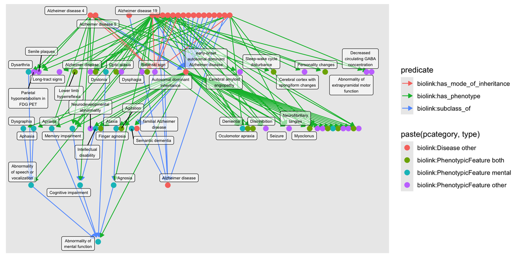

```r
ggraph(alz_phenos_labeled, layout = "sugiyama") +
        geom_edge_link(aes(color = predicate),
                                     arrow = arrow(length = unit(2, 'mm'), type = "closed"),
                                     end_cap = circle(2.5, 'mm')) +
        geom_node_point(aes(color = paste(pcategory, type)),
                                        size = 3) +
        geom_node_label(aes(label = str_wrap(name, 20)),
                                        size = 2,
                                        repel = TRUE,
                                        check_overlap = TRUE,
                                        fill = "#FFFFFF88")
```

And here’s a handy list of Alzheimers phenotypes, labeled with type as behavioral, mental, both, or other.

```r
#ggraph(behavioral_mental_alz_phenos, layout = "sugiyama") +

alz_phenos_labeled |>
    activate(nodes) |>
    filter(pcategory == "biolink:PhenotypicFeature") |>
    select(id, name, type, description) |>
    arrange(type)
```

#### Nodes

Showing 48 of 48 nodes:

| id | name | description | type |
| --- | --- | --- | --- |
| “HP:0006979” | “Sleep-wake cycle disturbance” | “Any abnormal alteration of an individual’s circadian rhythm that affects the timing of sleeping and being awake.” | “both” |
| “HP:0001336” | “Myoclonus” | “Very brief, involuntary random muscular contractions occurring at rest, in response to sensory stimuli, or accompanying voluntary movements.” | “both” |
| “HP:0001288” | “Gait disturbance” | “The term gait disturbance can refer to any disruption of the ability to walk. In general, this can refer to neurological diseases but also fractures or other sources of pain that is triggered upon wa… | “both” |
| “HP:0002395” | “Lower limb hyperreflexia” | NA | “both” |
| “HP:0000751” | “Personality changes” | “An abnormal shift in patterns of thinking, acting, or feeling.” | “both” |
| “HP:0003487” | “Babinski sign” | “Upturning of the big toe (and sometimes fanning of the other toes) in response to stimulation of the sole of the foot. If the Babinski sign is present it can indicate damage to the corticospinal trac… | “both” |
| “HP:0001332” | “Dystonia” | “An abnormally increased muscular tone that causes fixed abnormal postures. There is a slow, intermittent twisting motion that leads to exaggerated turning and posture of the extremities and trunk.” | “both” |
| “HP:0012433” | “Abnormal social behavior” | “An abnormality of actions or reactions of a person taking place during interactions with others.” | “both” |
| “HP:0000657” | “Oculomotor apraxia” | “Ocular motor apraxia is a deficiency in voluntary, horizontal, lateral, fast eye movements (saccades) with retention of slow pursuit movements. The inability to follow objects visually is often compe… | “both” |
| “HP:0001251” | “Ataxia” | “Cerebellar ataxia refers to ataxia due to dysfunction of the cerebellum. This causes a variety of elementary neurological deficits including asynergy (lack of coordination between muscles, limbs and … | “both” |
| “HP:0000738” | “Hallucinations” | “Perceptions in a conscious and awake state in the absence of external stimuli which have qualities of real perception, in that they are vivid, substantial, and located in external objective space.” | “both” |
| “HP:0000734” | “Disinhibition” | “Reduced ability to control, or a failure to resist a temptation, urge, or impulse. Examples include disregard for social conventions, general impulsivity, and poor risk assessment.” | “both” |
| “HP:0002463” | “Language impairment” | “Language impairment is a deficit in comprehension or production of language that includes reduced vocabulary, limited sentence structure, or impairments in written or spoken communication. Language a… | “both” |
| “HP:0000713” | “Agitation” | “A state of extreme restlessness and excessive motor activity is associated with mental distress or a feeling of inner tension.” | “both” |
| “HP:0000726” | “Dementia” | “A loss of global cognitive ability of sufficient amount to interfere with normal social or occupational function. Dementia represents a loss of previously present cognitive abilities, generally in ad… | “mental” |
| “HP:0002186” | “Apraxia” | “A defect in the understanding of complex motor commands and in the execution of certain learned movements, i.e., deficits in the cognitive components of learned movements.” | “mental” |
| “HP:0100543” | “Cognitive impairment” | “Abnormal cognition with deficits in thinking, reasoning, or remembering.” | “mental” |
| “HP:0002354” | “Memory impairment” | “An impairment of memory as manifested by a reduced ability to remember things such as dates and names, and increased forgetfulness.” | “mental” |
| “HP:0010524” | “Agnosia” | “Inability to recognize objects not because of sensory deficit but because of the inability to combine components of sensory impressions into a complete pattern. Thus, agnosia is a neurological condit… | “mental” |
| “HP:0001260” | “Dysarthria” | “Dysarthric speech is a general description referring to a neurological speech disorder characterized by poor articulation. Depending on the involved neurological structures, dysarthria may be further… | “mental” |
| “HP:0031868” | “Optic ataxia” | “Difficulty reaching to visually guided goals in peripheral vision, with the deficit leaves voluntary eye movements largely unaffected.” | “mental” |
| “HP:0010525” | “Finger agnosia” | “An inability or difficulty differentiating among the fingers of either hand as well as the hands of others.” | “mental” |
| “HP:0010526” | “Dysgraphia” | “A writing disability in the absence of motor or sensory deficits of the upper extremities, resulting in an impairment in the ability to write regardless of the ability to read and not due to intellec… | “mental” |
| “HP:0001289” | “Confusion” | “Lack of clarity and coherence of thought, perception, understanding, or action.” | “mental” |
| “HP:0001249” | “Intellectual disability” | “Subnormal intellectual functioning which originates during the developmental period. Intellectual disability, previously referred to as mental retardation, has been defined as an IQ score below 70.” | “mental” |
| “HP:0002381” | “Aphasia” | “An acquired language impairment of some or all of the abilities to produce or comprehend speech and to read or write.” | “mental” |
| “HP:0011446” | “Abnormality of mental function” | “Cognitive, psychiatric, or memory anomaly.” | “mental” |
| “HP:0030219” | “Semantic dementia” | “A progressive loss of the ability to remember the meaning of words, faces and objects.” | “mental” |
| “HP:0002167” | “Abnormality of speech or vocalization” | “Abnormalities in the sound of a person’s speech or vocalization not necessarily associated with a known physical cause or due to stuttering or stammering.” | “mental” |
| “HP:0002185” | “Neurofibrillary tangles” | “Pathological protein aggregates formed by hyperphosphorylation of a microtubule-associated protein known as tau, causing it to aggregate in an insoluble form.” | “other” |
| “HP:0410054” | “Decreased circulating GABA concentration” | “A decrease in the level of GABA in the serum.” | “other” |
| “HP:0001300” | “Parkinsonism” | “Characteristic neurologic anomaly resulting from degeneration of dopamine-generating cells in the substantia nigra, a region of the midbrain, characterized clinically by shaking, rigidity, slowness o… | “other” |
| “HP:0002423” | “Long-tract signs” | “Long-tract signs refer to symptoms that are attributable to the involvement of the long fiber tracts in the spinal cord, which connect the spinal cord to the brain and mediate spinal and motor functi… | “other” |
| “HP:0002511” | “Alzheimer disease” | “A degenerative disease of the brain characterized by the insidious onset of dementia. Impairment of memory, judgment, attention span, and problem solving skills are followed by severe apraxia and a g… | “other” |
| “HP:0000006” | “Autosomal dominant inheritance” | “A mode of inheritance that is observed for traits related to a gene encoded on one of the autosomes (i.e., the human chromosomes 1-22) in which a trait manifests in heterozygotes. In the context of m… | “other” |
| “HP:0100256” | “Senile plaques” | “Senile plaques are extracellular deposits of amyloid in the gray matter of the brain.” | “other” |
| “HP:0011970” | “Cerebral amyloid angiopathy” | “Amyloid deposition in the walls of leptomeningeal and cortical arteries, arterioles, and less often capillaries and veins of the central nervous system.” | “other” |
| “HP:0012662” | “Parietal hypometabolism in FDG PET” | “Reduced uptake of [18F]-fluorodeoxyglucose (FDG) in the parietal cortex as measured by positron emission tomography (PET) brain scan.” | “other” |
| “HP:0002071” | “Abnormality of extrapyramidal motor function” | “A neurological condition related to lesions of the basal ganglia leading to typical abnormalities including akinesia (inability to initiate changes in activity and perform volitional movements rapidl… | “other” |
| “HP:0002015” | “Dysphagia” | “Difficulty in swallowing.” | “other” |
| “HP:0002120” | “Cerebral cortical atrophy” | “Atrophy of the cortex of the cerebrum.” | “other” |
| “HP:0001250” | “Seizure” | “A seizure is an intermittent abnormality of nervous system physiology characterised by a transient occurrence of signs and/or symptoms due to abnormal excessive or synchronous neuronal activity in th… | “other” |
| “HP:0001285” | “Spastic tetraparesis” | “Spastic weakness affecting all four limbs.” | “other” |
| “HP:0003791” | “Deposits immunoreactive to beta-amyloid protein” | NA | “other” |
| “HP:0012759” | “Neurodevelopmental abnormality” | “A deviation from normal of the neurological development of a child, which may include any or all of the aspects of the development of personal, social, gross or fine motor, and cognitive abilities.” | “other” |
| “HP:0001276” | “Hypertonia” | “A condition in which there is increased muscle tone so that arms or legs, for example, are stiff and difficult to move.” | “other” |
| “HP:0000504” | “Abnormality of vision” | “Abnormality of eyesight (visual perception).” | “other” |
| “HP:0006790” | “Cerebral cortex with spongiform changes” | NA | “other” |